# A

# T

太公分猪肉，人人有份 tai3 gung1 fen1 ju1 yug6 ，yen4 yen4 yeo5 fen6-2 ——歇后语。旧时农村每逢清明或其他节日，要杀猪祭拜祖宗，然后把猪肉煮熟，按照惯例分给众子孙，凡是族中的男丁都有份。如：呢次加人工，太公分猪肉，人人有份（这次涨工资，人人有份）。

贪得意 tam1 deg1 yi3 ——对某事不是认真地对待，只是逢场作戏而已。如：你以为佢好中意整蛋糕食呀，贪得意咋（你以为他很喜欢做蛋糕吃吗，闹着玩罢了）。

贪威识食 tam1 wei1 xig1 xig6 ——贪威：爱漂亮；识食：懂得吃。形容人讲究享受、贪图虚荣。如：有啲人唔好好工作，成日顾住玩，贪威识食（有些人不好好工作，整天忙着玩儿，贪图享受）。

痰塞肺眼 tam4 seg1 fei3 ngan5 ——形容人糊里糊涂、懵懵懂懂，好像是被痰堵塞了肺中的气管一样。如：咁简单嘅问题都唔识，真系痰塞肺眼咯（这么简单的问题都不懂，真是糊涂了）。

叹世界 tan3 sei3 gai3 ——叹：享受；世界：生活、日子。如：你而家就好啦，退咗休又唔使做嘢，日日去饮茶，真够叹世界咯（你现在就好了，退了休不用上班，天天去“饮茶”，真够享福的）。

睇差一皮 tei2 ca1 yed1 péi4 ——睇：看；一皮：一个等级，一个层次。判断不够准确。如：呢个问题我睇差一皮喇（这个问题我判断得不够准确）。

睇得过眼 tei2 deg1 guo3 ngan5 ——看着感到过得去。形容事情做得还算不错。如：你写嘅字都睇得过眼（你写的字还算不错）| 后生仔做嘢你睇得过眼就算咯（年轻人做事你看得过去就算了）。

睇见眼冤 tei2 gin3 ngan5 yün1 ——睇：看。看见某事心里就不舒服、反感。如：你点搞到成身咁邋遢，真系睇见眼冤咯（你怎么弄得全身这么肮脏，看见就叫人讨厌啊）。

睇起上嚟 tei2 héi2 sêng5 lei4 ——看起来，看上去。如：你睇起上嚟重系好后生，唔似五十岁噃（你看上去还是很年轻，不像五十岁嘛）| 个天睇起上嚟要落雨喇（天看起来要下雨了）。又叫“睇起嚟”。

睇戏睇全套，食嘢食味道 tei2 héi3 tei2 qun4 tou3 ，xig6 yé5 xig6 méi6 dou6 ——谚语。睇戏：看戏；食嘢：吃东西。看戏要从头到尾地看才有意思，而吃东西主要是吃东西的味道，不能囫囵吞枣地吃。

睇住嚟 tei2 ju6 lei4 ——警告别人时用，有“等着瞧”的意思。如：你唔恶得几日喇，睇住嚟啦（你凶不了几天了，等着瞧吧）。另外，请人注意时用，有“当心”“小心”等意思。如：滚水呀，睇住嚟（开水，当心）！| 上面有危险，睇住嚟（上面有危险，注意）！

睇嚟凑 tei2 lei4 ceo3 ——看着办，看具体情况再决定怎么办。如：畀几多都得，你睇嚟凑啦（给多少都可以，你看着办吧）| 你话点处理佢好呀，睇嚟凑啦（你说怎样处理好呢，看着办吧）| 以后去唔去都未决定，睇嚟凑啦（以后去不去还没决定，看着办吧）。

睇死 tei2 séi2 ——看透，看扁（指对人持否定态度）。如：我早就睇死佢咯，佢边度会改吖（我早就看扁他了，他怎么会改过呢）| 你唔好睇死人哋，或者佢会做都唔定（你不要看不起他，也许他会做呢）。

睇衰 tei2 sêu1 ——看不起，蔑视，小看。如：唔系我睇衰你，其实系你自己睇唔起自己之吗（不是我看不起你，其实是你自己看不起自己罢了）。

睇水 tei2 sêu2 ——望风，放风，把风。如：嗰啲贼仔偷嘢都有人睇水嘅（ 那些小偷偷东西时都有人给望风的）。

睇数 tei2 sou3 ——结账，埋单。如：呢度饮茶食完至睇数（这里饮茶吃完了再结账）| 你哋使咗几多通通由我嚟睇数（你们花了多少钱统统由我来埋单）。

睇餸食饭 tei2 sung3 xig6 fan6 ——餸：菜肴。看着菜吃饭。比喻看情况如何因势量力行事，量入为出。如：做几大间屋你要根据自己嘅能力先得，睇餸食饭好紧要呀（盖多大的房子要根据自己的能力才行，量力行事很重要）| 你一个月使几多钱要睇你嘅工资有几多，睇餸食饭至得呀（你一个月花多少钱要看你的工资有多少，量入为出才行啊）。

睇色水 tei2 xig1 sêu2 ——看形势。如：我睇色水好似有人注意你喇（我看形势好像有人在注意你了）。

睇准起筷 tei2 zên2 héi2 fai3 ——直译是看准了再动筷子。比喻为看准形势抓住时机再行事。如：你唔好乱嚟，要睇准起筷呀（你不要乱来，要看准时机才能行动）。

剃头佬教仔，有得刮就刮 tei3 teo4 lou2 gao3 zei2 ，yeo5 deg1 guad3 zeo6 guad3 ——歇后语。剃头佬：理发师；刮：剃。“刮”是双关语，另一个意思是搜刮、贪污的意思。多用于指贪官想尽办法搜刮民财，能贪就贪。

剃头佬走警报，懒刮 tei3 teo4 lou2 zeo2 ging2 bou3 ，lan5 guad3 ——歇后语。懒刮：懒得剃，另一个意思是不愿意干。抗战时日本飞机来轰炸，警报一响，为了逃命，连理发师也顾不得做生意了。多用于表示不愿意干某事。这说法比较粗俗，一般人少用。

剃头唔湿水，干刮 tei3 teo4 m4 seb1 sêu2 ，gon1 guad3 ——歇后语。唔：不；刮：搜刮；干刮：强硬地刮，或白白地让别人搜刮。比喻贪官强夺民财。也比喻让人取去利益而得不到补偿。

鬼食豆腐 tem3 guei2 xig6 deo6 fu6 —— ：骗。广东民俗，每年农历七月十四为“鬼节”，人们在家门前摆设酒饭果品，点香烛焚烧纸钱、纸衣等，祭奠野鬼游魂，俗叫“烧衣”。后来有的人为了省钱，只用果品和豆腐代替酒饭。人们用这话来比喻某人只说得好听，但没有什么实际内容，只不过是骗人而已。如：你信佢吖， 鬼食豆腐咋（你信他，骗人的）！又叫“呃鬼食豆腐”。

听出耳油 téng1 cêd1 yi6 yeo4 ——形容音乐、歌曲等十分动听。如：你呢首小夜曲我都听出耳油咯（你的这支小夜曲叫我听得着迷了）。

听价唔听斗 téng1 ga3 m4 téng1 deo2 ——唔：不；斗：过去量粮食的器具；唔听斗：比喻买东西时没有注意东西的规格。整个意思是只注意商品的价钱而没注意其规格与分量。如：有啲人去买嘢净系贪平，唔注意分量，听价唔听斗，结果上晒当咯（有人买东西光看价钱便宜，忽视分量，结果上当了）。

听讲话 téng1 gong2 wa6 ——听说，据说。如：听讲话你要出国喇，系吗（听说你要出国了，是吗）？| 听讲话今年要增加工资喎，系真嘅吗（据说今年要增加工资呢，是真的吗）？

听过隔篱 téng1 guo3 gag3 léi4 ——隔篱：隔壁。听错了。如：一唔注意就听过隔篱（一不小心就听错了）| 话明你知喇，唔好听过隔篱呀（告诉你了，别听错了）。

偷风莫偷雨 teo1 fung1 mog6 teo1 yü5 ——谚语。刮风的时候小偷往往出来行窃，但下雨的时候小偷则不愿意出来偷东西。这是因为刮风的时候，房子的主人听到什么响声以为是刮风所致，但下雨天晚上主人担心屋漏，睡得不安稳，这时如果小偷来行窃，很容易被主人发觉。用于提醒人们在刮风的夜晚要倍加小心，防止有小偷来行窃。

偷鸡唔到蚀把米 teo1 gei1 m4 dou3-2 xid6 ba2 mei5 ——唔：不。小偷偷鸡，偷鸡不着反而损失了用来诱鸡的一把米。比喻想占点便宜，结果便宜占不到反而受到损失。如：呢条友仔想话唔买票，结果畀人查出，重罚咗十文添，真系偷鸡唔到蚀把米咯（这个家伙打算不买票，结果被查出来，还罚了十块钱，真是便宜没占到还受损失啊）。

偷食唔会挢嘴 teo1 xig6 m4 wui5 giu2 zêu2 ——挢：拭擦。偷吃了东西却不会把嘴巴拭擦干净，让别人发现自己的作为。一般用来讥笑那些做了错事又不小心留下痕迹的做法。

头崩额裂 teo4 beng1 ngag6 lid6 ——头破血流，焦头烂额。形容人遇到严重挫折，如：如果你乱嚟，肯定要碰到头崩额裂（如果你要蛮干，肯定要碰得头破血流）| 呢单嘢搞到我头崩额裂（这件事弄得我焦头烂额）。

头大冇脑 teo4 dai6 mou5 nou5 ——冇：没有。头虽然大但没有脑。比喻人没有头脑，办事不经过大脑。如：你做事唔想清楚，头大冇脑有乜用呢（你做事没想清楚，没有头脑，有什么用）！

头耷耷，眼湿湿 teo4 deb1 deb1 ，ngan5 seb1 seb1 ——头耷耷：头垂下来，垂头丧气；眼湿湿：眼睛湿润，要哭的样子。形容人垂头丧气、伤心欲哭的样子。如：佢畀老师批评到头耷耷，眼湿湿噉（他被老师批评得垂头丧气，快要哭了）。

头头掂掂 teo4 teo4 dim6 dim6 ——头掂：清楚、顺畅。是有条有理、井井有条等意思。如：原来系一个落后嘅单位，佢几个月就搞得头头掂掂（原来是一个落后单位，他几个月就弄得井井有条）。

头头碰着黑 teo4 teo4 pung3 zêg6 heg1 ——形容人运气极差，到处碰壁，事事不顺心。如：呢次真系头头碰着黑咯，冇样掂（这次真是倒霉透了，到处碰壁，没有一样事是顺利的）。

头肿眼膇 teo4 zung2 ngan5 dêu3 ——膇：轻微的肿。指脸面浮肿。如：今日睇你头肿眼膇做乜呀（今天看你脸面浮肿，怎么啦）？

贴错门神 tib3 co3 mun4 sen4 ——门神像应是左右相向，如果贴错了就变成背对着背。比喻两人闹别扭，互不理睬。如：佢两个嗌咗交，呢几日面左左，好似贴错门神噉（他们两个吵过架，这几天都绷着脸，谁也不理谁）。

贴钱买难受 tib3 qin4 mai5 nan6 seo6 ——花钱买罪受。戏指花了钱却得不到享受，反而受苦受累或受气。如：旅游咁辛苦，我就唔去咯，费事贴钱买难受呀（旅游这么辛苦，我就不去了，免得花钱买罪受）。

贴身膏药 tib3 sen1 gou1 yêg6 ——整天贴在身上的膏药。比喻整天紧跟着别人或死缠着别人的人。如：你唔好成日跟住我，好似我嘅贴身膏药噉（你不要整天跟着我，就像一只跟屁狗一样）。

铁拐李打足球，一脚踢 tid3 guai2 léi5 da2 zug1 keo4 ，yed1 gêg3 tég3 ——歇后语。铁拐李：八仙之一，跛腿；一脚踢：各种事务全部由一人包揽。如：呢度各样工作我要铁拐李打足球，一脚踢（这里的工作全部由我一人包揽）。

铁木真打仔，大汗 细汗 tid3 mug6 zen1 da2 zei2 ，dai6 hon6 deb6 sei3 hon6 ——歇后语。铁木真：即元太祖，他于 1206 年统一蒙古诸部后被推为大汗，称成吉思汗；仔：儿子； ：捶打，这里谐音“沓”，重叠﹑摞起的意思；细汗：细小的汗珠，这里戏称“大汗的儿子”。铁木真打儿子，就是大汗捶打细汗。指大汗珠叠着小汗珠，即大汗淋漓。如：今日日头咁大去种树，个个做到铁木真打仔，大汗 细汗（今天太阳这么猛烈去种树，个个干得大汗淋漓）。

铁沙梨，咬唔入 tid3 sa1 léi4-2 ，ngao5 m4 yeb6 ——歇后语。同“青砖沙梨，咬唔入”。

铁嘴鸡，牙尖嘴利 tid3 zêu2 gei1 ，nga4 jim1 zêu2 léi6 ——歇后语。形容人尖嘴薄舌，能说会道，含贬义。如：呢个人好会狡辩，人人都话佢铁嘴鸡，牙尖嘴利（这个人很会狡辩，谁都说他尖嘴薄舌）。

天跌落嚟当被 tin1 did3 log6 lei4 dong3 péi5 kem2 ——跌落嚟：掉下来； ：盖，覆盖。天塌下来当被子盖。指多大的困难也不怕，多严重的后果也敢于承担。如：你放胆去做啦，我负责，天跌落嚟当被 （你放心去干吧，我负责，天塌下来当被子盖）。

天脚底 tin1 gêg3 dei2 ——天边，天涯地角，笼统指很远的地方。如：佢住喺天脚底咁远，边度揾得到佢吖（他住在天涯地角那么远，哪里能找得到他呢）。

天光大白 tin1 guong1 dai6 bag6 ——天大亮，光天化日。如：一觉瞓到天光大白（一觉睡到天大亮）| 你居然天光大白就喺度抢嘢（你居然光天化日之下就在这里抢东西）！

天光圩 tin1 guong1 hêu1 ——天亮以前的农贸集市，过去在珠江三角洲的农村多见。

天起鱼鳞斑，食过饭上山 tin1 héi2 yü4 lên4 ban1 ，xig6 guo3 fan6 sêng5 san1 ——农谚。天上有鱼鳞一样的云彩，是天晴的征候，可以吃过饭上山干活去。

天开眼 tin1 hoi1 ngan5 ——老天有眼。如：呢个坏人终于畀法院判咗刑，真系天开眼咯（那个坏人终于被判了刑，真是老天有眼了）。

天开眼，煮粥煮成饭 tin1 hoi1 ngan5 ，ju2 zug1 ju2 xing4 fan6 ——谐谑语。即老天有眼保佑我们这些穷人，煮粥居然变成米饭了。比喻结果比预想要好得多。

天无绝人之路 tin1 mou4 jud6 yen4 ji1 lou6 ——虽然身处绝境，但是只要千方百计想办法总会有出路的。多用来劝慰一时遇到困难的人，不要被困难吓倒，要尽最大的努力。如：你唔使惊，一定有办法嘅，天无绝人之路啦吗（你不必害怕，一定是有办法的，车到山前必有路嘛）。

天生天养 tin1 sang1 tin1 yêng5 ——生下来的人或其他生物必然有办法生存下去。如：你唔使惊，生到个仔就有办法养，天生天养嘛（你不必担忧，孩子能生下来就有办法活下去，天生天养嘛）。

天上雷公，地上舅公 tin1 sêng6 lêu4 gung1 ，déi6 sêng6 keo5 gung1 ——谚语。舅公：舅爷爷，即父亲的舅父。旧时广东民间认为舅父、舅公在家里的地位很高，权力很大，其威严可以与天上的雷公相比。这可能与百越地区古代民族的习俗有关。

天堂尿壶，全神灌（贯）注 tin1 tong4 niu6 wu4 ，qun4 sen4 gun3 ju3 ——歇后语。全神：全体天神，双关指全副精神。“灌注”谐音“贯注”。指高度集中注意力。如：佢正喺度研究资料，天堂尿壶，全神灌（贯）注呢（他正在集中全副精神研究资料呐）。

天时暑热 tin1 xi4 xu2 yid6 ——天气炎热。如：南方唔同北方，天时暑热要注意饮凉茶呀（南方跟北方不同，天气炎热要注意喝些清凉饮料啊）。

天然白虎汤 tin1 yin4 bag6 fu2 tong1 ——白虎汤：一种清热泻火的中药方剂。戏称西瓜。如：夏天有天然白虎汤食就唔怕热喇（夏天有西瓜吃就不怕热了）。

田鸡东，蛤（夹）东 tin4 gei1 dung1 ，gab3 dung1 ——歇后语。田鸡：青蛙，广州话又叫“蛤乸”，简称“蛤”。“田鸡东”即“蛤东”，其同音词是“夹东”（或“合东”），意思是大家共同做东、共同出钱吃饭或其他消费，现在叫 AA 制。如：我哋而家食饭兴田鸡东蛤东喇（我们现在吃饭流行 AA 制了）。

田鸡过河，各有各□ tin4 gei1 guo3 ho4 ，gog3 yeo5 gog3 yang3 ——歇后语。□（yang3 ）：蹬，引申指走开。各人只顾自己走路。如：毕业喇，大家就田鸡过河，各有各□（毕业了，大家就各走各的路）（原文为□）。

田螺唔知自身曲 tin4 lo4-2 m4 ji1 ji6 sen1 kug1 ——谚语。田螺：螺蛳。螺蛳的壳是弯曲的，它不知道自己的身也是弯曲的。比喻人对自己的缺点毛病往往不自觉。如：我嘅缺点请唔好客气噉指出，田螺唔知自身曲嘛（我的缺点请不客气地指出，人对自己的毛病是不自觉的）。

田螺爬上旗杆顶，唯我独尊 tin4 lo4-2 pa4 sêng5 kéi4 gon1 déng2 ，wei4 ngo5 dug6 jun1 ——歇后语。田螺爬上最高的旗杆顶，觉得它是最高的了。比喻有些人觉得自己是最了不起的人。如：你唔好以为啱啱升咗官就好了不得，田螺爬上旗杆顶，唯我独尊（你不要以为刚刚升了官就很了不起，唯我独尊）。

田禾初亮花，切莫捉青蛙 tin4 wo4 co1 lêng6 fa1 ，qid3 mog6 zug1 qing1 wa1 ——农谚。田里的水稻刚刚抽穗扬花的时候，切莫下田捉青蛙。因为这时害虫容易生长，更需要青蛙去捉虫。

田要深耕，地要浅种 tin4 yiu3 sem1 gang1 ，déi6 yiu3 qin2 zung3 ——农谚。犁水田要犁得深，在旱地上种农作物要种得浅。

挑通眼眉 tiu1 tung1 ngan5 méi4 ——挑：雕刻，抠。形容人非常精明，连眉毛也能抠得通。老年人多用。

跳楼货 tiu3 leo4 fo3 ——指货物的价格低于成本，商家卖了就要亏本甚至破产，可能因此而跳楼。这是商家危言耸听的广告用语。

条气唔顺 tiu4 héi3 m4 sên6 ——气不顺，指遭遇到不平的事而引起的憋气，即“气不过”“不服气”等。如：睇见佢喺度乱虾人，我条气就唔顺（看见他在随意欺负人，我的气就不打一处来）| 无端端畀老板闹咗一餐，梗系条气唔顺啦（无缘无故被老板骂了一顿，当然是气不顺啦）。

陀陀拧 to4 to4 ning6 ——团团转。多用来形容人忙乱的样子。如：今日顾客多，忙到佢陀陀拧（今天顾客多，忙得他团团转）。

驼背夹直 to4 bui3 gab3 jig6 ——指硬要把驼背夹直，比喻强迫人做为难的事。如：我实在唔识唱歌，你硬系要我唱，等于将我驼背夹直嗻（我实在不会唱歌，你非要我唱，这不是赶鸭子上架吗）。

托大脚 tog3 dai6 gêg3 ——拍马屁。如：你噉做好似有托大脚嘅嫌疑噃（你这样做似乎有拍马屁的嫌疑呐）。

托手踭 tog3 seo2 zang1 ——手踭：肘儿。指有意妨碍或阻挠别人做事。相当于“掣肘”。如：你唔会托手踭啩（你不会阻挠我吧）？也指拒绝别人的请求。如：你开口佢唔会托手踭嘅（你开口他不会拒绝的）。

托塔都应承 tog3 tab3 dou1 ying1 xing4 ——托塔：扛马桶。表示决心大，无论干什么也敢答应。如：你畀我参加嘅话，你叫我做乜嘢都得，托塔都应承呀（你让我参加的话你叫我干什么都行）。

台台凳凳 toi4 toi4 deng3 deng3 ——桌椅板凳。如：搬家最麻烦就系嗰啲台台凳凳喇（搬家最麻烦的就是那些桌椅板凳了）。

抬棺材甩裤，失礼死人 toi4 gun1 coi4 led1 fu3 ，sed1 lei5 séi2 yen4 ——歇后语。甩裤：掉了裤子。“失礼死人”是双关语，既指对死者失礼，也指对人太失礼了。如：咁多人客都未埋位你就猛咁食，真系抬棺材甩裤，失礼死人喇（那么多的客人都还没有入席你就拼命地吃，太失礼了）。

汤丸（圆）命，一浮头就畀人食 tong1 yün4-2 méng6 ，yed1 pou4 teo4 zeo6 béi2 yen4 xig6 ——歇后语。汤丸：汤圆，即元宵；浮头：浮起来；畀：给，让；食：吃。元宵煮熟即浮上汤面，人们就把它吃了。比喻谁一出头就遭人打击。相当于“枪打出头鸟”。“浮”读 pou4 是口语音。

劏白鹤 tong1 bag6 hog6 ——劏：宰杀。戏指因醉酒而呕吐。如：琴晚佢饮得多，又劏白鹤喇（昨晚他喝得多，又吐得很厉害）。

劏光猪 tong1 guong1 ju1 ——指下象棋时，棋子除“将”、“帅”以外，被对方全部吃光。

劏猪凳，上亲就死 tong1 ju1 deng3 ，sêng5 cen1 zeo6 séi2 ——歇后语。用来杀猪的凳子，哪一只猪上去就意味着死亡。这是旧社会对所谓“克夫”的女人的侮辱性说法。

劏死牛 tong1 séi2 ngeo4 ——拦路抢劫。如：夜晚呢度时时都有人喺度劏死牛（晚上这里经常有人在这里拦路抢劫）。

塘底石，水干先见 tong4 dei2 ség6 ，sêu2 gon1 xin1 gin3 ——歇后语。塘：水塘；水：兼指钱；先见：才见得到。水塘底的石头要等到水都干了才看得见。比喻人平时见不到他，到没有钱的时候才出现（一般是来借钱）。如：呢条友正一塘底石，水干先见（这家伙平时总看不到他，可到了没有钱的时候他就来了）。

螗 满天飞，风雨一齐嚟 tong4 méi1 mun5 tin1 féi1 ，fung1 yü5 yed1 cei4 lei4 ——农谚。螗 ：蜻蜓；嚟：来。蜻蜓满天飞，预兆风雨即将来临。

螗 咬尾，自己食自己 tong4 méi1 ngao5 méi5 ，ji6 géi2-1 xig6 ji6 géi2-1 ——歇后语。螗 ：蜻蜓。蜻蜓咬尾巴，好像是自己吃自己（其实是在交配）。指自己负责自己的伙食，或指依靠自己的力量去解决问题。如：我哋大家做生意，住埋一齐，但系螗 咬尾，自己食自己（我们大家做生意，住在一起，但是自己管自己的伙食）。

糖黐豆 tong4 qi1 deo6-2 ——黐：粘。糖跟豆粘在一起就很难分得开，形容两个人非常要好，形影不离。如：佢两个好到糖黐豆噉，成日都唔分开（他们两个好得要命，好像糖粘上了豆子，整天形影不离）。

土地灯笼，夜不收 tou2 déi6-2 deng1 lung4 ，yé6 bed1 seo1 ——歇后语。土地：土地神。旧时民俗每逢初一、十五祭拜土地神时，晚间要点挂灯笼，天亮以后才收。比喻那些沉迷于夜生活，喜好晚上活动，彻夜不归的人。如：佢系土地灯笼，夜不收，天光至翻屋企（他是个夜晚活动的人，天亮才回家）。

断柄锄头，冇揸拿 tün5 béng3 co4 teo4 ，mou5 za1 na4 ——歇后语。冇揸拿：没有把握。如：呢件事我好似断柄锄头，冇揸拿噃（这件事我可没有把握啊）。

断线纸鹞，无牵无挂 tün5 xin3 ji2 yiu6-2 ，mou4 hin1 mou4 gua3 ——歇后语。纸鹞：风筝。断了线的风筝，就没有人牵着它了。比喻不用挂念任何人。如：佢而家仔女都大晒咯，两公婆日日都去玩，断线纸鹞，无牵无挂咯（他现在子女都长大了，老两口每天都出去玩，没有什么牵挂了）。

断线三弦，冇得弹 tün5 xin3 sam1 yün4 ，mou5 deg1 tan4 ——歇后语。三弦：一种三弦琴；冇得弹：没有办法弹。断了弦的三弦琴就没办法弹了。广州话的“弹”另外有批评、指责等意思。“冇得弹”是指对别人的服务、态度等都很满意，没有什么意见的意思。如：你哋个个都做得咁好，断线三弦，冇得弹咯（你们每人都做得这么好，没什么可说的）。

通天老倌，样样皆能 tung1 tin1 lou5 gun1 ，yêng6 yêng6 gai1 neng4 ——歇后语。老倌：旧时指戏曲演员。演技精良的演员演什么角色都行。一般用来赞扬人能力强，很多方面的事都能干，就像优秀演员什么角色都能演那样。如：房屋装修方面，佢系通天老倌，样样皆能（房屋装修方面，他是个多面手，什么活儿都能干）。

同行如敌国 tung4 hong4 yü4 dig6 guog3 ——形容同一行业的人相互间你死我活的激烈竞争。如：同行都要协作，如果重系同行如敌国噉，点可以维护大家嘅利益呢（同行也要协作，如果还是相互像敌人那样，怎么来维护大家的共同利益啊）。

同捞同煲 tung4 lou1 tung4 bou1 ——同捞：共同谋生；同煲：一块儿吃饭。指几个人在一起谋生，一起生活，患难与共，亲如兄弟。如：我哋做生意嗰阵，大家唔分大细，同捞同煲（我们做生意的时候，大家不分大小，一块儿干一块儿吃）。

同台食饭，各自修行 tung4 toi4 xig6 fan6 ，gog3 ji6 seo1 heng4 ——谚语。虽然大家同在一张桌子上吃饭，但各人修行要靠自己去做。比喻谁将来情况如何，要靠自己的努力。如：同台食饭，各自修行，自己唔努力，肯定落后过人哋（同时受教益的人还是要靠各自修行的，自己不努力，肯定会比人家落后）。

同人唔同命，同遮唔同柄 tung4 yen4 m4 tung4 méng6 ，tung4 zé1 m4 tung4 béng3 ——谚语。唔：不；遮：伞。都是人却各有各的命运；同是雨伞但伞把儿却不一样。多用作感叹人的运气遭遇各不相同。如：世界乜人都有，同人唔同命，同遮唔同柄（世界上什么人都有，都是人但各人的命运却不相同）。

同窑嘅缸瓦，一路货色 tung4 yiu4 gé3 gong1 nga5 ，yed1 lou6 fo3 xig1 ——歇后语。嘅：的。同一窑烧出来的缸瓦，质量差不多。比喻各人都是一样的货色，一丘之貉。如：我睇你哋都系同窑嘅缸瓦，一路货色（我看你们都是一丘之貉）。

桐油罐装桐油 tung4 yeo4 gun3 zong1 tung4 yeo4 ——桐油罐只能装桐油，不能装其他东西。比喻人的兴趣、技能一般不容易改变，也比喻人的本性难移。如：你读过师范，而家翻嚟呢度重系做翻教师好，桐油罐装桐油吗（你读过师范，现在回来这里还是当老师好，这是自然而然的）| 呢个嘢旧年时时打交，今年话改好咗咯，呢排又打伤人喇，真系桐油罐装桐油咯（这个家伙去年经常打架，今年说是改好了，可最近又打伤人了，真是本性难移了）。

铜板切豆腐，两面光 tung4 ban2 qid3 deo6 fu6 ，lêng5 min6 guong1 ——歇后语。铜板：指专门用来切豆腐的铜片；两面光：两面都光滑。形容人两面讨好、爱耍滑头。如：你边个都唔得罪，铜板切豆腐，两面光（你谁也不得罪，两面都过得去）。

铜银买病猪，两家偷欢喜 tung4 ngen4-2 mai5 béng6 ju1 ，lêng5 ga1 teo1 fun1 héi2 ——歇后语。铜银：假的银圆；两家：双方。用假银币买病猪，买的和卖的双方都以为占了便宜，偷着高兴。其实彼此彼此，谁也没有占到便宜。如：你哋两个都系大泡和，居然铜银买病猪，两家偷欢喜添（你们两个都是大傻瓜，以为占了对方的便宜，还偷着乐呐）。

# W

话得埋 wa6 deg1 mai4 ——（对事情）可以预料，说得准。多用于否定句或反诘句。如：呢种事话得埋嘅咩（这种事怎能预料得了呢）？| 呢啲嘢边个都唔话得埋（这些事谁也说不准）| 好难话得埋嘅（这很难肯定）。

话咁易 wa6 gem3 yi6 ——咁：那么。像说话那么容易。形容事情非常简单容易办理，不费吹灰之力。如：要佢表演节目，话咁易啦（要他表演节目，太容易啦）。

话口未完 wa6 heo2 méi6 yün4 ——话音未落。指说话间事情随即发生，或动作随即进行。如：你写得真快，话口未完就写好咯（你写得真快，话音刚落就写好了）。

话之佢 wa6 ji1 kêu5 ——话：原意是“告诉”。表明说话人对某事采取不管的态度。相当于“管他那么多”。如：话之佢呀，赚又好，蚀又好，我都唔理呀（管他呢，赚也好，赔也好，我一概不管）| 边个搞烂边个赔，话之佢呀（谁弄坏了谁赔，我不管那么多）。如果指的是对方，则说成“话之你”。

话落 wa6 log6 ——交代下来，事先告诉。如：老板出去前有冇话落啲乜嘢呀（老板出去前有没有交代些什么）？| 你要定房，话落畀经理知未呀（你要定房间，事先告诉经理了没有）？

话唔定 wa6 m4 ding6 ——唔：不。说不定，普通话口语常用“没准儿”。如：呢件事话唔定有啲声气噃（这件事说不定有点希望啊）| 听日话唔定要落雨咯（明天没准儿要下雨呢）。

话唔埋 wa6 m4 mai4 ——难以预料，难以预测。如：两个队实力都差唔多，边个赢就话唔埋喇（两个队实力都差不多，谁赢就难以预料了）。也指说不定。如：话唔埋佢唔肯去呢（说不定他不愿意去呢）︱以后会点就话唔埋咯（以后会怎么样就说不定了）。

话明你知 wa6 ming4 néi5 ji1 ——明白告诉你。如：话明你知，我系唔会同意嘅（明白告诉你吧，我是不会同意的）。

话冇咁快 wa6 mou5 gem3 fai3 ——冇：没有。说话都没那么快。指事情发生极快，连说话也赶不上事情的发生。但实际上不一定有人在说话，只强调其迅速。与普通话的“说时迟，那时快”近似。如：佢话都冇咁快就食完喇（他很快就吃完了）。

话晒都系 wa6 sai3 dou1 hei6 ——不管怎么说，毕竟是；终归是。如：佢有缺点，不过话晒都系班长，你要尊重佢至得（他尽管有缺点，不过毕竟是班长，你要尊重他才行）| 你话晒都系佢嘅大佬呀，要话下佢至得（你毕竟是他的哥哥，要说说他才行）。

话头醒尾 wa6 teo4 xing2 méi5 ——形容人聪明、机灵，善解人意，只要提一下他就醒悟对方的用意。如：呢个人好叻，话头醒尾，唔使你详细交带嘅（这个人很机灵，你稍一提醒他就能够领会意图，不用你详细交代）。

话事偈 wa6 xi6 gei2 ——正如某某所说。通过引用别人的话来印证自己的观点。如：亚强话事偈，同人哋合作好难嘅 （正如小强所说，跟人家合作是很难的）。

话嗻 wa6 zé1 ——嗻：语气词。不完全同意对方的看法，有“话虽如此，但…”和“可以这么认为”的意思。常用在句的开头或前一分句的句末。如：话嗻，重系稳阵啲好（话虽如此，但还是稳妥一点好）| 一百文就话嗻，几毫子算乜嘢吖（一百块钱还可以说，几毛钱还算什么）| 接待三几个人就话嗻，咁多人就算咯 （接待三几个人还可以，这么多人就算了吧）。

挖肉补疮 wad3 yug6 bou2 cong1 ——把好的肉挖出来，拿来补因长了疮而溃烂的地方。比喻人做了错事或蠢事，为了弥补损失而花去更多的人力物力，结果弄巧成拙，因小失大。

挖肉攞疮生 wad3 yug6 lo2 cong1 sang1 ——把肉割破让它长疮。比喻无事找事，自找麻烦，自讨苦吃。如：原嚟度门咁好畀佢拆鬼咗整成噉样，真系挖肉攞疮生咯（原来这扇门那么好让他拆了弄成这个样子，真是无事找事）。

画花口面 wag6 fa1 heo2 min6 ——把容貌涂脏，转指损毁形象，多指在背后散布流言蜚语贬损别人的声誉。如：你一下畀人画花口面，点讲都讲唔清咯（你一旦被人损毁了形象，怎么说也说不清了）。

画公仔画出肠 wag6 gung1 zei2 wag6 cêd1 cêng4 ——公仔：画中人。画画时把人物的内脏也画出来，比喻说话过于露骨，把不必要说的也说出来。如：你简单讲一下就得嘞，唔使画公仔画出肠噉（你简单说一下就可以了，不必过于详细）| 你呢个人噉都唔明，系唔系要我画公仔画出肠你至明呀（你这个人这样还不懂，是不是要我把全部都说出来才懂）？

画坏钟馗 wag6 wai6 zung1 kuei4 ——传说中驱鬼的钟馗相貌很丑陋，画坏了的钟馗就更加丑陋。形容人的相貌极端丑陋难看。如：呢个嘢肉酸到成个画坏钟馗噉（这个家伙比钟馗还丑）。

画耳上墙 wag6 yi5 sêng5 cêng4 ——把耳朵画到墙上去，形容人无心倾听或听而不闻。如：唔理你讲乜，佢一于画耳上墙（不管你说什么，他就是充耳不闻）。

歪嘴吹喇叭，一股斜（邪）气 wai1 zêu2 cêu1 la3 ba1 ，yed1 gu2 cé4 héi3 ——歇后语。“斜气”是双关语，其一是歪风邪气；其二是斜着吹来的气。歪着嘴吹喇叭，吹出一股斜气。广州话“斜”与“邪”同音。吹斜气成了吹邪气。如：用公款大吃大喝系歪嘴吹喇叭，一股斜气（用公款大吃大喝是一股歪风邪气）。

坏到加零一 wai6 dou3 ga1 ling4 yed1 ——比最坏还要加一等。指非常坏，坏透了。如：呢个人坏到加零一，冇得救喇（这个人坏透了，没法挽救了）。

坏鬼书生多别字 wai6 gui2 xu1 sang1 do1 bid6 ji6 ——谚语。坏鬼：不好的；别字：别号。名称多的人总有点古怪。多用来形容行为古怪的人和古怪的做法。

玩出火 wan2 cêd1 fo2 ——以不严肃、不负责的态度对待工作，以至惹了麻烦。如：你哋咁搞法会玩出火（你们这样搞会惹出麻烦的）| 你噉做唔怕玩出火呀（你这样做不怕出问题吗）？

还神 wan4 sen4 ——还愿。指迷信的人在困苦时求神保佑并许下了愿，如愿后即对神酬谢。如：佢病好咗即刻去还神（他病好了马上去还愿）。

横财就手 wang4 coi4 zeo6 seo2 ——就手：顺手。不费太大的气力就得到意外之财，多用作客套语。有恭喜发财的意思。

横街窄巷 wang4 gai1 zag3 hong6 ——小街小巷或城镇中偏僻的地方。如：你间店开喺横街窄巷度，边个知到你吖（你的店开在小胡同里，谁知道你啊）。

横九掂十 wang4 geo2 dim6 seb6 ——掂：直的意思。横是九，直是十，二者都差不多。意思是不管怎么处理都一样，随他去吧。如：你点搞都一样，横九掂十，我唔理咁多咯（你怎么搞也差不了多少，我管不了那么多了）。又有无论如何、不管用什么办法的意思。如：你横九掂十都要同我搞好佢（你无论如何都要给我弄好）。

横水艔 wang4 sêu2 dou6-2 ——艔：客船，是过去珠江水域的主要交通工具。“横水艔”指载客过河的渡船。如：“一个钱一个宝，冇钱唔过得横水艔”（俗语。意为没有钱连收费很便宜的渡船也坐不了）。

屈尾十 wed1 méi5 seb6 ——屈：弯曲。十字的第二笔来一个拐弯，形容人走了之后又拐回来了。如：佢走咗冇几耐，一个屈尾十又翻嚟咯（他走了没多久，兜了一个圈子又回来了）。

为得过 wei4 deg1 guo3 ——为：计算成本。划得来，合算。如：做呢单生意为得过（做这笔生意划得来）。又叫“有数为”。

为老不尊，教坏子孙 wei4 lou5 bed1 jun1 ，gao3 wai6 ji2 xun1 ——老人不自尊自重，行为不端，就会用自身的坏榜样教坏子孙。如：喺细路仔面前讲呢啲咸湿嘢，为老不尊，教坏子孙 （在小孩子面前说这些下流话，作为长辈不自重，会教坏子孙的）。

为唔过 wei4 m4 guo3 ——是“为得过”的否定说法。又叫“冇数为”。

卫生麻雀 wei6 sang1 ma4 zêg3 ——麻雀：麻将。打麻将时人们不计较输赢或输赢钱额不大的做法。如：你哋唔好赌钱呀，玩下卫生麻雀就冇问题（你们不要赌钱，随便玩玩，不算钱就没问题）。

为口奔驰 wei6 heo2 ben1 qi4 ——为了生活而劳碌奔波。这种说法比较文雅，通俗的说法是“为两餐频扑”。如：我成日咁忙都系为口奔驰咋（我整天这么忙无非是为了生活罢了）。

为食猫 wei6 xig6 mao1 ——馋猫。比喻馋嘴的人，多指孩子。如：听讲有得食，为食猫就唔肯走咯（听说有吃的，馋猫就不肯走了）。

为人为到底，送佛送到西 wei6 yen4 wei6 dou3 dei2 ，sung3 fed6 sung3 dou3 sei1 ——谚语。多指帮助他人要帮到底，不能半途而废。如：你既然话要帮佢咯，就帮到底啦，为人为到底，送佛送到西啦吗（你既然说要帮他，那就帮到底，不要半途而废了）。

揾餐食餐 wen2 can1 xig6 can1 ——揾：找。同“餐揾餐食”。

揾朝唔得晚 wen2 jiu1 m4 deg1 man5 ——唔：不，没有。有上顿没下顿，指生活贫困。如：嗰阵时好艰难，日日都系揾朝唔得晚 （那个时候很艰难，每天都是有上顿没下顿的）。

揾老衬 wen2 lou5 cen3 ——老衬：笨蛋。愚弄别人，或使人上当受骗。如：你想揾老衬呀（你想骗人吗）？| 你要揾老衬揾第个啦（你要骗人找别人去吧）。“揾”字之后可以插入指人宾语。如：你唔好揾我老衬呀（你别把我当傻瓜来骗啊）| 我唔会揾你老衬嘅（我不会把你当傻瓜来骗的）。

揾窿路 wen2 lung1 lou6 ——找门路，尤指不大正当的门路。如：你揾得到窿路就帮下佢啦（你找得门路就帮他一下吧）| 等我揾下窿路睇得唔得啦（让我找找门路看行不行）。

揾米路 wen2 mei5 lou6 ——“米”代表粮食，即生活必需的东西。指找生活来源、生活出路。如：要入城无非就系想揾米路嗻（想进城无非就是想找生活出路罢了）。

揾食 wen2 xig6 ——觅食，谋生。如：雀仔喺田边揾食（小鸟在田边觅食）| 去广州揾食（到广州谋生）。有时也可以引申为捞好处。如：你嚟系想揾翻啲食吗（你来是想捞点好处吧）？

揾嘢做 wen2 yé5 zou6 ——嘢：东西，事情。找工作，找活儿干。如：而家好多妇女都出嚟揾嘢做咯（现在许多妇女都出来找工作干）。

揾着数 wen2 zêg6 sou3 ——找便宜，占便宜。你成日谂住揾着数点得 （你整天尽想着占便宜怎么行呢）| 你因住佢嚟揾你着数呀（你当心他来占你便宜啊）。

揾周公 wen2 zeo1 gung1 ——戏指入睡，入梦。典出《论语·述而》：“子曰：甚矣吾衰也，久矣吾不复梦见周公。”原来是孔夫子曾经做梦梦见周公，后来人们便把入睡叫“揾周公”。如：佢早就去揾周公咯（他早就睡着了）| 每次开会佢都揾周公（每次开会他都睡觉）。

云往东，翻大风；云往西，淋死鸡 wen4 wong5 dung1 ，fan1 dai6 fung1 ； wen4 wong5 sei1 ，lem4 séi2 gei1 ——农谚。翻大风：刮大风。云向东运行，将会刮大风；云向西运行，将会有大雨，把鸡都淋死了。

魂魄唔齐 wen4 pag3 m4 cei4 ——形容人失魂落魄，或受惊吓后的状况。迷信的人认为人有三魂七魄，受惊后会丢失一部分，使人心神不定。如：呢次遇到滑坡，吓到我魂魄唔齐（这次遇到滑坡，吓得我连魂都丢了）。

混吉 wen6 ged1 ——糊弄，胡闹，瞎忙。如：呢班友系嚟混吉嘅（这帮家伙是来胡闹的）| 今日忙来忙去原来系混吉嘅（今天忙来忙去原来是瞎忙的）。

禾杈髀 wo4 ca1 béi2 ——禾杈：用来叉稻草的杈子；髀：大腿。杈子的两个齿叫两个“髀”，好比两兄弟。与某人的关系为“禾杈髀”即叔伯兄弟姐妹的关系。如：我同佢系禾杈髀（我跟他是堂兄弟）| 佢系我禾杈髀大佬（他是我堂兄）。

禾杈跌落井，杈（差）到底 wo4 ca1 did3 log6 zéng2 ，ca1 dou3 dei2 ——歇后语。禾杈掉进水井，一直落到井底。广州话“杈”与“差”同音。“杈到底”即“差到底”，极差劲的意思。指人的表现非常不好。如：佢考试嘅成绩唔好呀，真系禾杈跌落井，杈（差）到底咯（他考试的成绩不好啊，简直是糟糕透了）。

禾草穿针，唔过得眼 wo4 cou2 qun1 zem1 ，m4 guo3 deg1 ngan5 ——歇后语。禾草：又叫禾秆草、禾秆，即稻草；眼：针眼。用稻草来穿针肯定穿不过去。“唔过得眼”另一个意思是看不过去、看着不顺眼等。如：睇见佢噉搞法，我真系禾草穿针，唔过得眼（看见他这么搞，我真是看不过去）。

禾秆 珍珠 wo4 gon2 kem2 zen1 ju1 ——禾秆：稻草； ：覆盖。用稻草盖着珍珠，比喻人不愿意露富。如：你睇佢着得咁寒酸，其实系禾秆 珍珠咋（你看他穿得这么寒碜，其实是装穷罢了）。也可以用来形容人故意掩藏很有价值的东西，包括才华，不让别人知道。

禾怕寒露风，人怕老来穷 wo4 pa3 hon4 lou6 fung1 ，yen4 pa3 lou5 loi4 kung4 ——农谚。每年寒露（10 月 8 日或 9 日）前后，正当晚稻抽穗灌浆时期，如果这时冷空气来临，就会影响晚稻生长，所以晚稻最怕寒露冷风。人到了老年最怕贫困，晚景凄凉。

禾黄鸡厌谷 wo4 wong4 gei1 yim3 gug1 ——农谚。禾：稻子；黄：成熟；厌：腻；谷：稻谷。稻子熟了的时候，鸡经常能吃到稻谷，吃腻了就不想吃了。比喻尽管是好吃的东西，但吃多了就会生厌。如：你餐餐都食肉，食多咗就厌喇，禾黄鸡厌谷啦吗（你每顿都吃肉，吃多了就腻了，就是收割稻子的季节，鸡也不吃稻谷了）。

和尚仔念经，有口无心 wo4 sêng6-2 zei2 nim6 ging1 ，yeo5 heo2 mou4 sem1 ——歇后语。和尚仔：小和尚。小和尚念经，只是照着经书背诵，对所念的经文不一定理解。比喻人说话不小心得罪了人，但是他是无心的。如：佢讲嘅话你唔好介意呀，和尚仔念经，有口无心嘅（他说的话你不要介意，他是有口无心的）。

镬底噉面 wog6 dei2 gem2 min6 ——镬：铁锅；噉：那样；面：脸。像铁锅底那样黑的脸。形容人愤怒或不高兴时的样子。如：我睇你镬底噉面，为乜咁嬲呀（我看你脸黑黑的，为什么这么生气）？

黄大仙，有求必应 wong4 dai6 xin1 ，yeo5 keo4 bid1 ying3 ——歇后语。黄大仙：神仙名，在香港香火极盛。民间传说，黄大仙十分灵验，对来朝拜的香客有求必应。多用来比喻乐于为人解困扶危的人。

黄连树下弹琴，苦中作乐 wong4 lin4 xu6 ha6 tan4 kem4 ，fu2 zung1 zog3 log6 ——歇后语。形容人在艰苦的环境中仍然很快乐（其实，黄连是草本植物，不能叫“树”）。如：呢度嘅生活咁艰苦你重系好快活，可以话黄连树下弹琴，苦中作乐咯（这里的生活这么艰苦你还挺乐观的，可谓苦中有乐啊）。

黄绿医生 wong4 lug6 yi1 sang1 ——医术不高明的医生，庸医。过去有的庸医或游医到处张贴各种颜色的街头广告，被人们称为黄绿医生。

黄牛落水，角（各）顾角（各） wong4 ngeo4 log6 sêu2 ，gog3 gu3 gog3 ——歇后语。黄牛不会游水，下了水以后，自己也照顾不了自己了。广州话的“各”与“角”同音。“角顾角”即各顾各。比喻遇到危难时，彼此难以互相照顾。如：山洪一嚟，大家都搏命咁走，真系黄牛落水，角（各）顾角（各）咯（山洪一来，大家都拼命地逃走，谁也顾不了谁了）。

黄泡髧熟 wong4 pao1 dem3 sug6 ——黄泡：色黄而难看；髧：垂下；髧熟：萎黄而浮肿。形容病人萎黄的气色和浮肿的相貌。如：睇你个样黄泡髧熟噉，系唔系有病呀（看你的样子，脸色萎黄，是不是有病啊）？

黄皮树鹩哥，唔熟唔食 wong4 péi4-2 xu6 liu1 go1 ，m4 sug6 m4 xig6 ——歇后语。黄皮树：一种果树；鹩哥：八哥儿；唔：不。在黄皮树上的八哥儿，专挑熟了的黄皮果子来吃。比喻一些人专门坑害熟人。

黄鳝上沙滩，唔死一身潺（残） wong4 xin5 sêng5 sa1 tan1 ，m4 séi2 yed1 sen1 san4 ——歇后语。潺：黏液。“一身潺”与“一身残”音近，指满身伤残。黄鳝上了沙滩，沾满了沙子，动弹不得，只好分泌大量黏液，样子非常狼狈。比喻人陷入危难境地，尽管最后脱离了险境，也要受到很大的损伤。如：佢呢次生意失败，好比黄鳝上沙滩，唔死一身潺咯（他这次的生意失败，不破产也要元气大伤了）。

黄肿脚，不消蹄（提） wong4 zung2 gêg3 ，bed1 xiu1 tei4 ——歇后语。黄肿脚：黄肿病人的脚腿；不消蹄：浮肿的脚不消退。广州话“蹄”与“提”同音。不消提即别再提的意思。如：以前啲嘢，真系黄肿脚，不消蹄咯（以前的事就别再提了）。

乌灯黑火 wu1 deng1 hag1 fo2 ——黑灯瞎火。如：今晚冇电，成条街乌灯黑火噉（今晚没有电，整条街黑灯瞎火的）。

乌龟爬门槛，唔跌唔进 wu1 guei1 pa4 mun4 kam5 ，m4 did3 m4 zên3 ——歇后语。唔：不。乌龟要爬过门槛，必须滚跌过去。“跌”有挫折失败的意思；“进”即进步。比喻人不受过失败就不会有进步。

乌哩单刀 wu1 li1 dan1 dou1 ——乱七八糟，一塌糊涂，对某一事情感到莫名其妙。如：呢个房畀你搞到乌哩单刀（这个房间让你搞得乱七八糟）。

乌龙王 wu1 lung4-2 wong4 ——糊涂虫，责任心不强又经常出差错的人。如：你真系乌龙王，呢张发票你写多咗一个零喇（你真是个糊涂虫，这张发票你多写了一个零了）。

乌云拦东，唔系雨就系风 wu1 wen4 lan4 dung1 ，m4 hei6 yü5 zeo6 hei6 fung1 ——农谚。东边布满乌云，不是下雨就是刮风。

乌云上顶，风雨唔使请 wu1 wen4 sêng5 déng2 ，fung1 yü5 m4 sei2 céng2 ——农谚。乌云积聚在天顶上，预兆风雨即将来临。

乌蝇搂马尾，一拍两散 wu1 ying4-1 leo1 ma5 méi5 ，yed1 pag3 lêng5 san3 ——歇后语。乌蝇：苍蝇；搂：苍蝇等昆虫麇集在某物上面。苍蝇麇集在马尾巴上，马尾巴一拍，苍蝇散开，马尾巴也散开。比喻合作双方散伙。如：如果大家唔想继续合作，唯有乌蝇搂马尾，一拍两散算咯（如果大家不想合作下去，就干脆散伙算了）。

污糟邋遢 wu1 zou1 lad6 tad3 ——污糟、邋遢：都是肮脏的意思。两个词经常连用，有加强语气的作用。如：你呢度搞到乌糟邋遢，坐都冇地方坐（你这里弄得肮脏不堪，连坐也没地方坐）。

胡哩马杈 wu4 li1 ma5 ca5 ——形容人写字写得潦草不堪。如：你啲字写得胡哩马杈，叫人点睇呢（你的字写得乱七八糟，叫人怎么看呢）。

胡须簕特 wu4 sou1 leg6 deg6 ——胡子拉碴，胡子满脸的样子。如：你睇佢胡须簕特噉，点见得客吖（你看他胡子拉碴的，怎么能去会客人呢）。

胡天胡帝 wu4 tin1 wu4 dei3 ——肆意胡闹，毫无顾忌地乱搞。如：呢班马骝精喺度胡天胡帝，冇人管得住（这班淘气鬼在这里胡闹，没人管得住）。

葫芦王 wu4 lou4-2 wong4 ——爱撒谎、吹牛的人。葫芦一般指干的葫芦壳，多用来装东西。过去民间游医或道士常用来装药品或其他东西。人们把“葫芦” 看作神秘东西，把撒谎吹牛叫“放葫芦”，而把爱吹牛的人称为“葫芦王”。如：佢呢个人正一葫芦王，你千祈唔好信呀（他是个爱吹牛的人，你千万别信）。

芋头煲糖水，心淡 wu6 teo4 bou1 tong4 sêu2 ，sem1 tam5 ——歇后语。糖水：一种甜食，选用白薯、红豆、绿豆、莲子等分别用水煮透，放上糖即成。用芋头做原料，芋头熟了加糖之后其心仍然是淡的。“心淡”比喻人对某事已经失望，不感兴趣了。如：呢个公园年年都做唔成，大家都芋头煲糖水，心淡咯（这个公园年年都建不成，大家都不感兴趣喽）。

回南转北，冷到面都黑 wui4 nam4 jun2 beg1 ，lang5 dou3 min6 dou1 heg1 ——农谚。回南：南风天；转北：转刮北风。广东地区冬春季节里刮南风时，气温上升，湿度增加，叫“回南天”。如果这时寒流南下，转刮北风，气温骤降。回南天突然转刮北风，冷得人们脸都黑了。又叫“回南转北，冷到口唇黑”或“回南转北，冷到口黑面黑”。

会弹唔会唱 wui5 tan4 m4 wui5 cêng3 ——原来指人只会弹琴而不会唱戏，转指人只会批评别人而自己却不会做任何事情。“弹”有评论的意思。如：你成日弹人哋呢度唔好嗰度唔好，你又唔会做，真系会弹唔会唱（你整天评论别人这里不好那里不好，你又不会做，真是光会批评不会干）。

会错意 wui6 co3 yi3 ——理解错了，领会错了。如：你会错意喇，我唔系噉嘅意思（你误会了，我不是这个意思）。

碗碟碰埋都有声 wun2 dib6 pung3 mai4 dou1 yeo5 séng1 ——碗和碟子碰在一起也会发出声音，比喻人们在一起生活，尤其是两夫妻，总有矛盾和摩擦，不足为奇。用来劝慰人们要互相体谅、忍让，不要因为一点小事就大争大吵，影响团结。如：两个人争争吵吵有乜奇怪啫，碗碟碰埋都有声啦（两个人争争吵吵有什么奇怪呢，碗和盘子碰在一起也会发出声音的）。

# X

斯文淡定 xi1 men4 dam6 ding6 ——形容人举止文雅大方，从容应对。如：你睇佢几斯文淡定呀，好似个模特噉（你看他多文雅大方，就像个模特那样）。

屎窟生疮，冇眼睇 xi2 fed1 sang1 cong1 ，mou5 ngan5 tei2 ——歇后语。屎窟：屁股；冇：没有；睇：看。屁股上长了疮，自己看不到。其实是指不愿意看。如：呢个仔学得咁差，佢老豆真系屎窟生疮，冇眼睇咯（这孩子学得这么差劲，他父亲真不愿意看了）。

屎坑计 xi2 hang1 gei3-2 ——屎坑：厕所。在厕所里想出的计谋。即不高明的主意，馊主意。如：你听佢嘅屎坑计实衰（你听他的馊主意准倒霉）。

屎坑关刀，冇张利 xi2 hang1 guan1 dou1 ，mou5 zêng1 léi6 ——歇后语。关刀：大刀；冇：没有；利：锋利。放在粪坑里的大刀，必然长满了锈，没有一张是锋利的。比喻人各样知识都略懂一点，但是没有专长。如：佢样样都识啲，就系屎坑关刀，冇张利（他每方面都懂一点，就是没有一样是精的）。

屎坑旁边食香蕉，难为你开口 xi2 hang1 pong4 bin1 xig6 hêng1 jiu1 ，nan4 wei4 néi5 hoi1 heo2 ——歇后语。在厕所旁边吃香蕉，没办法张嘴吃。多用于讽刺人说话不合情理或要求过分，有如在厕所旁边吃香蕉那样不可思议。如：啱相识就同人借钱，真系屎坑旁边食香蕉，难为你开口呀（刚认识便跟人家借钱，难为你开口啊）。

屎坑石头，臭夹硬 xi2 hang1 ség6 teo4 ，ceo3 gab3 ngang6 ——歇后语。夹：而且。厕所里的石头，既臭且硬。形容人既没有本事又顽固。也指人顽固地坚持错误，不接受批评。如：佢死唔肯认错，真系屎坑石头，臭夹硬（他死不认错，真是既臭又顽固）。

屎坑竹枝，挜拃夹臭 xi2 hang1 zug1 ji1 ，nga6 za6 gab3 ceo3 ——歇后语。挜拃：占地方的，爱霸占的；夹：而且，又。放在粪坑里的竹树枝，既碍事又臭。形容人品行不好又爱张扬，令人讨厌。如：你唔好理佢呀，呢个人系屎坑竹枝，挜拃夹臭（你不要理他，这个人又臭又爱惹事）。

屎棋贪食卒 xi2 kéi4 tam1 xig6 zêd1 ——谚语。屎棋：臭棋，不高明的棋术。形容人眼光短浅，下棋时只想吃对方的卒子，忘了大局。比喻人贪图眼前小利，而丢弃了重大利益，相当于“捡了芝麻丢了西瓜”。

屎氹关刀，闻（文）唔得，舞（武）唔得 xi2 tem5 guan1 dou1 ，men4 m4 deg1 ，mou5 m4 deg1 ——歇后语。屎氹：粪坑；关刀：一种长柄大刀；唔：不。“闻”谐音“文”，“舞”谐音“武”。掉在粪坑里的大刀，既闻不得，也舞不得。戏称那些什么也不会干的人，既不能文，也不能武。如：佢冇乜本事嘅，屎氹关刀，闻（文）唔得，舞（武）唔得（他没有什么本事的，既不能文，也不能武）。

时不时 xi4 bed1 xi4 ——时常，偶尔，不时。如：佢时不时都会嚟下嘅（他偶尔也会来一下的）| 你大佬时不时都讲起你（你哥哥时常都说起你）。

时辰八字 xi4 sen4 bad3 ji6 ——用天干地支表示人出生的时间，年、月、日、时各两个字，共八个字，即“生辰八字”。迷信的人认为根据生辰八字可以测定人的命运好坏。

市桥蜡烛，假细芯（心） xi5 kiu4 lab6 zug1 ，ga2 sei3 sem1 ——歇后语。市桥：广州市番禺区政府所在地。过去当地出产的蜡烛，其芯很粗，但露在外面的芯却很细，成了“假细芯”。“芯”与“心”同音。人们用这话来形容某些人的假情假意。如：你以为佢好关心你，其实系市桥蜡烛，假细芯（心）（你以为他很关心你，其实是假情假意的）。

事急马行田 xi6 geb1 ma5 hang4 tin4 ——中国象棋的规则是“马”走日字，“象”走田字。如果马走了田字就违反规则。人们戏称情急之下采取违规手段应付情况，就好像“马”走了“田”字那样。如：我知噉做法系唔啱嘅，但系事急马行田，实在冇其他办法咯（我知道这样做是不对的，但情急之下实在没有其他办法了）。

是非成日有，唔听自然无 xi6 féi1 xing4 yed6 yeo5 ，m4 téng1 ji6 yin4 mou4 ——谚语。唔听：不听。人与人之间的是是非非随时随地都有，不听就当它没有了。劝人不要理睬流言蜚语。如：自己行得正，企得正，咪理人哋点议论，是非成日有，唔听自然无（自己行为端正，别管别人议论，是是非非随时都有，不听它就没有了）。

莳禾莳到处暑，有得莳冇得煮 xi6 wo4 xi6 dou3 qu5 xu2 ，yeo5 deg1 xi6 mou5 deg1 ju2 ——农谚。莳禾：插秧；有得：有；冇得：没有…可…。插晚稻秧插到处暑（阳历 8 月 22、23 或 24 日），季节错过了，插了秧也不会有收成。

豉油辣椒酱，你想点就点 xi6 yeo4 lad6 jiu1 zêng3 ，néi5 sêng2 dim2 zeo6 dim2 ——歇后语。豉油：酱油；点：蘸，广州话又作“怎么样”解。字面意思为：酱油和辣椒酱，你想蘸就蘸。其实意思是：你要怎么样就怎么样。如：呢件事点处理，豉油辣椒酱，你想点就点（这件事怎样处理，你要怎么样就怎么样）。

豉油捞饭，整色水 xi6 yeo4 lou1 fan6 ，jing2 xig1 sêu2 ——歇后语。豉油：酱油；捞：拌。用酱油来拌饭，使饭增加颜色。比喻为了蒙骗别人而弄虚作假。如：有啲产品质量好差，但包装搞得好高级，其实系豉油捞饭，整色水咋（有的产品质量很差劲，但外包装搞得很高级，其实是弄虚作假罢了）︱你系假喊嘅，咪喺度豉油捞饭，整色水啦（你是假哭的，别惺惺作态了）。

豉油樽枳，咸湿 xi6 yeo4 zên1 zed1 ，ham4 seb1 ——歇后语。豉油：酱油；樽：瓶子；枳：塞子；咸湿：淫秽的，好色的，下流的。酱油瓶的塞子，既咸又湿。广州话“咸湿”是淫秽、下流等意思。指一些好色之徒的下流行为。如：呢条友成日盯住啲女仔，正一豉油樽枳，咸湿到极（这个家伙整天盯着女孩子，真下流）。

色胆大过天 xig1 dam2 dai6 guo3 tin1 ——指好色的人在搞淫乱勾当时胆量大得惊人。

识啲唔识啲 xig1 di1 m4 xig1 di1 ——识：懂得。一知半解，只懂得皮毛。如：呢个问题我识啲唔识啲啦（这个问题我懂一点）| 你识啲唔识啲就猛咁吹，唔知丑字点写（你只懂一点点就拼命吹，一点也不害臊）。

识弹唔识唱 xig1 tan4 m4 xig1 cêng3 ——同“会弹唔会唱”。

识药冇柴烧 xig1 yêg6 mou5 cai4 xiu1 ——民间认为，很多花草树木都能入药治病。懂药的人看到各种植物总觉得这也是药那也是药，舍不得把它们当柴火烧掉。

识者鸳鸯，唔识者两样 xig1 zé2 yün1 yêng1 ，m4 xig1 zé2 lêng5 yêng6 ——鸳鸯是一种水鸟，雌雄的样子差别很大，不认识它的人以为是两种鸟，认识它的人才知道是雌雄一对。比喻懂行的人能明白事理的真相，外行的人往往被表面现象所迷惑。

识做 xig1 zou6 ——懂得该怎样做。指懂得如何搞好上下左右的人际关系。通常暗指某人懂得如何通过给别人好处，使自己得到方便。如：你求人帮你，你要识做先至得 （你求人家帮助你，你要给人家好处才行）。也指人懂得报答别人。如：呢个人好识做嘅，你帮咗佢，佢唔会唔记得你嘅（这个人很懂人情世故，你帮助过他，他不会忘记你的）。

食白果 xig6 bag6 guo2 ——吃到的果子是“白”的，即没得到应得的效果、白费功夫。如：辛苦咗几日，重食白果添（辛苦了几天，竟然徒劳无功）。

食饱无忧米 xig6 bao2 mou4 yeo1 mei5 ——吃饱了使人忘记忧愁的米粮。讽刺一些人饱食终日，无所用心的样子。如：你梗系食饱无忧米嘞，成日嘻嘻哈哈噉（你一定是吃饱了不知忧愁，整天嘻嘻哈哈的）。也形容人无忧无虑地过日子。

食饱睡一睡，好过做元帅 xig6 bao2 sêu6 yed1 sêu6 ，hou2 guo3 zou6 yün4 sêu3 ——谚语。吃饱了饭之后稍睡一会儿，比做元帅还精神。

食北风 xig6 beg1 fung1 ——比喻没有食物，挨饿。与“喝西北风”意思同。如：你唔去揾嘢做，食北风咩（你不去找工作干，喝西北风吗）？又说“食西北风”。

食波饼 xig6 bo1 béng2 ——波：球。戏称被球击中。球打在人身上，留下一个圆形印痕，就像一个大饼。

食七噉食 xig6 ced1 gem2 xig6 ——噉：那样。过去农村的丧家每隔七天为死者祭奠一次，共七次。每次都设饭菜招待来吊唁的亲友，凡是同村的人甚至过路的人都可以去吃，叫“食七”。因为去吃的人都是白吃的，而且食相都不怎么好。人们用“食七噉食”来形容一些人不雅的食相。如：食得斯文啲，咪食七噉食（吃得斯文一点，别狼吞虎咽啊）。

食大茶饭 xig6 dai6 ca4 fan6 ——比喻做大买卖，多指作大案，即从事重大非法活动。如：食大茶饭最终系害咗自己（干这些严重违法的事最终会害了自己）。

食大餐 xig6 dai6 can1 ——指参加宴会，吃丰盛的酒食。如：今晚你系唔系又要去食大餐呀（今晚你是不是又有宴会）？

食得咸鱼抵得渴 xig6 deg1 ham4 yü4 dei2 deg1 hod3 ——谚语。能吃咸鱼就不怕渴。比喻敢做某事就能对付由此带来的各种后果，有敢做敢当的准备。如：我唔怕，我食得咸鱼抵得渴（我不怕，我敢做敢当）| 你要进口呢种货，要纳好重嘅税，要食得咸鱼抵得渴至得呀（你要进口这种货，要纳很重的税，要承受得了才行）| 食得咸鱼抵得渴，我有办法对付（能吃咸鱼就不怕渴，我有办法对付的）。

食得系福，着得系禄，瞓得就生肉 xig6 deg1 hei6 fug1 ，zêg3 deg1 hei6 lug6 ，fen3 deg1 zeo6 sang1 yug6 ——谚语。瞓：睡。能吃就是福，能穿就是禄，能睡就长肉。意思是劝人尽情地享受目前的幸福生活。

食得禾米多 xig6 deg1 wo4 mei5 do1 ——指某人坏事做得多，侵占人民的利益多，暗示这样的人必然没有好下场。如：呢个人食得禾米多，肯定冇得好死（这个人贪了不少不义之财，肯定没有好下场）。

食多啲大头菜 xig6 do1 di1 dai6 teo4 coi3 ——大头菜：一种根用芥菜，通常用来腌成咸菜。民间认为吃咸大头菜会使人做梦。因此，当别人有不切实际的幻想时，就劝他多吃大头菜，以期在梦中实现其愿望。

食冻柑 xig6 dung3 gem1 ——在冷天里把冰冷的手或其他物体贴在别人的脸上或衣被里，使人有吞下冰冷柑橘的感觉，一般是戏谑取笑。如：你重唔起身，我塞个口盅入你被窦等你食冻柑喇（你还不起床，我要塞个漱口杯进你的被窝里了，让你吃冻柿子）。

食饭大过天 xig6 fan6 dai6 guo3 tin1 ——吃饭这件事比天还大，强调吃饭问题的重要性。相当于“民以食为天”。如：到十二点就唔好再开会咯，食饭大过天呀（到十二点就不要再开会了，民以食为天嘛）。

食夹棍 xig6 gab3 guen3 ——比喻两面受压，左右为难。相当于“两面不讨好”的意思。如：两个领导意见唔同，叫我喺中间食夹棍（两个领导意见不同，叫我在中间两面不讨好）。

食九大簋 xig6 geo2 dai6 guei2 ——簋：古代盛食物的器皿；九大簋：过去筵席以九个簋盛九样菜肴为最隆重。指吃丰盛的大餐。如：请自己人食饭唔使整咁多餸嘅，食九大簋咩（请自己人吃饭不用弄那么多菜的，又不是盛宴）！

食谷种 xig6 gug1 zung2 ——吃老本，指吃自己原来的积蓄。如：几个月冇嘢做，靠食谷种咋（几个月没工作，仅仅靠吃老本）。

食过翻寻味 xig6 guo3 fan1 cem4 méi6 ——形容食物味道极好，吃过还想回头再吃。如：呢间店嘅嘢好好食，保证你食过翻寻味（这家馆子的东西很好吃，保证你吃过回头还要来吃）。

食自己 xig6 ji6 géi2 ——自食其力，指靠自己的力量过活，也指靠过去的积蓄过日子。如：呢排冇去工作，食自己啦（近来没有去工作，靠原来的积蓄过日子了）。

食猪红屙黑屎，马上见功 xig6 ju1 hung4 ngo1 heg1 xi2 ，ma5 sêng6 gin3 gung1 ——歇后语。猪红：猪血。比喻做某事很快导致某种后果。如：玩游戏机玩得多，学习成绩就差，好似食猪红屙黑屎，马上见功（玩游戏机玩多了，学习就差了，马上奏效）。

食莲子羹 xig6 lin4 ji2 geng1 ——戏称被枪毙。如：嗰个杀人凶手食莲子羹咯（那个凶手被枪决了）。

食龙肉都冇味 xig6 lung4 yug6 dou1 mou5 méi6 ——吃龙肉也没有味道。比喻人由于生病或心情不好，没有食欲，吃什么都不香。如：你呢个问题未解决，叫我食龙肉都冇味（你这个问题不解决，叫我吃什么好东西都没胃口）。

食猫面 xig6 mao1 min6 ——指被训斥、遭白眼，因而难堪。如：呢次搞成噉样，老板一定畀我食猫面咯（这次搞成这样，老板一定要训斥我了）| 你跌咗单据，翻去实食猫面咯（你丢了单据，回去一定挨训了）。“食猫面”是“识貌面”的变音。原来是由“畀个貌面佢识”的省略。后来讹为“畀个猫面佢食”，又简化为“食猫面”。

食五指果 xig6 ng5 ji2 guo2 ——被人用指节敲打脑袋。如：你唔听大人话，食五指果咯（你不听大人的话，吃栗暴了）。又叫“食风栗”。

食砒霜屙屎毒狗 xig6 péi1 sêng1 ngo1 xi2 dou6 geo2 ——毒：这里音杜，毒杀的意思。相传有人想把别人的狗毒杀，便自己先吃毒药砒霜，打算拉出屎来毒狗，结果可想而知。比喻愚蠢的人想害人却先害了自己。

食生菜 xig6 sang1 coi3 ——比喻很容易办到的事。如：你呢件事容易过食生菜啦（你这件事太容易办了）。

食塞米 xig6 seg1 mei5 ——白吃饭，骂人无能、懵懂、愚钝时用。如：咁浅嘅字都唔识，真系食塞米咯（这么浅的字也不懂，真是白吃饭了）。又叫“食枉米”。

食死猫 xig6 séi2 mao1 ——背黑锅。指受冤枉或被人栽赃陷害。如：你唔使怕，我唔会畀你食死猫嘅（你不用害怕，我是不会让你背黑锅的）。

食拖鞋饭 xig6 to1 hai4 fan6 ——指男人靠女人养活。又叫“食软饭”。如：你食拖鞋饭之吗，叻乜嗻（你靠女人养活罢了，有什么了不起）。

食枉米 xig6 wong2 mei5 ——同“食塞米”。

食碗面反碗底 xig6 wun2 min6-2 fan2 wun2 dei2 ——碗面：碗上面，即碗里头的东西。吃完碗里的东西便把碗反过来，意为吃饱了就翻脸不认人。引申为忘恩负义，恩将仇报。如：我介绍佢嚟工作，点知佢重话我排挤佢，真系食碗面反碗底（我介绍他来工作，谁知他还说我排挤他，真是恩将仇报）。

食屎屙饭 xig6 xi2 ngo1 fan6 ——骂人不近人情，没良心，有不是人的意思。如：嗰个嘢噉都做得出，真系食屎屙饭（那家伙这样的事也做得出来，真不是人）。

食屎食着豆 xig6 xi2 xig6 zêg6 deo6-2 ——指人本来遭遇很不好，但意外地碰到了好运气，得到好处。如：呢次罚佢去扫街边，畀佢执到一张支票，结果得到奖励，真系食屎食着豆咯（这次罚他去扫大街，让他捡到一张支票，结果得到奖励，真是该他运气好）。

食嘢打背脊落 xig6 yé5 da2 bui3 zég3 log6 ——嘢：东西；打：从。吃东西从脊背下去。形容东西吃得极不舒服，不容易下咽。比喻处境难堪，日子不好过。如：人哋对你咁冷淡，真系食嘢打背脊落呀（人家对你那么冷淡，日子真不好过）。

食嘢唔做嘢，做嘢打烂嘢 xig6 yé5 m4 zou6 yé5 ，zou6 yé5 da2 lan6 yé5 ——唔：不。平时游手好闲，光吃不做事，偶尔做点事又出差错，把器物打破。用来责备那些既懒又粗心的人。

食嘢食味道，睇戏睇全套 xig6 yé5 xig6 méi6 dou6 ，tei2 héi3 tei2 qun4 tou3 ——谚语。吃东西主要是吃它的味道，看戏要从头到尾地看才有意思。

食夜粥 xig6 yé6 zug1 ——晚上吃夜宵喝粥。民间习武多在夜间进行，最后要加餐，多为喝粥，故“食夜粥”变成练习武艺的代用语。如：佢嘅功夫梗系使得啦，食过几年夜粥个噃（他的拳脚当然行了，练过几年武术的）。

食人唔 骨 xig6 yen4 m4 lê1 gued1 —— ：吐。吃人不吐骨头。形容对人盘剥得非常厉害，杀人不眨眼。如：呢个人剥削人好犀利，直程系食人唔 骨呀（这个人剥削人非常狠，简直就是杀人不眨眼的）。

食人一碗饭，做到头都烂；食人一碗粥，做到头都秃 xig6 yen4 yed1 wun2 fan6 ，zou6 dou3 teo4 dou1 lan5 ；xig6 yen4 yed1 wun2 zug1 ，zou6 dou3 teo4 dou1 tug1 ——吃人家一碗饭或一碗粥，帮人家干活办事累得身体都垮了。说明欠了人情债的严重后果。

食人只车 xig6 yen4 zég3 gêu1 ——下象棋时“车”被吃掉了是很重大的损失。比喻把别人主要的财物或利益都侵占去了，或者要价过高让人承担不了。如：呢个零件你要我成千文，你真系食人只车咯（这个零件你竟要我上千元，你这样宰得太过分了吧）！

食鱼食肉，唔似饭初熟 xig6 yü4 xig6 yug6 ，m4 qi5 fan6 co1 sug6 ——谚语。唔似：不如。吃鱼吃肉都不如吃刚刚煮熟的饭那样好吃。

食完五月粽，过咗百日又系冬 xig6 yün4 ng5 yüd6 zung3-2 ，guo3 zo2 bag3 yed6 yeo6 hei6 dung1 ——吃完端午粽子，再过一百天又到中秋节，冬天快到了。形容时间过得快，寒暑变更快。

食软饭 xig6 yün5 fan6 ——同“食拖鞋饭”。

食诈和 xig6 za3 wu4-2 ——和：音糊，麻将术语，指牌章结构符合规则而获胜，又叫“食和”。误将不是“和”的牌作为“和牌”而摊牌，叫“食诈和”。比喻因判断错误而造成虚假局面。如：我以为系得晒喇，点知系食诈和（我以为是没问题了，谁知道不是这么一回事）。这里“和”不读 wo4 。

食斋都会升仙，牛马早就上西天 xig6 zai1 dou1 wui5 xing1 xin1 ，ngeo4 ma5 zou2 zeo6 sêng5 sei1 tin1 ——食斋：吃素。吃素的人如果都能成仙，那么牛马一辈子都吃素，它们早就该上西天成佛成仙了。

食咗草龙 xig6 zo2 cou2 lung4 ——咗：了；草龙：一种喂鸟的虫，据说鸟吃了唱得欢。比喻人心情愉快或遇上高兴的事时，心里兴奋，话语特别多，说个没完。如：你讲极都唔完，系唔系食咗草龙呀（你老说个没完，是不是吃了开心果啦）？

先不先 xin1 bed1 xin1 ——首先，早先。如：你先不先腌好啲牛肉，再落镬炒（你首先把牛肉腌好，然后再放到锅里炒）。

先敬罗衣后敬人 xin1 ging3 lo4 yi1 heo6 ging3 yen4 ——形容那些势利的人，对人只看衣着，对衣着华丽的人就恭恭敬敬，对衣着朴素的人就冷眼相看。如：嗰个门卫先敬罗衣后敬人，着得差啲都唔畀你入去（那个门卫对人只看衣着，穿得差点都不让你进去）。

先嗰排 xin1 go2 pai4-2 ——前些时候，前一段日子。如：先嗰排我去咗旅游（前些日子我旅游去了）| 我先嗰排好唔得闲（我前些时候很忙）。

先雷后雨唔湿鞋，先雨后雷水浸街 xin1 lêu4 heo6 yü5 m4 seb1 hai4 ，xin1 yü5 heo6 lêu4 sêu2 zem3 gai1 ——谚语。唔湿鞋：鞋也不湿；水浸街：雨水大，连街道也浸了。先打雷后下雨，雨量不大；先下雨后打雷，下雨的时间长，雨量大。

先使未来钱 xin1 sei2 méi6 loi4 qin4 ——把还没有到手的钱提前花掉了，相当于“寅吃卯粮”。如：你再唔掂亦唔好先使未来钱呀（你再困难也不要寅吃卯粮啊）。

先一排 xin1 yed1 pai4-2 ——同“先嗰排”。

西瓜皮 xin3 sei1 gua1 péi4 —— ：滑倒。比喻设圈套让人上当受害。如：你放心好喇，佢唔会整你 西瓜皮嘅（你放心好了，他不会让你上当受害的）。

星期美点 xing1 kéi4 méi5 dim2 ——茶楼每周轮换推出的各种咸甜点心。

城头上跑马，一味兜圈 xing4 teo4 sêng6 pao2 ma5 ，yed1 méi6-2 deo1 hün1 ——歇后语。人在城头上跑马，转来转去。比喻人说话反复兜圈子，却往往回避问题的要害。如：你想要乜嘢就直讲，唔好城头上跑马，一味兜圈（你想要什么就直说，不要老是绕圈子）。

醒目仔 xing2 mug6 zei2 ——机灵鬼，指聪明灵活而又善于随机应变的年轻人。如：呢个醒目仔你唔呃得佢 （这个机灵鬼你是骗不了他的）。

醒水 xing2 sêu2 ——警觉，警醒。如：佢好醒水，有乜动静就即刻知到（他很警醒，有什么动静就马上知道）。

烧猪耳，免炒（吵） xiu1 ju1 yi5 ，min5 cao2 ——歇后语。烧猪：烤猪；免炒：不用炒。烤猪的耳朵是熟的，可以马上吃，不用回锅炒了。广州话的“炒”与“吵”用音，“免炒”即“免吵”，不要吵架或不要争论等意思。多用来劝人不要争论，以免影响其他的事情。如：烧猪耳，免炒（吵）。就照原来嘅方案做啦（别争论了，就按原来的方案干吧）。

烧冷灶 xiu1 lang5 zou3 ——指善待失势的人，给他们支持和帮助，并指望将来他们能东山再起，而自己也从中得到好处。

烧水劏牛，揾工做 xiu1 sêu2 tong1 ngeo4 ，wen2 gung1 zou6 ——歇后语。劏牛：宰牛；揾：找。宰牛时烧水，是多余的工作，因为宰牛只需剥皮，不必用热水烫皮去毛。比喻没事找事干。如：你噉搞法直程系烧水劏牛，揾工做嘅嗻（你这样搞，简直就是没事找事干罢了）。

烧台炮 xiu1 toi4 pao3 ——戏指人们发怒时拍桌子。如：喂，你话佢为乜又烧台炮喇（喂，你说他为什么又拍桌子了）？

烧坏瓦，唔入沓 xiu1 wai6 nga5 ，m4 yeb6 dab6 ——歇后语。唔：不；入沓：摞在一起。烧坏了的瓦片不平整，难以跟好的瓦片摞在一起。比喻人不合群。如：呢个人系烧坏瓦，同大家唔入沓（这个人很孤僻，跟大伙儿格格不入）。

小鬼唔见得大神 xiu2 guei2 m4 gin3 deg1 dai6 sen4 ——形容一些人胆怯，不善于交际，当接触领导或“大人物”时往往怯场，言语迟钝。

小鬼升城隍 xiu2 guei2 xing1 xing4 wong4 ——同“水鬼升城隍”。

小寒暖，大寒无地钻 xiu2 han4 nün5 ，da6 hon4 mou4 déi6 jun3 ——农谚。无地钻：天气冷得令人无处躲。小寒的时候暖，到大寒时就会很冷。

小钱唔出大钱唔入 xiu2 qin4 m4 cêd1 dai6 qin4 m4 yeb6 ——谚语。唔：不。不投入一定的成本，就得不到大的利润。用于劝人要舍得花本钱。

小心无大错 xiu2 sem1 mou4 dai6 co3 ——凡事小心谨慎就不会出重大的差错。如：各个环节你都要认真检查至得呀，小心无大错啦吗（各个环节你都要认真检查才行，小心点就不会出大错嘛）。

小心驶得万年船 xiu2 sem1 sei2 deg1 man6 nin3 xun4 ——谚语。凡事小心谨慎就能保得长久平安无事。如：呢件事要谂真啲至好，小心驶得万年船吖吗（这件事要想清楚才好，小心才能保证安全嘛）。

小数怕长计 xiu2 sou3 pa3 cêng4 gei3 ——就算是很小的数目，日积月累起来，也成了一个大数目。一般用来劝诫人们注意节俭，或不要轻视小数目。如：一日识三个字，一年就识千几字喇，小数怕长计吖吗（一天认识三个字，一年就一千多字了，积少成多嘛）。

小儿科 xiu2 yi4 fo1 ——本来指医院的儿科，借指小事或容易办的事，人们往往看不起。如：呢件事系小儿科嗻，我一于同你搞掂（这是小事一桩，我一定给你办好）| 你咪话佢系小儿科呀，有两手 （你别说他幼稚不行，其实有两下子的）。

小儿无诈病 xiu2 yi4 mou4 za3 béng6 ——小孩不会装病。形容小孩天真，不会撒谎，如果有病就自然表现出来，如果没有病，装也装不成。如：病啱好佢就又跑又跳噉，真系小儿无诈病 （病刚好他就跑跑跳跳的，真是小孩不会装病呀）。

小偷畀狗咬，暗哑抵 xiu2 teo1 béi2 geo2 ngao5 ，ngem3 nga2 dei2 ——歇后语。暗哑抵：暗中忍受。小偷在作案时被狗咬了也不敢声张，只好暗中忍受。比喻人吃了哑巴亏。如：佢贪平买咗个走私货，其实系旧嘢，真系小偷畀狗咬，暗哑抵咯（他贪便宜买了个走私货，其实是旧东西，真是哑巴吃黄连了）。

小暑大暑未为暑，最热在立秋处暑 xiu2 xu2 dai6 xu2 méi6 wei4 xu2 ，zêu3 yid6 zoi6 leb6 ceo1 qu5 xu2 ——农谚。未为：还不是。小暑大暑都不算很热，最热的是立秋处暑之间。

小雪大雪未为雪，小寒大寒至系寒 xiu2 xud3 dai6 xud3 méi6 wei4 xud3 ，xiu2 hon4 dao6 hon4 ji3 hei6 hon4 ——农谚。至系：才是。小雪大雪时还不算冷，到小寒大寒的时候才真的寒冷。

少块膶 xiu2 fai3 yên6-2 ——膶：肝。人缺少一块肝。形容人没头脑，傻乎乎的。相当于“没心没肺”。如：你呢个人人哋呃你都唔知，好似少块膶噉（你这个人别人骗你也不知道，没心没肺的）。

少食 xiu2 xig6 ——食：吃，抽（烟）。原来的意思是很少吃、很少抽，实际就是不吃、不抽的意思。在自己不抽烟又谢绝别人敬烟时用。如：甲：你食烟吗？乙：少食（甲：你抽烟吗？乙：不抽）。

少食多滋味 xiu2 xig6 do1 ji1 méi6 ——谚语。劝诫人们进食不要过量。少吃一点味道还好，吃多了反而觉得没味道。

笑大人口 xiu3 da6 yen4 heo2 ——把人的嘴巴都笑大了。形容事情十分可笑，或事情将会遭人讥笑。如：我噉嘅水平点参加比赛喎，唔怕笑大人口咩（我这样的水平怎能参加比赛呢，不怕把人家笑坏了吗）？

笑到辘地 xiu3 dou3 lug1 déi6 ——辘地：在地上打滚。形容笑得很厉害，这是夸张的说法。如：听咗佢讲嘅笑话，大家笑到辘地（听了他说的笑话，大家笑个前仰后翻）。

笑口吟吟 xiu3 heo2 yem4 yem4 ——形容人满面笑容的样子。如：佢成日笑口吟吟，有好事都唔定呀（他整天笑嘻嘻的，说不定有好事呢）。

笑甩棚牙 xiu3 led1 pang4 nga4 ——甩：掉下；棚：整排（牙齿）。笑掉了整排牙齿。形容事情十分可笑。如：你一百米走咗十五秒就算冠军，唔怕人哋笑甩棚牙呀（你一百米跑了十五秒就算冠军，不怕人家笑掉了大牙吗）？也说“笑甩大牙”。

肇庆荷包，陀衰人 xiu6 hing3 ho4 bao1 ，to4 sêu1 yen4 ——歇后语。肇庆：广东西部的城市；荷包：钱包，这里指挎包；陀：佩戴，背挂，连累；衰：倒霉。肇庆以产草席著名，过去所产挎包也用席草编成，大而粗疏，背在身上容易被人误认为是讨饭袋，影响人的形象，所以说“陀衰人”。比喻做事连累别人或使人丢脸。如：你做埋咁多衰嘢，连累咗大家，真系肇庆荷包，陀衰人呀（你尽做那么多缺德的事，都把大家牵连上了）。

输到贴地 xu1 dou3 tib3 déi6 ——形容输得很惨。如：你同嗰个棋王捉棋，梗系输到贴地啦（你跟那位棋王下棋，当然输得一塌糊涂了）。

输少当赢 xu1 xiu2 dong3 yéng4 ——在竞赛对手强自己弱的情况下，少输一点就算赢了。如：你同高手比赛唔输就假嘅咯，输少当赢系啦（你跟高手比赛不输才怪呢，少输一点就不错了）。

树大有枯枝，族大有乞儿 xu6 dai6 yeo5 fu1 ji1 ，zug6 dai6 yeo5 hed1 yi1 ——谚语。族：宗族；乞儿：乞丐。意思是人多了自然有个别败类，正如大树必然有几枝枯枝一样，不必感到奇怪。这里“儿”不读 yi4 音。如：全校出几个坏学生唔奇怪，树大有枯枝，族大有乞儿呀（全校出了几个坏学生不奇怪，这么多人自然会有几个败类）。

树林菩萨，阴夹独（毒） xu6 lem4 pou4 sad3 ，yem1 gab3 dug6 ——歇后语。夹：而且。在森林中树阴下的菩萨，只有孤独的一个。广州话“阴独”与“阴毒”同音。形容人阴险毒辣。

树老根多，人老话多 xu6 lou5 gen1 do1 ，yen4 lou5 wa6 do1 ——意为人年纪大了，说话就啰嗦。如：老人家系啰嗦啲嘅，树老根多，人老话多吖吗（老人家是罗嗦点的，人一老话就多呀）。

树尾曱甴，又爱风流又怕 xu6 méi5 ged6 zed6 ，yeo6 ngoi3 fung1 leo4 yeo6 pa3 dad3 ——歇后语。曱甴：蟑螂； ：摔。蟑螂爬到树梢上是因为爱风流，但又害怕摔了下来。形容人又想得到利益，又怕担风险。如：你想赚钱又怕蚀本，好似树尾曱甴，又爱风流又怕 ，噉点得呢（你想赚钱又怕折本，怕担风险，这怎么行）。

树上有果，地上无禾 xu6 sêng6 yeo5 guo2 ，déi6 sêng6 mou4 wo4 ——农谚。同“树上浓，地下空”。

树上秾，地下空 xu6 sêng6 yung4 ，déi6 ha6 hung1 ——农谚。秾：果子密的意思。果树结果多了，地上的庄稼收成就不好。这是因为雨水少，果树结的果子就多，而地上的庄稼则因缺水以至收成不好。

树小扶直易，树大扶直难 xu6 xiu2 fu4 jig6 yi6 ，xu6 dai6 fu4 jig6 nan4 ——谚语。树小的时候容易扶直，树长大了就不容易扶直了。比喻小孩有什么缺点错误要抓紧教育，让他改过，到长大了则难以改造了。

树摇叶落，人摇福薄 xu6 yiu4 yib6 log6 ，yen4 yiu4 fug1 bog6 ——谚语。劝诫人要注意仪表，站有站相，坐有坐相，不要摇来晃去，否则就不好，没有“福气”。

酸姜藠 xun1 gêng1 kiu2 ——藠：其鳞茎叫“藠头”，一般腌酸或做菜食用。广东人喜欢把酸姜和藠头一块儿食用。这里隐去了“头”字。“酸姜藠”等于一个头字。如：成日耷低个酸姜藠，有乜事啫（整天耷拉着脑袋，到底有什么事呢）？

酸宿餲臭 xun1 sug1 ngad3 ceo3 ——宿：馊；餲：尿臊味。指汗臭、尿臭等难闻的气味。如：几日未洗身，成身酸宿餲臭（几天没洗澡，整身酸臭难闻）。又叫“酸宿烂臭”。

损手烂脚 xun2 seo2 lan6 gêg3 ——手脚破损。泛指四肢伤破等疾病。如：呢种药有乜损手烂脚都得（这种药手脚破损都能治）。

算死草 xun3 séi2 cou2 ——把野草也能算死。形容人精于计算，分毫不差。比喻斤斤计较而又吝啬的人。

船头尺，度水 xun4 teo4 cég3 ，dog6 sêu2 ——歇后语。船头尺：船头侧面用来测量吃水深度的标尺；度：音铎，量度；水：指钱财。“度水”戏指借钱。如：我睇佢今日嚟有九成系船头尺，度水喇（我看他今天来有九成是来借钱的）。

船头慌鬼，船尾慌贼 xun4 teo4 fong1 guei2 ，xun4 méi5 fong1 cag6 ——船头怕鬼船尾怕贼。形容人畏首畏尾，顾虑甚多。相当于“前怕狼，后怕虎”。如：你要大胆做，唔好船头慌鬼，船尾慌贼噉呀（你要大胆地干，不要前怕狼后怕虎的）。

# Y

也文也武 ya5 men4 ya5 mou5 ——耀武扬威，洋洋得意的样子。如：你唔使也文也武，有问题大家商量啦（你不用耀武扬威，有问题大家商量吧）| 佢喺度也文也武，好乞人憎（他在这里耀武扬威，叫人讨厌）。

廿一日菢唔出鸡，坏蛋 ya6 yed1 yed6 bou6 m4 cêd1 gei1 ，wai6 dan6-2 ——歇后语。廿：二十；菢：孵；唔：不。孵小鸡要二十一天，如果超过了这个时间还不出小鸡，说明这个蛋坏了。“坏蛋”用作骂人的话。如：呢个嘢我睇都系廿一日菢唔出鸡，坏蛋嚟（这个家伙我看是个坏蛋）。

惹屎上身 yé5 xi2 sêng5 sen1 ——招惹了一身麻烦，自找麻烦。如：你做呢件事本来系好心，结果惹屎上身，真唔值（你做这件事本来是好意，结果招惹了麻烦，太不值了）。

夜间落雨日间晴，虾仔又多水又清 yé6 gan1 log6 yü5 yed6 gan1 qing4 ，ha1 zei2 yeo6 do1 sêu2 yeo6 qing1 ——农谚。夜里下雨白天晴朗，河里水清虾又多。

夜游神 yé6 yeo4 sen4 ——指晚上外出游玩的人，夜猫子。

入乡随俗，入港随湾 yeb6 hêng1 cêu4 zug6 ，yeb6 gong2 cêu4 wan1 ——谚语。人到了新的地方要尊重和顺从当地的习俗，正如船进港时要顺着港湾的地形一样。又叫“入乡随俗，入水随湾”。

入网鱼，进笼虾，走唔甩 yeb6 mong5 yü4 ，zên3 lung4 ha1 ，zeo2 m4 led1 ——歇后语。甩：脱。鱼进了网，虾进了笼，没法逃脱。比喻逃脱不了责任。

入屋叫人，入庙拜神 yeb6 ngug1 giu3 yen4 ，yeb6 miu6 bai3 sen4 ——谚语。进屋要叫人，进了庙就要拜神。劝人要讲究礼貌，一进屋就要称呼主人。

一把火 yed1 ba2 fo2 ——形容人火气上升，怒不可遏。如：睇佢一把火噉，唔好惹佢喇（看他怒不可遏的样子，不要惹他了）| 睇见佢个衰样我就一把火啦（看见他那德行我就冒火了）。

一百岁唔死都有新闻听 yed1 bag3 sêu3 m4 séi2 dou1 yeo5 sen2 men4 téng1 ——唔：不。人活到一百岁不死的话都有新闻可听。说明社会上天天都有新闻，而且无奇不有。如：有人生咗一对孖仔，居然系一个黑嘅一个白嘅，真系一百岁唔死都有新闻听咯（有人生了一对双胞胎，居然是一个是黑的一个是白的，真是每天都有怪事）。

一部通书睇到老 yed1 bou6 tung1 xu1 tei2 dou3 lou5 ——通书：历书，皇历；睇：看。每年的历书不完全相同，如果一辈子只用一部历书，说明此人只会按老规矩办事，墨守成规，一成不变。如：今时唔同往日咯，你咪一部通书睇到老呀（今天跟往年不同，你不要总是按老规矩办事啊）| 你呢个人太守旧喇，一部通书睇到老点得呢（你这个人太守旧了，一部通书看到老怎么行呢）。

一沉百踩 yed1 cem4 bag3 cai2 ——沉：沉沦。比喻人遇到厄运、不幸的时候，众人都来欺负他，对他落井下石。近似“墙倒众人推”的意思。如：有啲人见到边个受到处分，居然采取一沉百踩嘅态度（有些人见某人受到处分，居然采取落井下石的态度）。

一啖砂糖一啖屎 yed1 dam6 sa1 tong4 yed1 dam6 xi2 ——啖：量词，口（饭、水等）。比喻对人恩威并施，相当于“胡萝卜加大棒”的说法。如：人哋唔系细路仔，你用一啖砂糖一啖屎嘅办法对付人点得呢（人家不是小孩，你用软硬兼施的办法来对付人怎么行呢）。

一代亲，二代表，三代嘴藐藐 yed1 doi6 cen1 ，yi6 doi6 biu2 ，sam1 doi6 zêu2 miu5-2 miu5-2 ——嘴藐藐：撇着嘴，表示蔑视。第一代是同胞兄弟姐妹，很亲；第二代是堂兄弟姐妹或表兄弟姐妹，有点疏远；到了第三代那就更疏远了，相见时只是冷淡地打个招呼就过去了。

一度 yed1 dou6 ——一般用在名词之后，表示经历某种享受。如：朝早起身，红茶一度（早上起来，一杯红茶）| 夜晚消夜，瘦肉皮蛋粥一度（晚上夜宵，来个瘦肉皮蛋粥）。

一戙都冇 yed1 dung6 dou1 mou5 ——一戙：一墩，一摞。原指扑克等的一墩。一墩都没有，说明输得很惨。比喻大败、惨败。如：呢次佢输到一戙都冇呀（这次他惨败了）。

一阔三大 yed1 fud3 sam1 dai6 ——形容主要的开支大，其他的开支也跟着增大。如：你买咗呢套屋咁大，其他开支就一阔三大咯（你买的这套房子这么大，其他种种开支就都跟着大了）。

一家大细 yed1 ga1 dai6 sei3 ——一家子大小，全家人。如：一家大细一共六个人（一家大小一共六个人）。

一家唔知一家事 yed1 ga1 m4 ji1 yed1 ga1 xi6 ——唔知：不知道。每个家庭都有自己的苦衷，局外人是不知道的。相当于“每家都有一本难念的经”。如：一家唔知一家事，我亦有好多困难呀（每家都有一本难念的经，我也有很多困难啊）。

一家便宜两家着数 yed1 ga1 pin4 yi4 lêng5 ga1 zêg6 sou3 ——一家：一方；便宜：有利；两家：双方；着数：有利。做某件事似乎对某一方有利，其实对大家都有利。如：呢个工程对两条村都有好处，真系一家便宜两家着数咯（这个工程对两条村子都有好处，真是两全其美了）。

一脚踢 yed1 gêg3 tég3 ——全部工作由一个人包揽完成。如：呢几件事由我一脚踢（这几件事由我一人承担）| 呢处嘅事由佢一脚踢（这里的事全由他一人干）。

一鸡死一鸡鸣 yed1 gei1 séi2 yed1 gei1 ming4 ——一只鸡死了，另一只鸡刚出生在鸣叫。指事物发展变化中，有的被淘汰，有的刚刚出现，生生不息，“枯树前头万木春”，这就是自然规律。如：大城市啲商店变化好快，有啲啱啱执笠，有啲又开张，真系一鸡死一鸡鸣（大城市的商店变化很快，有的刚刚倒闭，有的又开张，这就是生生不息吧）。

一斤鸡十五两肠 yed1 gen1 gei1 seb6 ng5 lêng2 cêng4 ——肠：这里指心眼。形容人的心眼多，多用于小孩。过去的秤一斤为十六两，肠子占了十五两，说明心眼实在太多了。

一狗吠形，百狗吠声 yed1 geo2 fei6 ying4 ，bag3 geo2 fei6 xing1 ——谚语。一只狗模模糊糊看到一个影子就叫起来，其他的狗闻声也跟着叫。形容人根本不了解情况，随意附和着别人。如：你唔好听见人话乜你就噏乜，一狗吠形，百狗吠声（你不要听见别人说什么你就说什么，随便附和）。

一嚿饭 yed1 geo6 fan6 ——嚿：量词，块，团。一团饭。形容人笨拙、迟钝、无能，什么都做不好。相当于“窝囊废”。如：你乜都唔会做，真系一嚿饭噉（你什么都不会做，是个饭桶）。

一嚿云 yed1 geo6 wen4 ——嚿：量词，团，块。一团云。广州话“云”与“晕”同音。一团云即一团含混不清的东西，使人发晕。多用来形容人迷迷糊糊或不了解情况。如：你讲嚟讲去，我对呢件事重系一嚿云噉（你说来说去，我对这件事还是弄不明白）。

一句讲晒 yed1 gêu3 gong2 sai3 ——讲晒：说完。用一句话来说，总而言之。如：我讲咁多，一句讲晒就系要大家注意安全（我说那么多，用一句话来说就是要大家注意安全）。

一个骨 yed1 go3 gued1 ——骨：英语 quarter 的音译，四分之一，如果指时间就是一刻钟。如：两点一个骨开会（两点一刻开会）| 买一个骨牛油（买四分之一磅黄油）。广州话已经很少用。

一个蚬一个肉 yed1 go3 hin2 yed1 go3 yug6 ——比喻每个工作岗位都有人，每个人都有他的工作。相当于“一个萝卜一个坑”。如：我呢度一个蚬一个肉，减少边个都难呀（我这里一个萝卜一个坑，减少谁都难）。

一个字 yed1 go3 ji6 ——钟表上的一个字，即五分钟。如：我嘅表而家系两点四个字（我的表现在是两点二十分）| 五点一个字（五点五分）| 三点两个半字（三点十二分或十三分）。在“点”之后，“个字”可以省略。如：两点三（两点十五分）| 九点十（九点五十分）。

一个荔枝三把火 yed1 go3 lei6 ji1 sam1 ba2 fo2 ——形容荔枝性热。据说多吃了荔枝会上火。如：荔枝好食唔好多食，一个荔枝三把火呀（荔枝好吃不要多吃，荔枝性很热啊）。

一个唔该使死人 yed1 go3 m4 goi1 sei2 séi2 yen4 ——唔该：礼貌用语，请求或感谢别人时用，即谢谢，劳驾。一句“谢谢”“劳驾”就把人使唤得到处奔忙。多用于对别人过分要求表示不满。如：你唔怕人哋辛苦，想用一个“唔该”使死人呀（你不怕人家辛苦，想光说一声“劳驾”就随便使唤人吗）。

一个田螺煠镬汤 yed1 go3 tin4 lo4-2 sab6 wog6 tong1 ——煠：久煮；镬：炒菜锅。用一个螺蛳煮一大锅汤，形容菜肴淡而无味。也形容人过分节俭。如：你呢啲餸一啲味都冇，好似一个田螺煠镬汤噉（你这些菜没什么味道，就像清汤寡水一样）。也比喻实际内容很少。如：呢个报告两句话可以讲完嘅，佢居然讲咗三个钟，真系一个田螺煠镬汤（这个报告两句话就可以说完的，他居然讲了三个小时，真是一个螺蛳煮了一锅汤啊）。

一个二个 yed1 go3 yi6 go3 ——一个个地，每个，多指人。如：大家一个二个都翻去咯（大家一个个都回去了）| 你哋一个二个听住（你们每个人都听着）| 将嗰啲人一个二个捉晒入去（把那些人一个个抓了进去）。也可以说“一只二只”。

一壳眼泪 yed1 hog3 ngan5 lêu6 ——一壳：一勺，这里指眼窝。眼眶充满眼泪，形容人非常伤心。如：佢伤心到一壳眼泪噉咯（他伤心得眼里充满了泪水）。

一字咁浅 yed1 ji6 gem3 qin2 ——咁：那么。像一字那么浅显，非常浅显。如：呢个道理一字咁浅，佢唔会唔明白（这个道理非常浅显，他不会不明白）| 呢个问题好简单，一字咁浅，边个都识答（这个问题很简单，十分浅显，谁都能回答）。

一节淡三圩 yed1 jid3 dam6 sam1 hêu1 ——圩：集市。过一个节日，使得接着三个集日的生意都变淡了。如：节前生意系唔错，但系一节淡三圩，节后就会好淡嘅（节前生意是不错，但是会影响到节后生意清淡）。

一箸夹中 yed1 ju6 gab3 zung3 ——箸：筷子。形容人猜测准确或说话中肯。如：你估得好啱，真系一箸夹中咯（你猜得很对，一下子就给你猜中了）。也表示抓住了要害，使得事情一举成功。

一砖豆腐想升仙 yed1 jun1 deo6 fu6 sêng2 xing1 xin1 ——一砖：一块，用于砖形的物体。拜佛才几天，只吃了一块豆腐就想成仙。比喻人稍微涉猎某方面的知识，便以为精通了。有时用来讽刺人急于求成，做事想一蹴而就。如：你以为咁容易呀，一砖豆腐想升仙，边度有呢种事吖（你以为很容易吗，干几天就成功，哪里有这种事呢）。

一理通百理明 yed1 léi5 tung1 bag3 léi5 ming4 ——谚语。一个道理弄通了，了解一方面的知识，就能触类旁通明白相关的道理了。

一辘杉 yed1 lug1 cam3 ——原指一段杉木，比喻呆板站立、不灵活的人。如：你企喺度唔叫唔喐，直程一辘杉噉（你站在那里不叫不动，简直是一段木头）。又叫“一辘木”、“一辘薯”、“一辘葛”。

一窿蛇 yed1 lung1 sé4 ——一窝蛇。比喻一伙都是坏人，相当于“一丘之貉”。如：我睇佢哋都系一窿蛇（我看他们都是一丘之貉）。

一马还一马 yed1 ma5 wan4 yed1 ma5 ——一事归一事，不能混为一谈。如：呢两件事一马还一马，点捞得埋呢（这两件事一事归一事，怎么能混为一谈呢）？

一物治一物，糯米治木虱 yed1 med6 ji6 yed1 med6 ，no6 mei5 ji6 mug6 sed1 ——一物降一物。即每一种动物都有它的天敌。传说有一农村新媳妇，有一次她在屋里偷偷吃糯米饭，刚好婆婆进来看见，问她干什么，她说床上有木虱（臭虫），拿糯米来治。“糯米治木虱”只是衬语，主要在头一句“一物治一物”。如：呢个仔老豆老母对佢都冇办法，唯有佢大佬至搞得佢掂，真系一物治一物，糯米治木虱（这孩子爹妈都拿他没办法，只有他哥才对付得了他，真是一物降一物啊）。

一文钱大过簸箕 yed1 men4-1 qin4 dai6 guo3 bo3 géi1 ——把一块铜钱看得比簸箕还大。形容人吝啬，把钱看得太重。如：你系唔系悭过头喇，一文钱大过簸箕噉咯（你是不是太抠门了，一分钱好像比簸箕还大似的）。

一面屁 yed1 min6 péi3 ——形容人被骂得满脸羞惭。如：佢做埋咁多衰嘢，畀人闹到一面屁噉（他尽做缺德事，给人骂得狼狈不堪）。

一凹一凸 yed1 neb1 yed1 ded6 ——崎岖不平。如：呢条路未整好，一凹一凸好难行呀（这条路还没修好，崎岖不平很难走啊）。又叫“一岩一窟”。

一眼关七 yed1 ngan5 guan1 ced1 ——关：注意，关照；七：前、后、左、右、上、下、中七个方面。形容人注意四周动静，相当于“眼观六路，耳听八方”。如：佢一眼关七，有乜喐动都知到（他眼观六路，耳听八方，有什么动静他都知道）。

一眼睇晒 yed1 ngan5 tei2 sai3 ——睇晒：全部看完，通通看清楚。一目了然。如：呢个角度好好，企喺呢度就一眼睇晒（这个角度很好，站在这里就可以一目了然）。

一眼针冇两头利 yed1 ngan5 zem1 mou5 lêng5 teo4 léi6 ——谚语。冇：没有。一枚针没有两头尖。比喻事物不可能每方面都那么好。形容人只能有某方面的专长，不可能处处都很强。如：唔能够要求人哋样样都叻，一眼针冇两头利吗（不能够要求人家每一方面都特别突出，一枚针没有两头尖嘛）。

一拍两散 yed1 pag3 lêng6 san3 ——指合伙的人或情侣从此分手、分道扬镳。如：我哋大家搞搞下，觉得唔系几啱，后嚟就一拍两散咯（我们大家做了不久，觉得意见不大合，后来就干脆分道扬镳了）| 佢哋两个拍拖拍咗几个月，成日嗌交，冇几耐就一拍两散咯（他们两个谈恋爱谈了几个月，整天吵架，没多久就分手了）。

一匹布咁长 yed1 ped1 bou3 gem3 cêng4 ——事情说来话长，不是三言两语说得清楚。如：呢件事讲起嚟一匹布咁长，你慢慢听我讲啦（这件事说来话长，你慢慢听我说吧）。又叫“成匹布咁长”。

一扑一辘 yed1 pug1 yed1 lug1 ——连滚带爬，跌跌撞撞。形容人走路匆忙，几乎要跌跤似的。如：个贼仔畀人追到一扑一辘噉走咗（那个小偷被人赶到连滚带爬地逃跑了）。

一次起，两次止，三次唔使指拟 yed1 qi3 héi2 ，lêng5 qi3 ji2 ，sam1 qi3 m4 sei2 ji2 yi5 ——唔使：不必；指拟：指望。指做某些事只能做一次至两次，绝对不能有第三次。如：去玩游戏机唔好玩得太多呀，一次起，两次止，三次唔使指拟（去玩游戏机不要玩得太多，一次两次就可以，绝对不要玩三次以上）。量词“次”可以改成“碗”、“杯”等。如：我唔食得几多，一碗起，两碗止，三碗唔使指拟喇（我吃不了多少，一碗两碗还可以，三碗就不行了）。

一次熟 yed1 qi3 sug6 ——与人一次见面就相熟，即一见如故。指那些极容易与别人相熟的人。如：佢喺街上随便碰到边个人，都可以倾得好似老友噉，真系一次熟（他在街上随便碰到哪个人，都可以像老朋友似的谈起来，真是一见如故）。

一处乡村一处例 yed1 qu3 hêng1 qun1 yed1 qu3 lei6 ——例：惯例。各地有各地的风俗习惯，不必大惊小怪。如：大家各有各嘅习惯，一处乡村一处例嘛（大家各有各的习惯，不同的地方有不同的风俗嘛）。又叫“各处乡村各处例”。

一三五七九，无双（伤） yed1 sam1 ng5 ced1 geo2 ，mou4 sêng1 ——歇后语。“双”谐音“伤”，无双即无伤。不要紧，无大碍的意思。如：细路仔跌咗一跤嗻，一三五七九，无双（伤）（小孩子摔了一跤罢了，不要紧）。

一生儿女债，半世老婆奴 yed1 sang1 yi4 nêu5 zai3 ，bun3 sei3 lou5 po4 nou4 ——一辈子劳碌奔波都是为了儿女和老婆的幸福，就好像是儿女和老婆的奴仆一样。形容男人的家庭责任重大。男人们自嘲时用。如：我呢世人呀，一生儿女债，半世老婆奴（我这辈子呀，都是为儿女老婆而奔波劳碌）。

一身蚁 yed1 sen1 ngei5 ——形容人麻烦很多，就像满身爬满蚂蚁一样。如：唔关你事你咪理，费事惹到一身蚁咯（与你无关的事你别理，免得惹来一身麻烦）。

一身潺 yed1 sen1 san4 ——潺：黏液。形容人被某事弄得狼狈不堪。如：呢次佢畀人整到一身潺呀（这次他被人整得够惨的）。

一手一脚 yed1 seo2 yed1 gêg3 ——独自完成某一件事。如：屋企嘅家私都系佢一手一脚做嘅（家里的家具都是他亲手做的）。

一头半个月 yed1 teo4 bun3 go3 yüd6 ——半个月左右的时间。如：起一间屋你以为一头半个月就得啦（盖一座房子你以为半个月左右就可以了吗）？

一头雾水 yed1 teo4 mou6 sêu2 ——形容人对某事不了解真实情况，摸不着头脑。如：你哋点样搞法，我重系一头雾水噃 （你们怎么搞我还是完全不清楚呢）。

一头烟 yed1 teo4 yin1 ——形容人非常忙或麻烦多、理不出头绪而头昏脑涨。如：呢排我忙到一头烟噉（近来我忙得头昏脑涨）| 你哋啲嘢搞到我一头烟（你们的事弄得我手忙脚乱）。

一天光晒 yed1 tin1 guong1 sai3 ——形容问题完全解决了或出现大好局面。如：经过大家努力，呢个问题一天光晒咯（经过大家的努力，这个问题完全解决了）| 到年底我哋厂新产品一出就一天光晒喇（到了年底我们厂的新产品一出来局面就会大大好转的）。

一条气 yed1 tiu4 héi3 ——直喘气，上气不接下气。如：走到我一条气噉（跑得我上气不接下气）。也形容一口气地，一鼓作气地。如：你能够一条气上六楼吗（你能够一口气登上六楼吗）？| 大家不如一条气做完至休息啦（大家不如一口气干完了再休息吧）。

一条锁匙唔闻声，两条锁匙铃铃响 yed1 tiu4 so2 xi4 m4 men4 séng1 ，lêng5 tiu4 so2 xi4 ling1 ling1 hêng2 ——锁匙：钥匙。指一个人独处时没有声音，也没有摩擦，但两个人在一起时就会发生矛盾。相当于“一个巴掌拍不响”。

一肚核 yed1 tou5 wed6 ——多形容小孩心计多，爱出鬼点子。如：你咪话佢人仔细细呀，一肚核 （你别说他个子小小的，鬼点子多着呐）。

一镬泡 yed1 wog6 pou5 ——镬：炒菜铁锅。比喻局面弄得一塌糊涂，搞到一团糟。如：呢件事原来好好地，佢一嚟就搞到一镬泡噉（这件事原来好好的，他一来就弄得乱七八糟）。

一镬熟 yed1 wog6 sug6 ——比喻众多人一起完蛋。如：警察夜晚去 赌，十几个人一镬熟（晚上警察去查抄赌场，十几个人一锅端）。也比喻做事毕其功于一役。如：几件事一齐嚟做得咯，一镬熟几好呀（几件事一块儿干得了，毕其功于一役多好啊）。

一镬粥 yed1 wog6 zug1 ——形容事情或东西被弄得乱七八糟，一塌糊涂。

一时半时 yed1 xi4 bun3 xi4 ——一时半会儿。如：呢场雨一时半时唔会停（这场雨一时半会儿停不了）。

一时唔偷鸡做保长 yed1 xi4 m4 teo1 gei1 zou6 bou2 zêng2 ——保长：旧时保甲户籍制度下对人民实行管制的基层人员。指做坏事成性的人，一时半日不干坏事便以为自己是正人君子，端起架子教训别人。如：呢个人偷惯咗嘢，居然一时唔偷鸡做保长，真好笑（这个人偷盗成性，一时不干坏事就来教训别人，真可笑）。

一时三刻 yed1 xi4 sam1 heg1 ——一下子，立刻。如：你要我一时三刻做完，难呀（你要我一下子干完，难啊）。

一时时 yed1 xi4-2 xi4 ——此一时，彼一时。如：菜价有时贵，有时平，一时时唔同（菜价有时贵，有时便宜，每个时候不一样）| 佢嘅生意，一时时啦（他的生意，时好时坏）。

一一二二 yed1 yed1 yi6 yi6 ——一五一十，一一。如：你知到嘅事一一二二讲晒我知啦（你知道的事一五一十地告诉我吧）| 我都一一二二话晒畀你知喇（我都一一告诉你了）。

一日省一口，一年剩一斗 yed1 yed6 sang2 yed1 heo2 ，yed1 nin4 xing6 yed1 deo2 ——谚语。劝勉人要节俭，并要持之以恒，时间长了就会有成效。

一人计短，二人计长 yed1 yen4 gei3 dün2 ，yi6 yen4 gei3 cêng4 ——谚语。一个人想不出好的办法，两个人的计策就多。指大家一齐出主意就能解决许多问题。如：你最好揾多几个人嚟商量啦，一人计短，二人计长啦吗？（你最好多找几个人来商量吧，人多办法多呗）。

一样米养百样人 yed1 yêng6 mei5 yêng5 bag3 yêng6 yen4 ——同是一样的米可以养出上百样各不相同的人，用来慨叹人们良莠不齐。如：人哋噉食饭佢又系噉食饭，点解佢又咁差呀，真系一样米养百样人（别人这样吃饭他也这样吃饭，为什么他就那么糟糕。大家吃的都是大米呀）。

一则怕冇，二则怕多 yed1 zeg1 pa3 mou5 ，yi6 zeg1 pa3 do1 ——冇：没有。东西一是怕缺，二是怕过多。多用于指某种事物太多造成了新的问题。如：呢啲嘢冇佢唔得，多又冇定放，真系一则怕冇，二则怕多（这种东西缺它不成，太多又没地方放，真是一怕缺二怕过多呀）。

一只筷子食豆腐，搞 晒 yed1 zég3 fai3 ji2 xig6 deo6 fu6 ，gao2 wo5 sai3 ——歇后语。 ：坏了事。用一只筷子来吃豆腐，结果搅烂了。比喻事情被人搞黄了。如：你一嚟就 ，好似一只筷子食豆腐，搞 晒咯（你一来就糟糕，什么事都让你搅黄了）。

一只筷子食莲藕，拮眼 yed1 zég3 fai3 ji2 xig6 lin4 ngeo5 ，ged1 ngan5 ——歇后语。拮：刺，戳，捅。用一只筷子吃藕片，只能用筷子来捅着藕片的窟窿眼儿。广州话的“拮眼”是指太阳刺眼的意思。比喻对某些事看着不顺眼。如：佢哋噉搞法有啲一只筷子食莲藕，拮眼呀（他们这么搞叫人有点看着不顺眼）。“拮”又写作“ ”。

一只屐 yed1 zég3 kég6 ——屐：木屐，比喻卑微下贱的东西。形容人垂头丧气的样子。如：佢畀老豆闹到一只屐噉（他被父亲骂得抬不起头）| 呢排做到一只屐噉（最近干活累得够呛）。

一竹篙揇沉一船人 yed1 zug1 gou1 nam5 cem4 yed1 xun4 yen4 ——揇：用长棍等打。一根竹竿把一船的人都打下水去。比喻不分青红皂白打击一大片，伤害无辜。如：你批评要搞清对象，唔好一竹篙揇沉一船人呀（你批评要分清对象，不要一棍子把大家都打了啊）。

一盅两件 yed1 zung1 lêng5 gin6 ——一盅：指一盖盅茶或一壶茶；两件：指两块点心。广州人早上到茶楼喝茶吃点心，一般喝一壶茶吃两三块点心即可。“一盅两件”比喻到茶楼喝茶吃茶点。如：朝早去茶居饮茶，一盅两件，几舒服嘅（早上到茶楼喝茶，吃两三块点心，够舒服的）。

日本味精，味之素（未知数） yed6 bun2 méi6 jing1 ，méi6 ji1 sou3 ——歇后语。日本产的味精叫味之素。广州话“味之素”谐音“未知数”。用来表示事情发展还不可预料。如：呢件事会变成点，我重系日本味精味之素喎（这件事会变成怎么样，我还是不好预测）。

日出早，雨淋脑 yed6 cêd1 zou2 ，yü5 lem4 nou5 ——农谚。头一天还下着雨，第二天虽然早上太阳出得很早，但当天还会有雨。

日防夜防，家贼难防 yed6 fong4 yé6 fong4 ，ga1 cag6 nan4 fong4 ——防这防那，家贼最难防。

日光日白 yed6 guong1 yed6 bag6 ——光天化日，大白天。如：你居然日光日白就抢嘢（你居然在光天化日之下抢东西）！

日落有云盖，明日雨再来 yed6 log6 yeo5 wen4 goi3 ，ming4 yed6 yü5 zoi3 loi4 ——农谚。太阳下山的时候如果有云遮盖，明天可能会有雨。又作“日落云里走，雨在半夜后”。

日头唔好讲人，夜晚唔好讲神 yed6 teo4 m4 hou2 gong2 yen4 ，yé6 man5 m4 hou2 gong2 sen4 ——日头：白天；唔好：不要。用来劝导人们不要背后议论别人是非。

若要穷，朝朝瞓到热头红；若要富，耕田养猪磨豆腐 yêg6 yiu3 kung4 ，jiu1 jiu1 fen3 dou3 yid6 teo4 hung4 ；yêg6 yiu3 fu3 ，gang1 tin4 yêng5 ju1 mo6 deo6 fu6 —— 朝朝：天天，每天；瞓：睡；热头：太阳。如果要穷，每天睡到太阳高升；如果要富，那就耕田、养猪、磨豆腐。

阴声细气 yem1 séng1 sei3 héi3 ——说话温柔，声音轻而小。如：一个大只佬，讲话阴声细气，一啲都唔似男人（一个大男人，说话温温柔柔的，一点都不像个男人）。

饮饱食醉 yem2 bao2 xig6 zêu3 ——即食饱饮醉。如：呢个懒人乜都唔做，成日饮饱食醉（这个懒人什么都不做，整天吃呀喝的）。

饮得杯落 yem2 deg1 bui1 log6 ——可以开怀畅饮了。表示事情如愿以偿，心事放下。如：你个仔考上大学，呢次饮得杯落咯（你的儿子考上大学，这回可以放心喝一杯啦）。

饮姜酒 yem2 gêng1 zeo2 ——广东民俗，妇女分娩之后都要吃姜醋。用大量的鲜姜、猪蹄加甜醋煮好，产妇在月子里每天吃姜和猪蹄。孩子满月设“姜酌”待客叫请饮姜酒。

饮水尾 yem2 sêu2 méi5 ——喝别人喝过的汤。比喻别人已经占了先机，自己只好在后面跟着捞取一点小利益。如：你嚟迟咗咯，饮水尾啦（你来迟了，只好捡点小的吧）。

饮头啖汤 yem2 teo4 dam6 tong1 ——啖：量词，一口（汤）。喝头一口汤，比喻最先得到利益，最先占了便宜。如：你就好啦，呢次畀你饮头啖汤咯（你就好了，这次让你抢占了先机）| 佢饮咗头啖汤，乜都捞够咯（他占了先机，什么都赚够了）。

饮咗门官茶 yem2 zo2 mun4 gun1 ca4 ——门官：门神。民间传说，人喝了拜门神的茶会大笑不止，引申指人笑口常开。如：你系唔系饮咗门官茶呀，成日笑喎（你是不是吃了什么药，整天笑个不停的）。

人比人，比死人 yen4 béi2 yen4 ，béi2 séi2 yen4 ——意为人与人之间是不宜相比的。如果硬要比较，只能使人陷入苦恼之中。劝导人们知足常乐。如：各人情况唔同，冇必要同佢比，人比人比死人 （各人的情况不一样，没有必要同他相比，人与人相比会把人气坏的）。

人丑望衣装，鬓丑望花傍 yen4 ceo2 mong6 yi1 zong1 ，ben3 ceo2 mong6 fa1 bong6 ——谚语。人如果长得不够漂亮就需要衣裳来装扮；两鬓如果长得不好就用花来点缀一下。说明无论谁都有爱美之心，希望通过装扮来掩饰自己有缺陷的容貌。

人多口杂 yen4 do1 heo2 zab6 ——人多嘴杂。指人多意见也多，难以统一。如：呢度人多口杂，做乜都难（这里人多意见多，干什么都难）| 人多口杂，讲乜嘢都有呀（人多嘴杂，说什么的没有）！

人多好做作，人少好食作 yen4 do1 hou2 zou6 zog3 ，yen4 xiu2 hou2 xig6 zog3 ——人多好办事，人少好吃东西。

人多煠狗唔腍 yen4 do1 sab6 geo2 m4 nem4 ——煠：用大锅煮；唔：不；腍：软烂。人多了主意就多，连煮狗肉也煮不烂。比喻意见分歧，什么也干不好。如：呢度人太多，好难统一意见，所以话人多煠狗唔腍咯（这里人太多，很难统一意见，所以说人多连煮狗肉也煮不烂了）。

人多手脚乱 yen4 do1 seo2 gêg3 lün6 ——指人多了东西容易弄错。如：你啲贵重嘅嘢要锁好，人多手脚乱，容易畀人搞错咗（你的贵重东西要锁好，人多手乱，容易让别人拿错）。

人多偷牛无罪 yen4 do1 teo1 ngeo4 mou4 zêu6 ——众人一起偷牛不能怪罪哪一个。有“法不责众”意思。这是煽动大家一起干坏事的错误的话。

人间蒸发 yen4 gan1 jing1 fad3 ——人好像水一样蒸发了，即突然消失了。指人失踪，不在公众场合露面了。如：自从上个月见过佢之后，佢就人间蒸发咯（自从上个月见过他之后，他就音信全无了）| 佢又想玩人间蒸发嘞（他又想躲起来了）。

人讲你又讲 yen4 gong2 néi5 yeo6 gong2 ——人家说什么你就跟着说什么，人云亦云。如：你要谂下啱唔啱，咪人讲你又讲（你要想一想对不对，不要人家说什么你也跟着说） | 你要有头脑，千祈唔好人讲你又讲（你要有头脑，千万不要人云亦云）。

人靠衣装，佛靠金装 yen4 kao3 yi1 zong1 ，fed6 kao3 gem1 zong1 ——人要靠衣裳来装扮才显得精神、漂亮，就好像庙里的佛像那样，用金子包装了之后显得非常华丽。说明人们非常重视衣着和靠衣着显示出来的仪表。如：佢着起呢套衫成个唔同晒，真系人靠衣装，佛靠金装（他穿上这套衣服整个人都变漂亮了，人就是要靠衣裳装扮）。

人嚟 yen4 lei4 ——嚟：来。呼叫别人来时的呼语。相当于“来人啊”。如：人嚟！快啲将佢赶出去（来人啊！快点把他赶出去）。

人老精，鬼老灵 yen4 lou5 zéng1 ，guei2 lou5 léng4 ——谚语。人老了生活经验丰富，什么事都骗不了他，而鬼老了就有灵气。这只是比喻的说法。如：呢个老家伙你唔呃得佢 ，人老精，鬼老灵啦吗（这个老头你是骗不了他的，人越老越有经验嘛）。

人命大过天 yen4 méng6 dai6 guo3 tin1 ——人的性命比天还大，近似于“人命关天”。

人无千日好，花无百日红 yen4 mou4 qin1 yed6 hou2 ，fa1 mou4 bag3 yed6 hung4 ——谚语。人生是多变的，运气有时好有时坏，不可能永远都好；花不可能永远都盛开，不可能永远都鲜红如初。这是当人遇到挫折时用来安慰的话。也用来告诫人要居安思危。如：你而家虽然顺利，但系人无千日好，花无百日红，要防范风险至好（你现在虽然顺利，但很难保证不会出现困难的情况，所以要做些防范风险的措施才好）。

人无生活计，枉食人间米 yen4 mou4 sang1 wud6 gei3 ，wong2 xig6 yen4 gan1 mei5 ——谚语。人没有生活的计划、生活的目标等，就枉做一辈子人了。如：你以后点过，要有个打算至得，人无生活计，枉食人间米呀（你今后的日子怎样过，要有个打算才好，人生没有打算就白过了）。

人怕 ，米怕筛 yen4 pa3 ngei1 ，mei5 pa3 sei1 ——谚语。 ：恳求，哀求，磨蹭。人最怕别人不断恳求，好心的人经不起别人的苦苦哀求就心软答应了。如：你要请假就去揾厂长啦，你猛咁 佢，佢就会同意嘅喇，人怕 ，米怕筛啦吗（你要请假就去找厂长吧，你使劲地求他，他就会同意的，人最怕别人来磨蹭嘛）。

人怕三分虎，虎怕七分人 yen4 pa3 sam1 fen1 fu2 ，fu2 pa3 ced1 fen1 yen4 ——谚语。人虽然怕老虎，但老虎更怕人。比喻邪恶的东西总是害怕正义的东西。如：你唔使怕，人怕三分虎，虎怕七分人（你不必害怕，人虽然怕老虎，但老虎更怕人）。

人怕伤心，树怕剥皮 yen4 pa3 sêng1 sem1 ，xu6 pa3 mog1 péi4 ——谚语。人的心灵受到伤害是难以愈合的，树被剥了皮就不能活了。如：佢受咗咁大打击，恐怕好难振作咯，人怕伤心，树怕剥皮吖吗（他受了这么大的打击，恐怕很难振作起来了，人最怕心灵受到创伤呀）。

人怕笑，字怕吊 yen4 pa3 xiu3 ，ji6 pa3 diu3 ——谚语。人怕被别人耻笑，字怕被挂到墙上，让人欣赏，因为挂着的字，毛病容易被人看出。又叫“人怕打，字怕挂”。如：幅字写得好唔好，挂起身睇下啦，人怕笑，字怕吊呀（这幅书法写得好不好，挂起来看看吧，挂着的字毛病容易被看出）。

人情大过证明 yen4 qing4 dai6 guo3 jing3 ming4 ——人情：这里指人与人的关系；证明：指单位所开的证明书或介绍信之类的文件。凭着关系办事比按公办事更容易办成，显得人际关系比公文更有效力。反映某些地方存在的一种不正风气。

人情紧过债 yen4 qing4 gen2 guo3 zai3 ——人情比债务还要紧。指在人际关系中，人情非常重要，欠了人情一定要还。如：你呢次帮佢就算还佢人情，人情紧过债呀（你这次帮他就算还他人情，人情比债务还要紧呀）。

人情留一线，日后好相见 yen4 qing4 leo4 yed1 xin3 ，yed6 yeo6 hou2 sêng1 gin3 ——谚语。意为人与人的关系要留有余地，以便日后相逢时能有回旋之处。如：你唔好做绝，人情留一线，日后好相见（你不要做绝，留有余地，日后好相见呀）。

人生路不熟，随处叫阿叔 yen4 sang1 lou6 bed1 sug6 ，cêu4 xu3 giu3 a3 sug1 ——谚语。到了陌生的地方，对当地的一切情况都不了解，唯一的办法是随时随地向别人请教。

人细鬼大 yen4 sei3 guei2 dai6 ——人的年龄小，但老成、早熟，心眼也多。如：你睇佢细细个，人细鬼大，好多计仔 ，（你看他年纪小小的，可心里鬼主意多着呢）| 咁细个仔就讲大人话，真系人细鬼大呀（年纪小小的就说大人的话，真是个小老成啊）。

人死留名，虎死留皮 yen4 séi2 leo4 ming4 ，fu2 séi2 leo4 péi4 ——谚语。人在世上要为社会作贡献，死了之后留下好名声，就像老虎死了之后也留下虎皮一样。用来劝诫人们注意给后人留下好的名声。

人心不足蛇吞象 yen4 sem1 bed1 zug1 sé4 ten1 zêng6 ——谚语。形容人贪欲之心无法控制，就像一条蛇见了大象也想吞下去那样，结果可想而知。如：你要得太多喇，真系人心不足蛇吞象（你要得太多了，真是贪得无厌）。

人心隔肚皮，冷饭隔筲箕 yen4 sem1 gag3 tou5 péi4 ，lang5 fan6 gag3 sao1 géi1 ——谚语。人心隔着肚皮，就好像冷饭隔着筲箕一样，看不见。如：眯睇佢表面笑笑口，其实佢内心想乜嘢边个都唔知，真系人心隔肚皮，冷饭隔筲箕呀（别看他表面笑眯眯的，其实他心里想什么谁也不知道，真是人心隔肚皮难看清啊）。

人心冇厌足 yen4 sem1 mou5 yim3 zug1 ——人的贪欲永远无法满足。如：你得咗呢样又要嗰样，真系人心冇厌足咯（你得了这样又要那样，真是欲壑难填了）。

人熟礼唔熟 yen4 sug6 lei5 m4 sug6 ——尽管彼此都很熟，但还是要讲究礼节的。如：你同佢系老友，但系人熟礼唔熟，都要讲究礼貌呀（你跟他是老朋友，但是还要讲究礼貌的）。

人头猪脑 yen4 teo4 ju1 nou5 ——长着人的脑袋却只有猪的智慧，形容人十分愚蠢笨拙。如：你咁容易畀人呃，真系人头猪脑咯（你这么容易被人骗了，真的长了个猪脑袋啊）。

人横有所恃，大食有指拟 yen4 wang6 yeo5 so2 qi5 ，dai6 xig6 yeo5 ji2 yi5 ——横行霸道的人都是有所依仗的。后一句只是用来衬托。如：佢以为有人支持所以咁恶，正所谓人横有所恃，大食有指拟呀（他以为有人支持所以这么凶，正如俗话说的横行霸道的人都是有所依仗的）。

人善畀人欺，马善畀人骑 yen4 xin6 béi2 yen4 héi1 ，ma5 xin6 béi2 yen4 ké4 ——谚语。善：“腍善”的减省，即善良而软弱；畀：给，被。人如果太软弱就容易被人欺负。如：你咪处处让佢，人善畀人欺，马善畀人骑 （你别处处让着他，人太软弱就会被人欺负的）。

人一世，物一世 yen4 yed1 sei3 ，med6 yed1 sei3 ——一般用来慨叹人生短促，不要虚度年华。一辈子很快就过去了，正如各种东西一样，不多久就灰飞烟灭。如：你而家有条件叹就叹喇，有几多年叹吖，人一世，物一世（你现在有条件享受就享受吧，能有多少年享受呢，一辈子很快就过去了）！

人人识和尚，和尚唔识人 yen4 yen4 xig1 wo4 sêng6-2 ，wo4 sêng6-2 m4 xig1 yen4 ——和尚人数少，大家都容易认识他，但到寺庙的人多，和尚认识不了那么多的人。比喻那些经常在公众场合露面的人大家都容易认识他，他却认识不了所有见过面的人。

人有三衰六旺 yen4 yeo5 sam1 sêu1 lug6 wong6 ——指人的一生有盛衰、顺利与挫折的时候，不必过于计较，要泰然处之。安慰别人遭到厄运时用语。如：你唔使太激气，人有三衰六旺，过一阵又会好翻嘅（你不必太懊恼，人的运气总是时好时坏，过不久又会好起来的）。

人有失手，马有失蹄 yen4 yeo5 sed1 seo2 ，ma5 yeo5 sed1 tei4 ——谚语。人无论做什么事都有失手的可能，正如马一样，有时也会出现打前失的情况。在表演某些难度大的动作之前首先声明时用，或者在别人做事出现差错时用来安慰的话。

人要虚心，火要空心 yen4 yiu3 hêu1 sem1 ，fo2 yiu3 hung1 sem1 ——谚语。烧灶火时，柴要架空火才旺。用来衬托人要虚心才好。

人要面，树要皮 yen4 yiu3 min6-2 ，xu6 yiu3 péi4 ——面：面子。人一般是比较重视面子的，就好像树那样，没有皮是不行的。如：你唔好当住大家嘅面批评佢，人要面树要皮吗（你不要当着大家的面批评他，人是要面子的嘛）。

人争一口气，树争一层皮 yen4 zang1 yed1 heo2 héi3 ，xu6 zang1 yed1 ceng4 péi4 ——谚语。做人要争气，就像树要保护皮那样重要。如：呢次点都唔衰得 ，唔系就会畀人睇唔起，人争一口气，树争一层皮呀（这次怎么都不允许失败，要不就会让人瞧不起，做人要争一口气嘛）。

人仔细细 yen4 zei2 sei3 sei3 ——指年纪小小。如：你人仔细细要读好书，唔好成日挂住玩（你年纪小小要读好书，不要整天惦着玩儿）| 想唔到佢人仔细细咁聪明（想不到他年纪小小的就这么聪明）。

养猪带挈狗 yêng5 ju1 dai3 hid3 geo2 ——带挈：提携，使沾光。农家一般不把狗喂饱，如果养了猪，猪吃剩的东西狗可以吃，使狗沾光了。比喻在做某事的时候，无意间使另一方得益。如：你大佬养病食嘅补品你亦有一份，真系养猪带挈狗咯（你哥哥养病吃的补品你也有一份，真是让你沾光了）。

养羊种姜，本小利大 yêng5 yêng4 zung3 gêng1 ，bun2 xiu2 léi6 dai6 ——农谚。养羊和种姜，成本小利益大。

养仔唔供书，不如养只猪 yêng5 zei2 m4 gung1 xu1 ，bed1 yü4 yêng5 zég3 ju1 ——供书：供孩子读书。抚养孩子如果不让他读书，倒不如养一头猪。劝导人们要让孩子读书受教育。

油炸蟹 yeo4 za3 hai5 ——用油炸过的螃蟹，爪子都向外伸张。比喻在公共场所横行霸道的人。如：碰到呢只油炸蟹，你避下佢啦（遇到这个横行霸道的人，你躲避他一下吧）| 我睇你呢个油炸蟹能够横行到几时（我看你这个霸道的人能够横行到几时）。

游车河 yeo4 cé1 ho4-2 ——乘车兜风游览。如：食完饭开车出去游车河（吃过饭开车出去兜风）。乘船游览叫“游船河”。

有贼心冇贼胆 yeo5 cag6 sem1 mou5 cag6 dam2 ——冇：没有。有干坏事的想法但没有胆量去做。如：呢个人好想挪用公款，但系有贼心冇贼胆（这个人很想挪用公款，不过他胆量不够）。

有抄家冇封诰 yeo5 cao1 ga1 mou5 fung1 gou3 ——冇：没有。比喻只有责罚没有奖赏。如：你咁样有抄家冇封诰，边个肯跟你做喎（你这样有罚无赏，谁愿意跟你干事呐）！

有尺莫量人短，有口要讲人长 yeo5 cég3 mog6 lêng4 yen4 dün2 ，yeo5 heo2 yiu3 gong2 yen4 cêng4 ——谚语。劝导人们不要在背后议论别人的短处，相反要多宣扬别人的长处。一般用来阻止别人在背后议论他人的是非。

有得 yeo5 deg1 man1 —— ：扳回，挽救。可以挽救，可以补救。如：你想下办法啦，话唔定重有得 （你想一下办法吧，说不定还有挽回的余地）| 你写错几个字嗻，有得 （你不过是写错几个字罢了，可以挽救）。

有得震，冇得瞓 yeo5 deg1 zen3 ，mou5 deg1 fen3 ——震：颤抖；冇：没有；瞓：睡。只有惊恐颤抖，无法安心睡觉。形容人极为害怕。如：呢排大力打击刑事犯罪，嗰啲友就有得震冇得瞓咯（近来大力打击刑事犯罪，那些家伙就坐卧不宁了）。

有花自然香，唔使随处抰 yeo5 fa1 ji6 yin4 hêng1 ，m4 sei2 cêu4 qu3 yêng2 ——谚语。唔使：不必；抰：抖动，张扬。香花自然有香气，比喻好事自然有人传播，不必到处去张扬。如：你嘅功劳大家会知到嘅，有花自然香，唔使随处抰（你的功劳大家是知道的，不必到处宣扬）。

有分数 yeo5 fen1 sou3 ——心中有数，有分寸。如：呢个人，我有分数（这个人，我心中有数）| 你做事要有分数至得呀（你做事要有分寸才行啊）。也表示胸有成竹，早有打算。如：呢件事，我有分数嘅，你等住睇啦（这件事，我早有打算，你等着看吧）。

有风使尽 yeo5 fung1 sei2 zên6 léi5 —— ：船帆。有风的时候把风帆放满，让船全速前进。比喻充分地利用有利条件去做有利于自己的事。如：而家政策好，你可以有风使尽 ，大干一场（现在政策好，你可以充分利用有利条件大干一场）。也比喻人做事不留余地，恃势欺负别人。如：佢而家威晒，有风使尽 ，睇佢以后点收科（他现在威风八面，什么都做绝了，看他以后怎么收场）。

有交易 yeo5 gao1 yig6 ——可以进行买卖，买卖成交。引申指可以打交道、合作。如：呢度食饭五文有交易（这里吃饭，五块钱就可以）| 呢个价位都算系麻麻地啦，有交易（这个价位还算可以，成交吧）| 呢个人都几老实嘅，我同佢有交易（这个人还算老实，我跟他打过交道）。

有鸡唔管管麻鹰 yeo5 gei1 m4 gun2 gun2 ma4 ying1 ——麻鹰：老鹰。老鹰要叼吃小鸡，主人经常要驱赶老鹰。把精力放在对付在天上飞的老鹰上，结果鸡养不好，白费精力。还不如把小鸡管好养好。多用于劝导人们遇到孩子或自己方面的人与外人矛盾时，要管教好自己的人，不要光责怪外人。

有计食计，冇计食泥 yeo5 gei3-2 xig6 gei3-2 ，mou5 gei3-2 xig6 nei4 ——有计谋的吃计谋，没有计谋的吃泥土。比喻有办法、有智谋的取得主动，获得实效，而没有办法的则束手无策，坐以待毙。

有几何 yeo5 géi2 ho4-2 ——（这样的机会）难得有一回。表示机会难逢，劝人做某事时用。如：呢餐饭我请，有几何吖（这顿饭我做东，难得一回啊）| 今日大家开心，饮两杯啦，有几何呢（今天大家高兴，喝两杯吧，机会难逢嘛）| 有几何，你就畀佢请一次假啦（能有多少次呢，你就让他请一次假吧）。“有几何”用于反诘语气。陈述语气用“冇几何”。

有咁大个头戴咁大顶帽 yeo5 gem3 dai6 go3 teo4 dai3 gem3 dai6 déng2 mou6-2 ——谚语。咁：那么。有多大的头戴多大的帽子。表示凡事要量力而为，不要好大喜功。如：你有几多钱办几大嘅事，有咁大个头戴咁大顶帽（你有多少钱办多大的事，正如有多大的头戴多大的帽子一样，要量力而为才行）。

有咁大条鱼打咁大个晕 yeo5 gem3 dai6 tiu4 yü4 da2 gem3 dai6 go3 wen6 ——谚语。有多大的鱼才能打出多大的晕。比喻有多大的能力才能做多大的事。如：如果佢唔系有实力，唔会搞咁大嘅排场，有咁大条鱼打咁大个晕啦吗（如果他不是有实力，不会搞这么大的动作的）。“晕”这里不读 wen4 。

有咁好得咁好 yeo5 gem3 hou2 deg1 gem3 hou2 ——说多好有多好。如：嗰度嘅风景有咁好得咁好呀（那里的风景你说多好有多好）。其中的“好”可以根据所指的不同情况换成其他形容词。

有咁啱得咁跷 yeo5 gem3 ngam1 deg1 gem3 kiu2 ——啱：巧，恰巧；跷：凑巧，巧合。说那么巧有那么巧，无独有偶。如：两仔爷同一日生，你话系唔系有咁啱得咁跷呢（两父子同一天出生，你说是不是说那么巧就有那么巧呢）。

有气冇定唞 yeo5 héi3 mou5 déng6 teo2 ——定：地方；唞：歇气，休息。形容忙得没有地方休息。如：呢几日我忙到有气冇定唞咯（这几天我忙得没有地方休息了）。

有姿势冇实际 yeo5 ji1 sei3 mou5 sed6 zei3 ——冇：没有。只是摆个样子罢了，并没有什么实际的内容或行动。如：佢嘅武术表演几好睇，不过有姿势冇实际，冇乜实用价值（他的武术表演挺好看，不过看看姿势还可以，没有什么实用价值）| 搞下门面可以，不过唔能够有姿势冇实际，要有实际内容至得（搞搞门面可以，不过不能徒有其表，要有实际内容才行）。

有理冇理 yeo5 léi5 mou5 léi5 ——冇：没有。不管有没有道理，不管那么多，不管三七二十一。如：有理冇理食咗先（不管那么多先吃了再说）| 问清情况先，有理冇理罚咗再讲系唔得嘅（要先问清楚情况，不管三七二十一处罚了再说是不行的）。

有雷不怕风 yeo5 lêu4 bed1 pa3 fung1 ——打雷的时候风势不会大，风力会逐渐减缓。

有乜冬瓜豆腐 yeo5 med1 dung1 gua1 deo6 fu6 ——乜：什么。有什么三长两短。如：要注意安全，有乜冬瓜豆腐就唔掂喇（要注意安全，有什么三长两短就不好办了）| 我一个人喺屋企，佢有乜冬瓜豆腐点算呀（我一个人在家，他有什么三长两短该怎么办啊）？

有乜咁架势 yeo5 med1 gem3 ga3 sei3 ——咁：那么；架势：了不起。有什么了不起。如：你做咗科长有乜咁架势呀（你做了科长有什么了不起的）。

有乜话乜 yeo5 med1 wa6 med1 ——有什么说什么。如：你就有乜话乜啦（你就有什么说什么吧）。

有纹有路 yeo5 men4 yeo5 lou6 ——有条理，有条不紊，头头是道。如：女仔做嘢都系细心啲嘅，做乜都有纹有路（女孩子做事都是比较细心的，做什么都有条不紊）。

有毛有翼 yeo5 mou4 yeo5 yig6 ——羽毛丰满了，翅膀硬了。比喻孩子能够自立了。如：你而家虽然有毛有翼咯，重系要多听人哋意见至得（你现在虽然翅膀硬了，还是要多听别人意见才行）。

有冇搞错 yeo5 mou5 gao2 co3 ——冇：没有。字面意思是有没有弄错。实际上其含意比较复杂，大概有“不会吧”“不是吧”“怎么一回事”“不像话”“不可思议”等意思，语气比较温和。如：今日咁热你重着冷衫，有冇搞错呀（今天这么热你还穿毛衣，怎么一回事）？| 你要我参加演讲，有冇搞错呀（你要我参加演讲，不会吧）？| 有冇搞错呀，边个喺度乱掉垃圾呀（真不像话，谁在这里乱扔垃圾）！

有你冇我 yeo5 néi5 mou5 ngo5 ——你死我活。如：呢场比赛好激烈，两家都有你冇我噉搏呀（这场比赛很激烈，双方都你死我活地拼搏）。

有谂头 yeo5 nem2 teo4 ——谂：想，思考。值得思考，耐人寻味。如：呢件事好有谂头（这件事很值得思考）。也可以用来形容人有头脑或头脑清醒。如：你呢个人好有谂头（你这个人很有头脑）。

有牙冇眼 yeo5 nga4 mou5 ngan5 ——冇：没有。形容人开怀大笑的样子。如：你睇佢几开心，笑到有牙冇眼咯（你看他多高兴，笑得闭不拢嘴呐）。

有眼睇 yeo5 ngan5 tei2 ——睇：看见。强调“看见”这一事实。如：究竟边个先打人，大家都有眼睇嘅（究竟谁先打人，大家都看见的）| 你哋有眼睇喇，呢件嘢唔系我打烂呀（你们都看见了，这件东西不是我打破的。）

有便宜唔使颈 yeo5 pin4 yi4 m4 sei2 géng2 ——唔使颈：不发脾气，不耍态度。对某事本来是不高兴的，但是占了便宜之后就不发脾气了。如：佢本来想发嬲嘅，分一份畀佢佢就唔出声嘞，有便宜冇使颈吖吗（他本来想发脾气的，分了一份给他他就不吭声了，占了便宜气顺了嘛）。

有钱楼上楼，冇钱地下踎 yeo5 qin4 leo4 sêng6 leo4 ，mou5 qin4 déi6 ha6 meo1 ——谚语。踎：蹲。有钱的人住楼房，没有钱的人则只有在地上蹲着。描绘过去贫富生活的差别。如：而家大家生活都好咗咯，唔使学旧时有钱楼上楼，冇钱地下踎噉咯（现在大家生活都很好，不像过去有钱人住大楼，穷人蹲挤在平房了）。

有钱日日节，无钱日日歇 yeo5 qin4 yed6 yed6 jid3 ，mou4 qin4 yed6 yed6 hid3 ——有钱：指有钱的人，富人；无钱：指无钱的人，穷人；歇：停，引申指断炊。有钱的人家天天吃得好，像过节一样，而穷人则忍受饥饿，吃上顿没下顿，天天都可能断炊。也用来批评人有钱的时候乱花钱，花光了钱就吃了上顿没有下顿的做法。

有情饮水饱，无情食饭饥 yeo5 qing4 yem2 sêu2 bao2 ，mou4 qing4 xig6 fan6 géi1 ——谚语。跟有感情的人一起生活，喝水也觉得饱，跟没有感情的人在一起，吃了饭也觉得饥饿。

有心开晏店，唔怕大肚廉 yeo5 sem1 hoi1 ngan3 dim3 ，m4 pa3 dai6 tou5 lim4 ——晏：午饭，也指饭；晏店：饭馆；唔怕：不怕；大肚廉：食量大的人。既然有心开饭馆，就不怕食量大的人来吃。比喻敢于做某件事就不怕会出现什么问题。

有心唔怕迟，十月都系拜山时 yeo5 sem1 m4 pa3 qi4 ，seb6 yüd6 dou1 hei6 bai3 san1 xi4 ——农谚。拜山：扫墓。只要你有心，做什么都不会迟，就算十月也可以去扫墓。

有心冇肺 yeo5 sem1 mou5 fei3 ——冇：没有。形容人不动脑筋、没心没肺的样子。如：有乜问题你要谂下至得吗，成日有心冇肺噉点得呢（有什么问题你要动脑筋想一想才行嘛，整天没心没肺的怎么行呢）。

有神冇气 yeo5 sen4 mou5 héi3 ——有气无力，形容人虚弱的样子。如：佢啱啱病好，睇起上嚟重系有神冇气噉（他刚刚病好，看起来还是很虚弱的样子）。

有数为 yeo5 sou3 wei4 ——为：计算成本。划得来，计算起来不至于亏本。如：呢次买卖都算系有数为啦（这次买卖还算划得来）。

有头毛唔做瘌痢 yeo5 teo4 mou4 m4 zou6 lad3 léi1 ——头毛：头发；唔做：不做；瘌痢：头癣，即黄癣。长头癣的地方头发会脱落，假如有头发的话（即没有长头癣）谁愿意被人称为“瘌痢”呢？比喻不具备更好的条件时，或没有其他办法时，只好将就目前的状况。

有头威冇尾阵 yeo5 teo4 wei1 mou5 méi5 zen6 ——冇：没有。比喻虎头蛇尾或者有始无终。如：做嘢唔能够有头威冇尾阵嘅（做事情不能虎头蛇尾）| 呢件事好就好，不过差在有头威冇尾阵（这件事好是好，不过问题是有始无终）。

有头有路 yeo5 teo4 yeo5 lou6 ——有条有理，有条不紊。如：佢做嘢有头有路嘅，你放心（他办事有条有理的，你放心）。也表示有来由。如：真系衰起嚟有头有路，咁多倒霉嘢都畀我碰到（真是一倒霉就什么都倒霉，喝水都噎着）| 我睇呢件事系有头有路嘅（我看这件事是有来由的）。

有头有面 yeo5 teo4 yeo5 min6-2 ——有头有脸，指人在社会上有一定的地位、知名度和影响力。如：话晒佢都系个有头有面嘅人物，大家点都会敬佢三分（说什么他都是个有头有脸的人物，大家怎么都会敬他三分）。

有拖冇欠 yeo5 to1 mou5 him3 ——冇：没有。所欠的债务虽然拖着，但迟早一定清还。如：你放心好咯，我总之系有拖冇欠（你放心得了，总之迟早一定清还）。

有胡须就系老豆 yeo5 wu4 sou1 zeo6 hei6 lou5 deo6 ——老豆：父亲。有奶便是娘。如：佢呢个人好衰嘅，认钱唔认人，有胡须就系老豆（他这个人很糟糕，认钱不认人，有奶便是娘）。也指人粗心大意，用想当然的办法来看事物。如：你睇真啲，呢个系水表唔系钟，唔好话有胡须就系老豆（你看清楚一点，这个是水表不是钟，别乱认错了）。

有碗话碗，有碟话碟 yeo5 wun2 wa6 wun2 ，yeo5 dib6 wa6 dib6 ——话：说。有什么说什么。如：你唔使讲大话，有碗话碗，有碟话碟得嘞（你不用撒谎，有什么说什么就行）。又叫“有碗数碗，有碟数碟”。

有事钟无艳，无事夏迎春 yeo5 xi6 zung1 mou4 yim6 ，mou4 xi6 ha6 ying4 cên1 ——谚语。钟无艳：相传为战国时齐宣王的东宫王后，聪颖，有雄才，但貌极丑；夏迎春：相传为齐宣王的西宫王后，貌美。民间传说，齐国有战事时，宣王日夜与钟无艳在一起商量御敌的计策，无战事时宣王就宠幸夏迎春。比喻一些领导平时偏爱对他阿谀奉承的人，只有遇到重大问题时才去找他不大喜欢但有本事的人。如：几时都要尊重人才，唔好有事钟无艳，无事夏迎春噉（什么时候都要尊重人才，不要平时不理不睬，有事才想起人家）。

有爷生冇乸教 yeo5 yé4 sang1 mou5 na2 gao3 ——爷：父亲；冇：没有；乸：母亲。指孩子缺乏家庭教育，本来应该说“有乸生冇爷教”，但习惯就是这么说。如：我睇你一啲家教都冇，真系有爷生冇乸教咯（我看你一点家庭教育都没有，真是有娘生没爹教了）。

有揸拿 yeo5 za1 na4 ——有把握。如：呢次你做有揸拿吗（这次你做有把握没有）？否定的说法是“冇揸拿”。

有酒有肉亲兄弟，无柴无米做乜夫妻 yeo5 zeo2 yeo5 yug6 cen1 hing1 dei6 ，mou4 cai4 mou5 mei5 zou6 med1 fu1 cei1 ——有酒有肉就可以亲如兄弟，无柴无米连做夫妻也难。比喻一些人有吃有喝就做狗肉朋友，一旦没有吃喝，情分就断了，连夫妻关系也维持不下去了。也说明必要的物质是爱情的基础。

又唔系 yeo6 m4 hei6 ——通常“唔系”两个音读成一个音节 mei6 ，用于反诘语气，有“还不是（一样）”的意思。如：你噉搞法又唔系一样（你这样搞法还不是一样）！| 称嚟称去又唔系咁重（称来称去还不是那么重吗）！

又乜又物 yeo6 med1 yeo6 med6 ——乜：什么；物：没有什么意思，这里用来陪衬“乜”。又这样又那样，又这个又那个。如：佢买咗好多嘢嚟，又乜又物（他买了许多东西来，又这个又那个）| 佢对我意见好大，又话我乜又话我物（他对我意见很大，又说我这样又说我那样）。

又呢又噜 yeo6 ni1 yeo6 lou3 ——噜：那（广州话必须与“呢”配搭着使用，但有的地方如番禺、南海、顺德、中山、连山、廉江等地可以单独使用表示远指）。又这又那，又这样又那样，又这个又那个。如：佢嘅嘢真多，又呢又噜（他的东西真多，又这又那）| 乜你咁多事 ，又呢又噜（怎么你事儿那么多，又这样又那样的）。

又屎又巴闭 yeo6 xi2 yeo6 ba1 bei3 ——屎：无能；巴闭：咋呼，夸张。既没有本事又张扬。如：呢个人乜都唔得，又屎又巴闭（这个人什么都不行，又无能又张扬）。

依时依候 yi1 xi4 yi1 heo6 ——按时。如：大家都要依时依候到呀（大家都要按时到啊）| 你唔使叫佢，佢依时依候就会醒 喇（你不必叫他，他到时就会醒的）。

医得头嚟脚抽筋 yi1 deg1 teo4 lei4 gêg3 ceo1 gen1 ——嚟：来。治得了头脚又抽筋。形容人头痛医头，脚痛医脚，忙乱得很。

牙唪哨 yi1 nga4 bang6 sao3 —— 牙：龇牙咧嘴；唪哨：没什么意思。形人咧着嘴露出牙齿，一副难看的样子。如：睇你 牙唪哨噉，几难睇（看你龇牙咧嘴的，多难看）。

移船就墈 yi4 xun4 zeo6 hem3 ——墈：小河的码头。移动船只迁就码头。比喻采取主动，配合对方。如：我哋为主，你哋为辅，你要移船就墈先至得吗（我们为主，你们为辅，你要主动配合我们才行嘛）。

疑心多病症 yi4 sem1 do1 béng6 jing3 ——指人对某人某事有疑心，他就好像得了病似的。相当于普通话的“疑心生暗鬼”。如：佢睇咗啲医药书刊，总系对号入座，怀疑自己到处有病，真系疑心多病症（他看了那些医药书刊，总是对号入座，怀疑自己处处有病，真是疑心生暗鬼）。

以为你大晒 yi5 wei4 néi5 dai6 sai3 ——大晒：最大。以为你是老大。如：你唔好以为你大晒，乜都由你话事（你不要以为你是老大，什么都由你说了算）。

以为运到，原来心燥 yi5 wei4 wen6 dou3 ，yün4 loi4 sem1 cou3 ——心燥：心里燥热。人的心情烦躁、急躁。人犯急躁的毛病时，热气上升，却以为是运气来了。告诫人们处事要冷静，不要急。

二打六 yi6 da2 lug6 ——不够格，不称职，水平低，质量差。“打”是加的意思，二加六是八，过去八两只相当于半斤。即“半桶水”（半瓶醋）。如：我睇呢个人都系二打六嚟嘅（我看这个人也就是半瓶醋而已）| 你唔好畀埋啲二打六嘅嘢我哋呀（你不要尽把那些不合格的产品给我们啊）。

二花面颈 yi6 fa1 min6-2 géng2 ——二花面：粤剧的一种行当，角色是正直而爱打抱不平者；颈：脾气。二花脸的脾气，即正直而爱打抱不平的性格。如：佢呢个人系二花面颈，睇见有唔合理嘅事就要干涉（他这个人有爱打抱不平的脾气，看见有不合理的事就要干涉），

二奶命 yi6 nai5-2 méng6 ——二奶：妾，小老婆。比喻在地位、利益分配等方面总是低人一等。如：为乜嘢我嘅奖金总系低过人哋，唔通我系二奶命（为什么我的奖金总是比人家低，难道这是命中注定的）？

二五仔 yi6 ng5 zei2 ——跑腿的，保镖或打手。相当于过去的“马仔”。

二世祖 yi6 sei3 zou2 ——原指秦二世胡亥或蜀汉刘禅，他们都是第二代的国君，也是不能守业的亡国之君。用来指不图进取只懂享乐的败家子。如：出咗呢个二世祖，实败家啦（出了这么个只知享乐不图进取的家伙，肯定要败家的）。

二四六八单，冇得变 yi6 séi3 lug6 bad3 dan1 ，mou5 deg1 bin3 ——歇后语。冇得变：没有办法改变。玩扑克或牌九的“斗牛”时，每人发五张牌，每人任选其中三张组成 10、20 或 30 点（K、Q、J 算 10 点）剩下两张点数之和大者为赢。如果所得牌为 2、4、6、8 再加一张单数，则任何三张牌永远无法组成 10 的倍数，这肯定要输。比喻事情已成定局，无法改变。如：呢件事都二四六八单咯，冇得变（这事已经成为定局了，没法改变）。

二叔公割禾，望下截 yi6 sug1 gung1 god3 wo4 ，mong6 ha6 jid6 ——歇后语。二叔公：年纪较老的人，过去通常泛指老农；割禾：收割水稻；望下截：一是指割稻的动作，眼睛看着水稻的下半截即下镰刀的地方；二是指指望着下一造。表示当前是没有希望了，唯有指望未来。

二叔婆抌心口，自有分数 yi6 sug1 po4-2 dem2 sem1 heo2 ，ji6 yeo5 fen1 sou3 ——二叔婆：泛指某人。抌心口：捶胸。二叔婆捶胸，心里是有数的。指做事不是盲目的。如：呢件事，你唔使理，二叔婆抌心口，自有分数（这件事你别管，我心里有数）。

二叔婆养猪，够晒好心机 yi6 sug1 po4-2 yêng5 ju1 ，geo3 sai3 hou2 sem1 géi1 ——歇后语。二叔婆：泛指老年妇女；够晒：足够；心机：心思，耐性。比喻人非常细心非常有耐性。如：睇佢绣花，真系二叔婆养猪，够晒好心机咯（看她绣花，真够认真细心的）。

二跳四 yi6 tiu3 séi3 ——原为赌博用语。常常用来形容人蹦跳的样子，多指小孩被打时乱蹦乱跳的样子。如：你唔听话，你老豆实打到你二跳四（你不听话，你爸爸一定要把你揍瘪的）| 畀佢激到我二跳四（他把我气得够呛）。

二仔底，死跟 yi6 zei2 dei2 ，séi2 gen1 ——歇后语。二仔底：用扑克赌博时所得的底牌为“2”。一种叫“拖沙蟹”的赌博，每人共发牌五张，其中一张底牌为暗牌，其余为明牌。每发一张明牌时，每人根据自己的牌的大小来决定是否继跟上或退出。一般情况下，底牌不好时就应该退出，但有些人得了底牌为 2 的坏牌（二仔底），为了制造好牌的假象以吓唬对方，或者希望下一张是好牌，就横下心来跟上，叫“死跟”，即拼死也跟上，企图迷惑对方。比喻人虚张声势或只会模仿别人的作为。如：你唔使怕佢，佢不过系二仔底，死跟咋（你不必怕他，他不过是虚张声势罢了）。

易过借火 yi6 guo3 zé3 fo2 ——比借火还容易，形容事情非常容易。如：叫我写封信就易过借火啦（要我写封信比做什么还容易）。

易过食生菜 yi6 guo3 xig6 sang1 coi3 ——比吃生菜还容易。形容事情非常容易。如：一个上午做哂咁多嘢?易过食生菜啦（一个上午干完这么多事？容易得很呀）。

易话为 yi6 wa6 wei4 ——好商量，好说。如：你要延长一年至还呀，易话为（你要延长一年才还吗，好说）。

热饥冷饱 yid6 géi1 lang5 bao2 ——热：发热，即发烧；冷：发冷，即发疟疾。民间习惯认为，发烧的病人不宜吃得太饱，但发疟疾的人则要吃饱饭。又叫“冷饱热饥”。

热天热大众，冷天冷穷人 yid6 tin1 yid6 dai6 zung3 ，lang5 tin1 lang5 kung4 yen4 ——谚语。热天：夏天；冷天：冬天。过去夏天的时候不管贫富都要受到炎热天气的煎熬；冬天天气寒冷，受冷的只是缺少衣被的穷人，而富人有足够御寒的衣服被褥。

逆水行船好过湾 yig6 sêu2 hang4 xun4 hou2 guo3 wan1 ——谚语。湾：船舶停靠。逆着水流行船虽然前进的速度慢，但总比停下来好。相当于“不怕慢，只怕站”。

腌尖麻米 yim1 jim1 ma4 mei5 ——腌尖：爱挑剔，讲究；麻米：刻薄，小气。形容人过分讲究，爱挑剔，言语刻薄。如：呢篇文章我都同你修改咗几次咯，你重唔中意，太腌尖麻米喇啩（这篇文章我都给你修改了几次了，你还不满意，未免太挑剔了吧）？

腌尖腥闷 yim1 jim1 séng1 mun6 ——由于太挑剔、罗嗦而令人讨厌。如：你咁腌尖腥闷，我嘅生意好难做咯（你这么挑剔，我的生意很难做了）。

盐仓土地，咸湿公 yim4 cong1 tou2 déi6-2 ，ham4 seb1 gung1 ——歇后语。土地：土地神；咸湿：淫秽。形容男人淫秽，好色。如：呢个嘢正一盐仓土地，咸湿公嚟（这个家伙是个好色之徒）。

阎罗王出告示，鬼睇 yim4 lo4 wong4 cêd1 gou3 xi6 ，guei2 tei2 ——歇后语。鬼睇：让鬼看。阎王出的告示，专门是让鬼看的。“鬼睇”的另一个意思是带有鄙视的否定态度，即“鬼才看”“谁也不看”等。如：佢嘅文章又长又臭，阎罗王出告示，鬼睇咯（他的文章又长又臭，谁也不看）。

阎罗王嫁女，鬼要 yim4 lo4 wong4 ga3 nêu5-2 ，guei2 yiu3 ——歇后语。鬼要：鬼才要，谁也不要。指谁也不会要。如：呢啲柑咁酸，阎罗王嫁女，鬼要呀（这些桔子这么酸，谁要啊）！

阎罗王后一代，正鬼仔头 yim4 lo4 wong4 heo6 yed1 doi6 ，jing3 guei2 zei2 teo4 ——歇后语。阎王的下一代就是鬼儿子的头头。“鬼仔头”戏指小孩子的头儿，即小鬼头儿。

阎罗王开饭店，鬼食 yim4 lo4 wong4 hoi1 fan6 dim3 ，guei2 xig6 ——歇后语。鬼食：鬼才吃，即谁也不愿意去吃。阎王开的饭馆，谁也不敢去吃。比喻东西很糟糕，谁也不吃。如：呢啲饼咁邋遢，阎罗王开饭店，鬼食呀（这些饼这么脏，谁敢吃啊）。

阎罗王招工，揾鬼嚟做 yem4 lo4 wong4 jiu1 gong1 ，wen2 guei2 lei4 zou6 ——歇后语。揾：找；嚟：来。阎罗王招工，只有找鬼来干。意思是没有人愿意干。如：呢啲工夫条件咁差，人工又少，阎罗王招工，揾鬼嚟做咯（这些工作条件这么差，工资又少，鬼才愿意干）！

阎罗王探病，问你死未 yim4 lo4 wong4 tam3 béng6 ，men6 néi5 séi2 méi6 ——歇后语。指人不怀好意或别有用心。如：我睇佢呢次嚟系阎罗王探病，问你死未嗻（我看他这次来是不怀好意的）。

阎罗王揸摊，鬼买 yim4 lo4 wong4 za1 tan1 ，guei2 mai5 ——歇后语。揸摊：开赌番摊，番摊是近似押宝的赌法；买：下注赌博；鬼买：鬼才买，谁也不买。多用于指货物不好，无人问津。如：呢啲嘢又曳又贵，阎罗王揸摊，鬼买咯 （这些东西又次又贵，谁买他的）！

嫌命长 yim4 méng6 cêng4 ——嫌寿命太长，意思是活得不耐烦了。如：咁危险你都话去，嫌命长呀（这么危险你都要去，活得不耐烦了吗）？

烟通老鼠，人家发火就走 yin1 tung1 lou5 xu2 ，yen4 ga1 fad3 fo2 zeo6 zeo2 ——歇后语。烟通：烟囱；发火：生火。广州话的“发火”还有生气的意思。别人一生气他就走开。如：佢呢个人好细胆，人哋一恶佢就声都唔声噉走开，正一烟通老鼠，人家发火就走（他这个人胆子很小，人家一生气他就一声不吭，赶快溜之大吉）。

演嘢 yin2 yé5 ——字面上的意义是表演事情，其实指自我炫耀，卖弄自己。如：佢成日喺大家面前演嘢，讲得自己唔知几威水（他整天在大家面前炫耀，说得自己不知多了不起）| 听佢啦，演嘢嗻（听他的，卖弄罢了）。

演粤剧唱京戏，南腔北调 yin2 yüd6 kég6 cêng3 ging1 héi3 ，nam4 hong1 beg1 diu6 ——歇后语。粤剧代表南腔，京戏代表北调。同台演出两种戏，自然是南腔北调了。

认低威 ying6 dei1 wei1 ——低威：无能，不如人。自己承认不如对方，甘拜下风。如：如果打你唔赢，我就自认低威（如果打不过你，我就甘拜下风）。

认衰仔 ying6 sêu1 zei2 ——承认自己是无能的人、窝囊废。如：你唔敢爬上去你就要认衰仔（你不敢爬上去你就要承认是窝囊废）。

腰骨痛，猪腰煲杜仲，唔好得餐餸 yiu1 gued1 tung3 ，ju1 yiu1 bou1 dou6 zung6 ，m4 hou2 deg1 can1 sung3 ——猪腰：猪肾；煲：煮；唔好：不好，即吃不好；餸：菜。腰骨痛用猪肾煮杜仲可以治，如果治不好也可以做菜吃，不至于浪费。

要颈唔要命 yiu3 géng2 m4 yiu3 méng6 ——颈：气，意气。为了争一口气而不惜性命。如：年轻人脾气唔好，为咗一啲啲小事就打交，要颈唔要命（年轻人脾气不好，为一点小事就打架，争一口气就不要命）。

要靓唔要命 yiu3 léng3 m4 yiu3 méng6 ——靓：漂亮。为了美就不要命。包括为了漂亮就冒险去做整形手术、狠命节食减肥、大冷天只穿很少的衣服等等。如：你做咁大嘅整形手术太牙烟喇，要靓唔要命咯（你做这么大的整形手术太危险了，你要美不要命啦）。

鱼打晕，大雨临 yü4 da2 wen6 ，dai6 yü5 lem4 ——农谚。鱼在水面打晕，预兆大雨即将来临。“晕”这里不读 wen4 。

鱼片粥，啱啱熟 yü4 pin3 zug1 ，ngam1 ngam1 sug4 ——歇后语。啱啱：刚刚，刚好。煮鱼片粥讲究火候，要煮得刚刚熟才好，否则不是生就是偏硬，不好吃。“熟”既指煮熟，也指认识，因此“啱啱熟”又指刚刚认识（某人）。如：我同佢系鱼片粥，啱啱熟嘅嗻（我跟他只不过是刚刚认识罢了）。

越穷越见鬼，肚饿倒泻米 yüd6 kung4 yüd6 gin3 guei2 ，tou5 ngo6 dou2 sé2 mei5 ——见鬼：遇到倒霉的事；倒泻：洒落（在地上）。人越穷越倒霉，肚子饿的时候却偏偏洒了米。形容人越是穷困的时候越容易遇到不顺利的事。

越穷越见鬼，越冷越翻风 yüd6 kung4 yüd6 gin3 guei2 ，yüd6 lang5 yüd6 fan1 fung1 ——翻风：刮风，气温下降。形容人越是穷或倒霉越是遭遇不顺利的事。

喐不得其正 yug1 bed1 deg1 kéi4 jing3 ——喐：动。动弹不得。如：坐车人太多，逼到我喐不得其正咯（坐车人太多了，挤得我动弹不得了）。

喐身喐势 yug1 sen1 yug1 sei3 ——身体动来动去，动个不停。如：坐要有坐嘅样，唔好成日喐身喐势（坐要有坐的姿势，不要整天动来动去）。

喐手喐脚 yug1 seo2 yug1 gêg3 ——动手动脚，指人有轻浮或粗暴的举动。如：你唔好对佢喐手喐脚呀（你不要对她动手动脚啊）| 有理讲理，唔好喐手喐脚（有道理你就讲道理，不要动手动脚）。

喐喐贡 yug1 yug1 gung3 ——动个不停，不停地动，因为影响别人而令人讨厌。如：你坐住就唔好喐喐贡啦（你坐着就不要动个不停啦）。

冤崩烂臭 yün1 beng1 lan6 ceo3 ——指臭气熏天。如：有只死老鼠，搞到周围冤崩烂臭（有一只死老鼠，弄得到处臭气熏天）。

冤口冤面 yün1 heo2 yün1 min6 ——愁眉苦脸的样子。如：你做乜成日冤口冤面噉呀（你为什么整天愁眉苦脸的样子）？

冤猪头遇着盟鼻菩萨 yün1 ju1 teo4 yü6 zêg6 meng4 béi6 pou4 sad3 ——冤：即冤臭，恶臭；盟鼻：鼻子塞。在供桌上摆上烂臭的猪头，接受供奉的偏是鼻子塞的菩萨。比喻东西再丑陋也会有接受它的人。如：呢个人毛病好多，偏偏有领导就睇上佢，真系冤猪头遇着盟鼻菩萨（这个人毛病很多，偏偏就有领导看上他，真是再丑陋的东西也会有人接受）。

软脚蟹 yün5 gêg3 hai5 ——比喻走不快或不能走远路的人，也比喻没能力、遇事惊慌失措的人。如：你呢个软脚蟹点行得咁远路呢（你这个不能走路的人怎能走这么远的路呢）？| 一啲事就吓得手揗脚震，正一软脚蟹（一点事就吓得手脚发抖，十足的胆小鬼）。

软皮蛇 yün5 péi4 sé4 ——疲疲沓沓、自甘落后的人。如：打起精神，唔好似条软皮蛇噉（提起精神来，不要像条软皮蛇那样）。也指那些无论对他怎样批评教育他都不理不睬的人。

愿赌服输 yün6 dou2 fug6 xu1 ——愿赌：愿意参加赌博；服输：输了就服气。指甘心情愿去做一件有风险的事，就要承担一切后果。如：做呢件事我虽然唔一定有把握，但系我愿赌服输（做这件事我虽然不一定有把握，但是我愿意承担风险）。

# Z

揸大葵扇 za1 dai6 kuei4 xin3 ——揸：拿着。指做媒，因为粤剧舞台上媒人手里都拿着大葵扇，人们就以大葵扇代指媒人，而以揸大葵扇代指做媒。如：佢专门揸大葵扇，要佢介绍个对象畀你咧（她专门给人家做媒，请她给你介绍个对象好吗）？

揸鸡脚 za1 gei1 gêg3 ——抓住把柄，抓小辫子。如：我唔怕佢嚟抓鸡脚（我不怕他来抓小辫子）| 你抓唔到我嘅鸡脚嘅（你抓不到我的把柄的）。

揸颈就命 za1 géng2 zeo6 méng6 ——揸颈：忍气吞声；就命：听从当前的命运。暂时忍气吞声，顺从当前的境遇。如：你而家寄人篱下，唯有揸颈就命系啦（你现在寄人篱下，唯有忍着点吧）。

揸正嚟做 za1 zéng3 lei4 zou6 ——嚟：来。秉公办事，坚持原则，不偏袒。如：你负责呢个工作，一定要揸正嚟做（你负责这个工作，一定要秉公办事）| 要揸正嚟做就唔能够争住熟人（秉公办事就不能偏袒熟人）。

诈癫扮傻 za3 din1 ban6 so4 ——装疯卖傻。如：你唔好喺度诈癫扮傻咯，我睇得出嘅（你不要在这里装疯卖傻了，我看得出的）。

诈假意 za3 ga2-1 yi3-1 ——假装，装作某种样子。如：佢诈假意话病嘅嗻（他只不过是装病罢了）| 你诈假意做我嘅表哥（你假装做我的表哥）。还有“闹着玩”的意思。如：你唔好信呀，佢诈假意咋（你不要相信，他是闹着玩儿罢了）。

诈唔知 za3 m4 ji1 ——装作不知道。如：你诈唔知嗻，其实你系知到嘅（你装作不知道而已，其实你是知道的）。

诈傻扮懵 za3 so4 ban6 mung2 ——装糊涂。如：其实你系懂嘅，你唔好诈傻扮懵咯（其实你是懂的，你不要装糊涂了）。

诈傻纳福 za3 so4 nab6 fug1 ——因装傻而得到了便宜。如：呢个人好精，自己装成有病噉，等人嚟照顾佢，想诈傻纳福之吗（这个人真鬼，自己装成有病的样子，让人来照顾他，无非是装傻赚便宜罢了）。

拃乱歌柄 za6 lün6 go1 béng3 ——拃：从中拦阻。指从中间打断别人的话。如：佢真冇礼貌，人哋讲紧话就过嚟拃乱歌柄（他真没礼貌，人家正在谈话就过来打断你的话头）。

择日不如撞日 zag6 yed6 bed1 yü4 zong6 yed6 ——选择日子倒不如随便定的日子好。迷信的人办什么事都要选择日子，不迷信的人则随便选个自己方便的日子，可能比前者所选的日子更好安排办事。

斩脚趾避沙虫 zam2 gêg3 ji2 béi6 sa1 cung3 ——沙虫：脚气，即脚癣，民间认为这是“沙虫”蛀蚀所致。为了消灭脚趾的脚癣，采取斩掉脚趾的办法。形容人愚蠢之至，为了避免小的麻烦而作出过大的牺牲。如：佢几傻呀，为咗怕人入嚟偷嘢，将啲窗口都封实晒，噉唔系等于斩脚趾避沙虫（他够傻的，为了怕人进来偷东西，把窗户都封死了，多可笑）。

斩头截尾 zam2 teo4 jid6 méi5 ——掐头去尾。如：人哋嘅话，你唔好斩头截尾噉引用至得呀（人家的话，你不能掐头去尾地引用才行嘛）。

赚嘥气 zan6-2 sai1 héi3 ——赚：得到，落得；嘥气：浪费口舌。指说了许多话仍没有结果，徒劳无功。如：我都费事同佢讲咁多，赚嘥气呀（我都懒得跟他说那么多，这不白费劲吗）。

赚衰 zan6-2 sêu1 ——赚：得到，落得；衰：倒霉，麻烦。只得到倒霉，即自找倒霉。如：你惹到佢嬲咗，畀佢闹，唔系赚衰（你惹得他生气，让他骂了，不自找倒霉吗）。

赚头蚀尾 zan6 teo4 xid6 méi5 ——一种生意经，即先赚后赔，卖前面的货要赚钱，等赚够成本以后就可以减价甩卖，甚至低于成本卖出去，这样资金周转快，总的来看还是赚钱。这里“蚀”不读 xig6 。

争唔落 zang1 m4 log6 ——争：袒护。指不值得袒护。如：咁蛮嘅仔真系争唔落呀（这么淘气的孩子不值得袒护）。

争天共地 zang1 tin1 gung6 déi6 ——争：相差；共：和，与。有天壤之别，相差十万八千里。如：两个地方嘅条件真系争天共地呀（两个地方的条件真是相差十万八千里啊）。

姐手姐脚 zé2 seo2 zé2 gêg3 ——像小姐一样的手脚。形容人不会干活，或干不了体力劳动。如：睇你姐手姐脚噉，一定未做过呢啲工嘞（看你像个小姐那样干活，一定没干过这种工吧）？又作“姐姐噉手”。

借歪啲 zé3 mé2 di1 ——歪：歪斜的意思；啲：一点儿。请人让路时的客套语。如：唔该借歪啲（劳驾，请让让，借光）！

借尿遁 zé3 niu6 dên6 ——遁：逃逸。借口到厕所小便，偷偷溜走。如：呢个懒人话去厕所，其实系借尿遁之吗（这个懒人说是上厕所，其实是想开小差罢了）。

借头借路 zé3 teo4 zé3 lou6 ——寻找种种借口。如：佢借头借路系都唔肯嚟（他寻找种种借口怎么也不肯来）。

蔗二爽，甜过糖 zé3 yi6 song2 ，tim4 guo3 tong4-2 ——爽：量词，截，段，用于甘蔗。甘蔗的第二段（每段约一尺左右，从蔗梢算起）是最甜的。

汁都捞埋 zeb1 dou1 lou1 mai4 ——汁：菜肴里的汤汁；捞：拌。吃饭时把菜吃个精光，连菜汤也拌饭吃了。比喻全部取走，一点不剩。如：呢个嘢真贪心，将大家啲嘢攞晒，汁都捞埋（这个家伙真贪心，把大家的东西全拿走了，一点也不剩）| 你睇报纸真认真，成张睇晒，汁都捞埋（你看报纸真认真，整张报纸全部看完，一字不落）。

执包袱 zeb1 bao1 fug6 ——执：收拾。收拾行李准备离去。比喻被解雇。如：唔好好工作就准备执包袱啦（不好好工作就等着被解雇吧）。

执豆噉执 zeb1 deo6-2 gem3 zeb1 ——执：捡；噉：那样。就像捡豆子那样捡。比喻做事轻而易举。如：要我做呢啲嘢，执豆噉执啦（要我干这些事，太容易了）。

执地仔 zeb1 déi6 zei2 ——指捡破烂的青少年。

执到正 zeb1 dou3 zéng3 ——坚决秉公办事，不徇私情。如：领导要执到正先得（领导要秉公办事才行）。又指人打扮整齐。如：今日为乜执到正呀（今天为什么打扮得整整齐齐）？

执翻条命 zeb1 fan1 tiu4 méng6 ——执翻：捡回来。把性命捡回来，即死里逃生。如：呢次车祸有几个人冇事，算执翻条命咯（这次车祸有几个人没事，算是死里逃生了）。

执鸡脚 zeb1 gei1 gêg3 ——同“捉痛脚”。

执字粒 zeb1 ji6 neb1 ——捡铅字排版。

执死鸡 zeb1 séi2 gei1 ——得到意外的好处或买到便宜的东西，如买退票等。

执手尾 zeb1 seo2 méi5 ——收拾善后工作。如：你做完工，要收好啲工具，唔好要人同你执手尾呀（你干完活要收拾好工具，不要让别人来替你收拾）。

执条袜带累副身家 zeb1 tiu4 med6 dai3-2 lêu6 fu3 sen1 ga1 ——执：捡到；累：连累，搭上；身家：家财，家产。捡到了一条袜带，却把整个身家都搭上了。民间故事：有人捡到了一条袜带，便想光有袜带不行，必须有袜子来配，于是买了袜子。又想有袜子必须有鞋，有了鞋又要有新的衣服，有了新衣服又要买新房子、买车等等，结果把全部储蓄都花光了还不够。比喻人做事因小失大。

执输晒 zeb1 xu1 sai3 ——占不到便宜，吃了大亏。如：你咁迟至到，乜都冇咯，执输晒啦（你这么迟才到，什么都捞不着了）| 你细个过佢，同佢比赛梗系执输晒啦（你个子比他小，你跟他比赛当然吃大亏了）。

执人口水溦 zeb1 yen4 heo2 sêu2 méi4-1 ——口水溦：唾沫星子。捡别人的唾沫星子，即模仿别人说话，相当于“拾人牙慧”或“鹦鹉学舌”。如：你有头脑就要用自己嘅话嚟讲，唔好执人口水溦（你有头脑就要用自己的话来说，不要拾人牙慧）| 人讲一句你学一句，噉叫做执人口水溦（人家说一句你学一句，这样叫做鹦鹉学舌）。

执输行头，惨过败家 zeb1 xu1 hang4 teo4 ，cam2 guo3 bai6 ga1 ——谚语。执输：比别人差，吃亏；行头：总称戏曲演出用的服装、头饰、道具等，也戏称一般人的服饰，引申指行业的专门用具。这里指办事的门道、章法，经营手法等。戏曲演员行头不光鲜甚至出错，会对他的舞台形象、艺术地位、演出市场竞争力等产生很大的不良影响，而办事的门道、章法，经营手法等出问题，落后于人，往往会蒙受巨大损失，甚至倾家荡产。另一种比较流行的说法是：首先去做不好的事情，首先碰着倒霉的事情，或吃亏在前，比倾家荡产还惨。

执二摊 zeb1 yi6 tan1 ——把别人用过的东西拿来用，即使用二手货。如：我呢个手机系执二摊 咋（我这个手机是买二手货的）| 唔紧要，执二摊好过冇啦（不要紧，用二手货比没有强）。也指接手做别人未完成的工作。如：你最好做埋佢，费事揾人嚟执二摊啦（你最好把工作干完了，免得找别人来接着干）。

执仔婆 zeb1 zei2 po4 ——接生婆，即过去的助产士。

窒口窒舌 zed6 heo2 zed6 xid6 ——窒：突然停止。指说话结结巴巴。如：你讲话有啲窒口窒舌，系唔系心慌呀（你说话有点结巴，是不是心慌）？

仔大仔世界 zei2 dai6 zei2 sei3 gai3 ——谚语。仔：儿女；世界：生活。儿女长大之后，他们的生活自有他们的过法，言外之意是父母不必为他们操心。如：你啲仔女都大晒咯，你唔使挂住佢哋嘅，仔大仔世界啦吗（你的儿女都长大了，你不必老惦着他们，儿孙自有儿孙福嘛）。

制得过 zei3 deg1 guo3 ——制：可以做，愿意干。指做某件事划得来。如：你话同佢哋合作制得过吗（你说跟他们合作划得来吗）？| 一只牛换一只羊你话制得过吗（一头牛换一只羊你说划得来吗）？

祭灶鲤鱼，瞌埋双眼乱噏 zei3 zou3 léi5 yü4 ，heb1 mai4 sêng1 ngan5 lün6 ngeb1 ——歇后语。瞌埋：闭着（眼）；噏：胡说。用来祭灶的鲤鱼，眼睛闭着，嘴巴一张一合地动，像是在说话。形容人闭着眼睛说瞎话。如：你要睇清楚啲呀，唔好学条祭灶鲤鱼，瞌埋双眼乱噏呀（你要看清楚，不要闭着眼胡说啊）。

针鼻削铁 zem1 béi6 sêg3 tid3 ——从针鼻上削出的铁极为微小，比喻获利甚微，也形容人极度吝啬。如：针鼻削铁，赚得几多吖（这小小的生意，能赚得多少钱）！

砧板蚁，为食鬼 zem1 ban2 ngei5 ，wei6 xig6 guei2 ——歇后语。为食：馋嘴。砧板上的蚂蚁，只要有吃的就会来，尽管有刀切的危险也不怕。多用来指馋嘴的孩子。如：你两个都系砧板蚁，为食鬼（你们两个都是馋鬼）。

枕住嚟做 zem2 ju6 lei4 zou6 ——枕住：连续不断地，不停地；嚟：来。坚持不断地做某事。如：你做事如果唔枕住嚟做就做唔好（你做事如果不坚持不断地做就做不好）。“做”可以视具体情况换成其他动词，如“枕住嚟食、枕住嚟学”等。

浸过咸水 zem3 guo3 ham4 sêu2 ——比喻在国外读过书。如：佢浸过咸水，直接见识过外面嘅世界（他留过洋，直接见识过外面的世界）。

浸死鸭乸 zem6 séi2 ngab3 na2 ——浸：水淹；鸭乸：母鸭。母鸭也淹死了，说明时间过长。如：你几日至写好一封信，浸死鸭乸咯（你几天才写好一封信，时间太长了）。

珍珠咁真 zen1 ju1 gem3 zen1 ——咁：那么。像珍珠那么真。珍珠又叫真珠，广州话“真”“珍”也同音。比喻十分真实，千真万确。如：呢件事珍珠咁真（这件事千真万确）| 我讲嘅话珍珠咁真（我说的话的确真实）。

真家伙 zen1 ga1 fo2 ——真东西；真格儿的；认真的。如：呢个金表系真家伙嚟嘅，唔系镀金嘅（这个金表是真东西的，不是镀金的）| 呢次唔系讲笑，系真家伙 （这次不是开玩笑，是真格儿的）| 佢呢次读书系真家伙咁读嘞（他这次读书是认真地读了）。

真金白银 zen1 gem1 bag6 ngen4-2 ——强调是钱而不是别的东西，强调某物真正有价值。如：我呢间店系靠真金白银买嚟嘅（我这个店是用钱买来的）| 呢个古董重值钱过真金白银呀（这个古董比金钱还贵重）。

真金唔怕红炉火，石狮子唔怕雨来淋 zen1 gem1 m4 pa3 hung4 lou4 fo2 ，ség6 xi1 ji2 m4 pa3 yü5 loi4 lem4 ——谚语。真金不怕火炼，石狮子不怕雨淋。指真材实料的东西是经得起考验的。

进门闻咳嗽，医生眉头皱 zên3 mun4 men4 ked1 seo3 ，yi1 sang1 méi4 teo4 zeo3 ——病人进门的时候就咳嗽，医生也感到难办而皱眉头。说明咳嗽是不好对付的病。

尽地一煲 zên6 déi6 yed1 bou1 ——倾其所有，孤注一掷。如：我呢次攞出全部财产，尽地一煲同佢搏过（我这次拿出全部钱财孤注一掷跟他拼了）。

尽人事 zên6 yen4 xi6-2 ——尽主观努力做某事，按人道主义原则办。多指对垂危病人尽最大努力抢救。如：医生话打针都冇用咯，尽人事啦（医生说打针也没有用了，不过还是尽最大的努力做吧）。

睁眉突眼 zeng1 méi4 ded6 ngan5 ——形容人发怒时吹胡子瞪眼的样子。如：我睇佢个样，睁眉突眼噉，有啲得人惊（我看他的样子，吹胡子瞪眼的，有点可怕）。

精出骨 zéng1 cêd1 gued1 ——精：精明。形容自私的人善于为自己打算。如：佢做乜都只为自己打算，真系精出骨咯（他干什么都是为自己打算，实在太自私了）。

精乖伶俐 zéng1 guai1 ling4 léi6 ——指小孩聪明伶俐。如：呢个仔精乖伶俐，好得人欢喜（这孩子聪明伶俐，很讨人喜欢）。

精埋一便 zéng1 mai4 yed1 bin6 ——精：精明，取巧，自私；埋：靠近。一便：一方，一面。把聪明才智只用在有利于自己方面。如：佢叻就几叻，不过精埋一便噉嗻（他聪明是很聪明，不过把聪明只用在对自己有利这方面罢了）。

精人出口，笨人出手 zéng1 yen4 cêd1 heo2 ，ben6 yen4 cêd1 seo2 ——精人：聪明人，机灵人，怕吃亏的人；出口：用嘴巴，说话；出手：动手做。有人认为，遇到事情时，聪明人只动嘴说说，或暗示别人怎么做，自己从不动手；笨人才真的动手干。发生口角时，聪明人只是吵架，笨人容易动手打架。

张飞打李逵，黑斗黑 zêng1 féi1 da2 léi5 kuei4 ，heg1 deo3 heg1 ——歇后语。张飞：三国时蜀国的名将；李逵：小说《水浒传》里的人物。两个人肤色都很黑。“黑斗黑”有两个意思：肤色很黑的两个人相打；坏人与坏人相斗。常用来指坏人相斗。如：佢哋两个系坏人，张飞打李逵，黑斗黑，唔使理佢（他们两个都是坏人，狗咬狗，别管他们）。

周身八宝 zeo1 sen1 bad3 bou2 ——周身：全身。形容人本领、技能多，什么都懂。如：佢文化唔算高，不过周身八宝，真系唔错（他文化不算高，不过本事很多，真不错）。

周身刀冇张利 zeo1 sen1 dou1 mou5 zêng1 léi6 ——冇张利：没有一把是快的。虽然全身都是刀，但没有一把是快的。比喻人什么都懂一点，但不专，没有一样是特长。

周身蚁 zeo1 sen1 ngei5 ——全身爬满蚂蚁，比喻惹了许多麻烦。如：搞呢件事整到我周身蚁（搞这件事弄得我惹了许多麻烦）。

周身唔聚财 zeo1 sen1 m4 zêu6 coi4 ——全身不聚财。意思是全身不舒服。如：今日我周身唔聚财（今天我全身不舒服）。

周时无日 zeo1 xi4 mou4 yed6 ——经常，时常。如：我周时无日都喺呢度（我经常都在这里）| 两公婆周时无日嗌交做乜吖（两口子老吵架干什么）！

走兵遇着贼 zeo2 bing1 yü6 zêg6 cag6 ——本来逃避兵乱，却又遇着强盗，遭到打劫。指为了躲避某一灾难而遇上另一灾难。

走第九 zeo2 dei6 geo2 ——名列第九，意思是名列最后。一般用来形容人什么都不如别人，比谁都差。如：呢次你真系走第九咯（这次你真的是最糟糕的了）。

走法律罅 zeo2 fad3 lêd6 la3 ——罅：缝隙。钻法律空子。如：佢赢咗呢场官司全靠走法律罅（他打赢这场官司全靠钻法律空子）。

走夹唔唞 zeo2 gab3 m4 teo2 ——走：跑，逃走；夹：而且；唞：休息。由于害怕或其他原因而拼命地逃跑。如：吓到佢走夹唔唞（吓得他拼命逃跑）| 嗰个贼仔听讲话有警察嚟，即刻走夹唔唞（那个小偷听说有警察来，马上逃之夭夭）。

走甩身 zeo2 led1 sen1 ——甩：脱，逃脱。利用机会逃脱。如：你一睇唔住佢，佢就会走甩身 （你一看不住他，他就会逃脱的）。也叫“走甩鸡”。

走漏眼 zeo2 leo6 ngan5 ——因为没注意或思想不集中而看不到。如：呢个名单本来有你嘅名嘅，我走漏眼冇发现嗻（这个名单本来是有你的名字的，只不过我没注意没发现罢了）。

走西水 zeo2 sei1 sêu2 ——西水：指西江的洪水。广东珠江水域经常有水患，尤其是西江的洪水较为严重。过去每当洪水来临时，当地人民都要逃避，叫“走西水”。

走雨罅 zeo2 yü5 la3 ——罅：缝隙；雨罅：两场雨中间的短暂间歇时间。利用两场雨之间的短暂间歇时间赶紧行走。

走走趯趯 zeo2 zeo2 dég3 dég3 ——趯：奔走。到处走来走去，到处奔波。如：我成日走走趯趯，边度有时间睇书呀（我整天跑这里跑那里，哪里有时间看书呀）？| 做采购员就系要周围走走趯趯咯（做采购员就是要到处奔波了）。

酒楼例汤，整定 zeo2 leo4 lei6 tong1 ，jing2 ding6 ——歇后语。例汤：饭馆每天为顾客事先准备好的汤；整定：事先安排好。引申为命中注定。如：佢认为自己当黑系酒楼例汤，整定嘅（他认为自己倒霉是命中注定的）。

最多唔系 zêu3 do1 m4 hei6 ——最多不就是，顶多，大不了。如：打烂咗最多唔系赔翻个畀你（打破了大不了赔给你一个）| 唔紧要，最多唔系罚款（没事儿，顶多就是罚款）。

坐定粒六 zo6 ding6 neb1 lug6 ——坐定：固定，稳拿。掷色子最大的数目是六，所以稳拿一个“六”就肯定赢了。即十拿九稳。如：你就唔使慌咯，坐定粒六啦吗（你就不用愁了，十拿九稳的）。

作揖 脚背，一举两得 zog3 yeb1 ngao1 gêg3 bui3 ，yed1 gêu2 lêng5 deg1 —— 歇后语。 ：搔，抓痒。作揖的时候顺便抓脚背，两件事都做了。如：你出差顺便探亲，好似作揖 脚背，一举两得咯（你出差顺便探亲，真是一举两得了）。

在家千日好，出门半朝难 zoi6 ga1 qin1 yed6 hou2 ，cêd1 mun4 bun3 jiu1 nan4 ——谚语。半朝：半天。指人习惯了住在家里，什么都方便，一旦离开了家，什么都不习惯，感觉诸多困难。如：你哋未出过远门，乜都唔习惯，大家要互相帮助，在家千日好，出门半朝难呀（你们没有出过远门，什么都不习惯，大家要互相帮助，一离开家，什么都困难的）。

装弹弓 zong1 dan6 gung1 ——设圈套。如：你要因住人哋装弹弓呃你（你要当心别人设圈套骗你）。

装假狗 zong1 ga2 geo2 ——弄虚作假。如：商家为咗推销产品，有时会装假狗呃人呀（商家为了推销产品，有时会弄虚作假骗人的）| 前面嗰度门系装假狗嘅（前面的那扇门是假的）。

撞板多过食饭 zong6 ban2 do1 guo3 xig6 fan6 ——撞板：碰钉子。碰钉子比吃饭的时候还多。指失败的可能性大于成功的可能性。如：你呢个人鸡手鸭脚，做事撞板多过食饭（你这个人毛手毛脚，干事肯定经常碰钉子）。

撞口撞面 zong6 heo2 zong6 min6 ——形容整天与某人相碰，低头不见抬头见。如：我哋大家都系隔篱邻舍，成日撞口撞面，都好熟嘅（我们大家都是街坊邻居，整天低头不见抬头见，都是很熟的）。

撞口卦 zong6 heo2 gua3 ——碰巧被说对了。如：细佬哥乱噏，撞口卦撞中咗咯（小孩子乱说，碰巧说对了）。

撞手神 zong6 heo2 sen4 ——靠手碰运气，指抓阄时抓中了或摸彩摸中了等。如：你就好彩啦，撞手神抽到奖（你真有运气，碰运气抽到了奖）。

早知灯系火，唔使盲摸摸 zou2 ji1 deng1 hei6 fo2 ，m4 sei2 mang4 mo2 mo2 ——盲摸摸：在黑暗中摸索。早知道有灯火照明，就不会黑灯瞎火的乱摸了。比喻一些原来很简单的情况或道理，却没有引起人们的注意，结果走了弯路，白费劲了。如：原来咁简单，早知灯系火，唔使盲摸摸啦（原来这么简单，早知道这样就不用瞎弄了）。

早晨 zou2 sen4 ——清早起床后，第一次见面时打招呼用语，即“早上好”。如：朝早见面要同人哋讲声“早晨”（早上跟人见面要说声“早上好”）| 李老师，早晨（李老师，早上好）！

早唞 zou2 teo2 ——唞：休息。早点休息，相当于“晚安”。如：姑妈，早唞（姑姑，晚安）！

早禾望白撞，晚造望秋霖 zou2 wo4 mong6 bag6 zong6 ，man5 zou6 mong6 ceo1 lem4 ——农谚。早禾：早造水稻；白撞：白撞雨，即出太阳时同时下的阵雨；秋霖：秋天的大雨。早造的水稻盼望有太阳时的阵雨，晚造的水稻盼望秋天的大雨，特别是晚上的雨。

灶君跌落镬，蒸（精）神 zou3 guen1 did3 log6 wog6 ，jing1 sen4 ——歇后语。灶君：灶神。灶神掉进锅里，就成了蒸神。广州话“蒸神”谐音“精神”。“精神”在这里是形容词，表示有生气，神气，帅气。如：呢两日休息好嘞，佢就灶君跌落镬，蒸（精）神咯（这两天休息好了，他就精神奕奕了）| 佢着起套礼服，灶君跌落镬，蒸（精）神（他穿起那套礼服，帅气）。

灶君老爷，黑口黑面 zou3 guen1 lou5 yé4 ，heg1 heo2 heg1 min6 ——歇后语。灶神整天在灶旁，被熏得脸都黑了。比喻人生气时，脸色好像很黑的样子。如：你睇佢一定好嬲喇，好似灶君老爷，黑口黑面噉样（你看他一定是很生气了，好像脸色都变黑了）。

灶君上天，有句讲句 zou3 guen1 sêng5 tin1 ，yeo5 gêu3 gong2 gêu3 ——歇后语。民间认为灶神每年农历腊月二十三上天，如实地向玉皇大帝报告供奉他的这家的情况，有什么说什么。如：你一定要全面汇报，好似灶君上天，有句讲句噉呀（你一定要全面汇报，有什么说什么啊）。

做丑人 zou6 ceo2 yen4 ——做得罪人的事，做红脸。如：你两个人，一个做好人，一个做丑人，噉样最好（你们两个人，一个做白脸，一个做红脸，这样最好）。

做到此官行此礼 zou6 dou3 qi2 gun1 hang4 qi2 lei5 ——做什么官行什么官的礼。比喻做什么工作要按照该工作的要求行事，不能随便，不能超越。

做家庭工 zou6 ga1 ting4 gung1 ——外干活儿，即领活儿回家里干。

做惯乞儿懒做官 zou6 guan3 hed1 yi1 lan5 zou6 gun1 ——当乞丐时间长了，人就懒，甚至连官也懒得当了。形容人习惯做某一种事就懒得改变去做另外一种事。如：我懒散惯，唔想担当乜嘢职务咯，正所谓做惯乞儿懒做官呀（我散漫惯了，不想再担当什么职务了，正所谓做惯了乞丐懒做官了）。

做好做丑 zou6 hou2 zou6 ceo2 ——做好事或者做坏事，比喻不管采取什么手段。如：你做好做丑都要捉到呢个贼仔（你好歹也要把这个小偷抓到）。

做世界 zou6 sei3 gai3 ——指行凶、偷盗、劫掠等犯罪勾当。如：夜晚行路要注意有人做世界呀（晚上走路要注意有人抢劫啊）。

做咗手脚 zou6 zo2 seo2 gêg3 ——做了手脚，即被别人从中搞了小动作。如：你呢份文件畀人做咗手脚咯（你这份文件被人修改了）。

竹织鸭，冇心肝 zug1 jig1 ngab3 ，mou5 sem1 gon1 ——歇后语。竹织：用竹子编织。用竹子编织的鸭子，没有内脏。比喻人没有心肝，即没有良心。如：我话你呀好似一只竹织鸭，冇心肝呀（我说你呀，没有良心啊）。

竹织批荡 zug1 jig1 pei1 dong6 ——竹织：用竹子搭架；批荡：抹灰。一种简易的建筑方法。用竹子搭起一个房架子，用竹片做墙，外面抹上灰沙，屋顶盖瓦。这种房子简单经济，外表跟普通的砖瓦房差不多。

竹丝灯笼，心眼多 zug1 xi1 deng1 lung4 ，sem1 ngan5 do1 ——歇后语。用竹丝编的灯笼，窟窿眼很多。比喻人心眼儿多，对别人有过多的顾虑。如：呢个人乜都好就系竹丝灯笼，心眼多（这个人什么都好，就是心眼儿多）。

竹树尾曱甴，叹风凉 zug1 xu6 méi5 ged6 zed6 ，tan3 fung1 lêng4 ——歇后语。曱甴：蟑螂；叹：享受。蟑螂爬到竹树梢上享受清凉风。形容人逍遥自在地享受生活。如：你就好啦，乜都唔使做，日日都去饮茶，真系竹树尾曱甴，叹风凉咯（你就好啦，什么都不用干，每天还去饮茶，生活够滋润的了）。

竹树尾曱甴，又想风流身又餲 zug1 xu6 méi5 ged6 zed6 ，yeo6 sêng2 fung1 leo4 sen1 yeo6 ngad3 ——歇后语。曱甴：蟑螂；餲：臊臭味。蟑螂爬到了竹树上，以为很风流，可是它身上有一股臊臭气味，让人讨厌。比喻那些自身有很大缺点的人以为自己爬到很高的地位就可以威风一番，但他的名声不好，处处讨人嫌。如：呢条友以为自己做咗组长就好架势，其实系竹树尾曱甴，又想风流身又餲（这个人以为自己当了组长就很了不起，其实大家并不买他的账）。

捉到鹿唔识脱角 zug1 dou3-2 lug6 m4 xig1 tüd3 gog3 ——打猎时捉到了鹿但不会把最有价值的鹿角弄下来。比喻人碰上了良好时机却不会利用。如：佢招到一个咁优秀嘅人才又放走咗，真系捉到鹿唔识脱角（他招到一位这么优秀的人才又放走了，真是得到了好机会不会利用）。

捉鸡脚 zug1 gei1 gêg3 ——抓住对方的弱点，抓住把柄，抓辫子。如：我唔怕你捉我鸡脚（我不怕你来抓我的辫子）。

捉字虱 zug1 ji6 sed1 ——抠字眼儿，挑字眼儿。如：学习文件要领会精神，唔能够捉字虱（学习文件要领会精神，不能抠字眼儿）。

捉蛇入屎窟 zug1 sé4 yeb6 xi2 fed1 ——把蛇捉到自己的肛门里，比喻人自找麻烦。如：你噉样做等于捉蛇入屎窟嗻（你这样做不是等于自找麻烦吗）！又叫“捉虫入屎窟”。

捉痛脚 zug1 tung3 gêg3 ——抓住别人的缺点错误，即揭短，揭疮疤。如：你唔好再捉人哋嘅痛脚咯（你就不要再揭人家的疮疤了）。

捉黄脚鸡 zug1 wong4 gêg3 gei1 ——黄脚鸡：好色之徒。指捉拿进入别人家里调戏妇女的好色之徒。

捉羊牯 zug1 yêng4 gu2 ——占别人便宜或宰割别人。如：佢想捉你羊牯呀（他想占你便宜呐）。

捉伊人 zug3 yi1 yen4-1 ——捉迷藏。如：想起细佬哥嗰阵捉伊人好得意（想起小的时候捉迷藏很有趣）。

捉用神 zug1 yung6 sen4 ——用神：用意，意图。揣度别人的用意。如：你点想就点样回答，唔好靠捉用神嘛（你怎么想就怎么回答，不要揣度人家的意图嘛）。

逐啲 zug6 di1 ——一点一点地，逐一。如：问题要逐啲解决至得（问题要一点一点地解决）。

中秋月不明，花生少收成 zung1 ceo1 yüd6 bed1 ming4 ，fa1 sang1 xiu2 seo1 xing4 ——农谚。中秋时月亮不出，即逢阴天或雨天，花生的产量就会受到影响。

舂瘟鸡 zung1 wen1 gei1 ——因发瘟而撞来撞去的鸡。形容人走路不稳，跌跌撞撞的。如：行路要有精神，唔好似只舂瘟鸡噉（走路要有精神，不要像发瘟的鸡那样）。

终须有日龙穿凤，唔通日日裤穿窿 zung1 sêu1 yeo5 yed6 lung4 qun1 fung6 ，m4 tung1 yed6 yed6 fu3 qun1 lung1 ——终须：终于，必将；龙穿凤：穿龙穿凤，即穿着龙凤大袍；唔通：难道；穿窿：穿孔，即破烂。总有一天会发达起来，穿起龙凤大袍，难道每天都穿着这样破旧的裤子！这是暂时贫穷或官场失意的人的誓言。

重兼 zung6 gim1 ——而且还。如：自己唔啱，重兼闹人（自己不对，而且还骂人）| 佢今日发烧重兼头痛（他今天发烧而且还头痛）。

重估 zung6 gu2 ——还以为，满以为。如：放假重估可以翻屋企啦，点知学校有事唔翻得去（放假还以为可以回家了，谁知学校有事回不去）。

重冇咁嬲 zung6 mou5 gem3 neo1 ——嬲：生气。还没有那么生气。表示事情并不理想，有“还不如…”的意思。如：星期日话去旅游，喺屋企休息重冇咁嬲啦（星期日说去旅游，还不如在家休息呐）。

# ٠ 1. 广州话拼音方案

## 一、字母表

ɑ b c d e f ɡ h i j k l m n o p q r s t u

v w x y z

注：

（1）r、v 两个字母分别用来拼写普通话和外来语，拼写广州话时不用。

（2）广州话拼音字母有三个带有附加符号：ê，é，ü，其中é是和汉语拼音字母不同的。由于这几个字母是 e、u 两个字母的变体，故不列入字母表内。

## 二、声母表

b 波 p 婆 m 摸 f 科 d 多 t 拖 n 挪 l 罗 ɡ哥 k 卡 nɡ我

h 何 z 左 c 初 s 梳 j 知 q 雌 x 思 ɡu 姑 ku 箍 y 也 w 华

注：

（1）z，c，s 和 j，q，x 两组声母，广州话的读音没有区别，只是在拼写韵母时有不同，z，c，s 拼写ɑ，o，é及ɑ，o，e，é，ê，u 等字母开头的韵母，例如：zɑ渣，cɑ茶，sɑ沙。j，q，x 拼写 i，ü及 i，ü字母开头的韵母，例如：ji 知，qi 次，xi 思。

（2）ɡu 姑，ku 箍是圆唇的舌根音，作为声母使用，不能单独注音，单独注音时是音节，不是声母。

（3）y 也，w 华拼音时作为声母使用，拼写出来的音节相当于汉语拼音方案的复韵母，但由于广州话当中这些韵母前面不再拼声母，因此只作为音节使用。

## 三、韵母表

ɑ 呀 ɑi 挨 ɑo 拗 ɑm（监） ɑn 晏 ɑnɡ 罂 ɑb 鸭 ɑd 押 ɑɡ（客） ei 矮 eo 欧 em 庵 en（恩） enɡ 莺 eb（急） ed（不） eɡ（德） o 柯 oi 哀 ou 奥 on 安 onɡ（康） od（渴） oɡ 恶 u 乌 ui 煨 un 碗 unɡ 瓮 ud 活 uɡ 屋 i 衣 iu 妖 im 淹 in 烟 inɡ 英 ib 叶 id 热 iɡ 益 ü 于 ün 冤 üd 月 ê（靴） êu（去） ên（春） ênɡ（香） êd（律） êɡ（约） é 诶 éi（非） énɡ（镜） éɡ（尺） m 唔 nɡ 五

注：

（1）例字外加（）号的，只取其韵母。

（2）i 行的韵母，前面没有声母的时候，写成 yi 衣，yiu 妖，yim 淹，yin 烟，yinɡ英，yib 叶，yid 热，yiɡ益。

u 行的韵母，前面没有声母的时候，写成 wu 乌，wui 煨，wun 碗，wud 活。

ü行的韵母，前面没有声母的时候，写成 yü于，yün 冤，yüd 月。

ü行的韵母，跟声母 j、q、x 相拼的时候，写成 ju 珠，qu 处，xu 书；ü上两点省略。

（3）êu（去）本来写成êü（去），为了减少字母的附加符号，ü上两点省略。

（4）m（唔）和 nɡ（五）是自成音节的鼻音韵母。

## 四、声调表

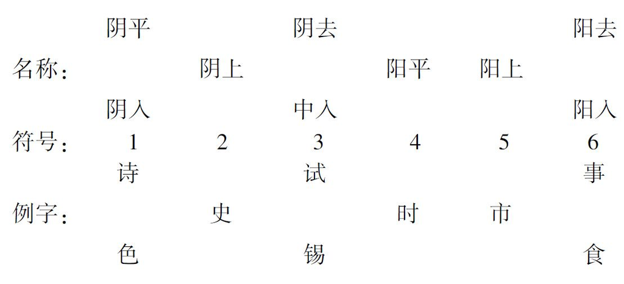

注：

声调符号标在音节的右上角，例如：

诗 xi1 史 xi2 试 xi3

说明： 本方案是根据 1960 年广东省教育行政部门公布的《广州话拼音方案》修订而成。

# ٠ 2. 粤方言特殊字表

下面是粤方言的常见特殊字（包括借用字），其中有部分在本书里使用过。所有的字均按笔画排列，每个字都注上粤方言读音和简单的意义。

## 二画

乜 med1 什么

## 四画

冇 mou5 没有

## 五画

冚 hem6 紧密

曱甴 ged6 zed6 蟑螂

叻 lég1 聪明

叹 tan3 享受

甩 led1 脱落

甩 fing6 甩动

氹 tem5 水坑

## 六画

扱 keb1 盖

吖 a1 语气词

曳 yei5 ，yei4 淘气；差次

岌 ngeb6 摇动

自 ji6 暂且

佢 kêu5 他

仮 fan2 玩耍

keb6（狗）咬

孖 ma1 双

## 七画

抌 dem2 捶打

扽 den3 震；墩

扲（撢）ngem4 掏

抠 keo1 掺和

扻 hen2 磕碰

冷 lang1 毛线

汭 yêu6 黏液

奀 ngen1 瘦小

呔 tai1 车胎

呀 a3 ，a4 语气词

吽哣 ngeo6 deo6 呆滞

yao1 咿 ，不严肃

呃（眲）ngag1 骗

估 gu2 猜

佢 kêu5 他

饩 héi3 喂（动物）

pei1 削

## 八画

波 bo1 球

炆 men1 炖；焖

neb6 湿貌；黏糊

沊 dem2 物落水声

定（） déng6 地方

定 ding6 还是

闹 nao6 骂

ged1 刺，戳

kem2 盖，遮盖

枧 gan2 肥皂

抰 yêng2 抖动

拎 ning1 拿

拘 kêu1 客气

拗 ngao3 争论

拃 za6 栅，堵

畀 béi2 给

咁 gem3 那么；这么

咗 zo2 了

ded1 放，搁

nib1 凹

咋 za3 ，za4 语气词

呢 ni1 这

log1 拔（牙、钉子）

制 zei3 愿意干

的 dig1 提起，拿起

乸 na2 母，雌性

## 九画

烂 lan2 装成某种样子

炩 ling3 光亮，锃亮

亲 cen1 助词，表示遭受

度 dou2 尺寸（用以量物的）

度 dou6 处，地方

点 dim2 怎么

衲 nab6 棉衲，棉袄

玷 dim3 碰

挜 nga6 占（地）

挦 qim4 抽取

bed1 舀

挢 giu2 拭擦

枳 zed1 塞

耷 deb1 垂下

lib1 电梯

迾 lad6 量词，列，排

lei2 瞟

歪 mé2 斜，歪斜

咪 mei5 别，不要

ngei1 恳求

哋 déi6 们（人称代词尾）

咯 lo3 ，log3 语气词，了

咩 mé1 语气词，吗

哆 dê1 一点点，少

咧 lé3 ，lé4 语气词

耽 dam1 抬（头）

虾 ha1 欺负

笃 dug1 底儿

钑 zab6 钑骨，锁边

重 zung6 还（要）

侲 sen5 艮（韧而不脆）

姣 hao4 淫荡

kiu5 缠绕

## 十画

衰 sêu1 倒霉，缺德

挛 lün1 弯曲

冧 lem1 花蕾；收拢

谂 nem2 想，思考

tem3 哄骗

挈 hid3 带挈，提携

捞 lou1 拌；获得

挭 gang3 涉水；搅动

挹 yeb1 招手

挼 no4 搓

wo5 蛋变坏

埋 mai4 靠近；助词，连…也

埕 qing4 坛子

匿 néi1 躲藏

ngung2 推

戙 dung6 竖起；量词，墩，摞

趷 ged6 翘；单脚跳

léi5 船帆

唔 m4 不

唛 meg1 商标

哽 keng2 噎（喉咙）

唞 teo2 休息

晒 sai3 助词，完全，光

倾 king1 聊，攀谈

倔 gued6 秃

舦 tai5 舵

屙 ngo1 排便

孭（） mé1 背（小孩）

屘 méi1 末尾

## 十一画

湴 ban6 烂泥

渌 lug6（热水）烫

谛 dei3 讽刺

焗 gug6 闷；焖

焫 nad3 烫

na1 疤痕

裇 sêd1 衬衣

赧 nan3 疙瘩（蚊虫所咬）

埲 bung6 量词，股，阵

掟 déng3 扔，投掷

掂 dim6 直；妥当

軚（） tai5 车舵

厣 yim2 盖子（田螺盖、鸡笼门盖）

lem3 倒塌

捵 din2 滚地，打滚

掹 meng1 拉，拔

ngao1 抓，挠

梗 geng2 当然，一定

爽 song2 量词，段，截（甘蔗）

啖 dam6 量词，口

啦 la1 ，la4 语气词

啰 lo4 ，lo3 语气词

唪 bung6 量词，堵（墙）

啲 di1 些

啡 fé4 ，fé1 象声词

啝 wo4 语气词，表不以为然

啫 zég1 语气词，表劝告

啩 gua3 语气词，表疑问

喐 yug1 动

啱 ngam1 刚好，对

喎 wo3 语气词，表陈述告知

啮 ngad6 咬；摩擦

pé1 扑克

wag1 人叫声

guai2 小青蛙

秾 yung4 浓密

第 dei6 别的

cao3 牛顶人

猄 géng1 黄猄，麂子

偈 gei6-2 话语

婄 peo3 松软，不结实

脷 léi6 舌头

脢 mui4 脢肉，里脊

## 十二画

cei4 糍粑

湓 pen4 噗，粥水外溢

煀 wed1 烟熏

靓 léng3 美

椗 ding3 柄，把儿

揞 ngem2 捂

deb6 捶打

揿 gem6 摁，压

揦 la2 抓，拿

搂 leo1 披；抱

揇 nam5 打，敲打

sang2 刷洗；责备

揾 wen2 找

搰 wed6 晃动

揸 za1 握，抓

揗 ten4 颤抖；走动

喇 la3 语气词

喼 gib1 箱子

嘅 ge3 的

ga3 ，ga4 语气词

na1 与，和

喺（） hei2 在

喽 leo3 邀约

睇 tei2 看

喫 yag3 吃

搀 cam4 刺眼，晃眼

鈪 ngag3 镯子

掣 zei3 开关

腍 nem4 软烂

餸 sung3 菜肴

## 十三画

溦 méi1 雨溦，毛毛雨

煠 sab6 煮，熬

窦 deo3 窝巢

摄 xib3 插进（缝里）

搏 bog3 拼

搉 kog1 敲

搣 mid1 捏

搦 nig1 拿，提

ngou4 摇

督 dug1 杵，捅

嗰（） go2 那（个）

long2 涮，漱（口）

蜎 hün2 黄蜎，蚯蚓

méi1 螗 ，蜻蜓

嗌 ngai3 喊

睩 lug1 瞪（眼）

罨 ngeb1 敷，捂

嗍 sog3 吸

踭 zang1（脚）跟

zam2 眨眼

煲 bou1 锅；煮

馎 bog3 馎铛，烙饼

腩 nam5 肚腩，腹部

膇 dêu3 浮肿

## 十四画

褛 leo1 大衣

褪 ten3 退

谮 cem3 谮气，唠叨

瘌 lad3 瘌痢

kin2 揭开

dad3 摔

嘈 cou4 吵闹

cêu4 气味

噉 gem2 那样；这样

嘞 lag3 语气词

踎 meo1 蹲

嘥 sai1 浪费

嘢 yé5 东西

嗻 zé1 语气词，表申辩

鍟 séng3 铁锈

鎅 gai3 锯（板）

膊 bog3 肩

蔸 deo1 滑竿

篸 cam2 簸箕

膉 yig1 哈喇味

ngog6 抬头，仰

## 十五画

jig1 疳积

蔃 gêng2 根

撩 liu4 挑逗，招惹

擒 kem4 攀爬

man1 扳

擙 ngou1 够，身手前探

hing3 烤；热

薘 dad6 芙薘，苦瓜

劏（） tong1 宰杀

噃 bo3 语气词，表提示

螆 ji1 小虫

噜 lou3 那

噒 lên1 啃

噏 ngeb1 胡说

瞓（） fen3 睡

瞌 heb1 打瞌睡

膶（） yên6-2 肝

艔 dou6 一种客船

樖 po1 棵

缬 lid3 结子

## 十六画

瀄（） jid1 溅

燂 tam4 烤

薳（） yün5 嫩尖儿

蕹 ngong3 蕹菜，空心菜

擗 pég6 扔

踸 dem6 跺

nam3 跨越

zong1 窥视

壆 bog3 堤坝

镙 lêu1 铜圆

躽 yin2 挺胸

## 十七画

燶（） nung1 焦煳

髀 béi2 大腿

bei6 糟糕

嬲 neo1 生气

簕 leg6 植物刺

lê1 吐出

pang1 铁罐

擘 mag3 掰；张开

孻（） lai1 末子，幼子

## 十八画

癐（） gui6 疲倦

bog1 敲打

擸 lab3 抓取

嚡 hai4 涩

嚟 lei4 来

蠄蟝 kem4 kêu4 蟾蜍

蠄 kem4 lou4 大蜘蛛

镬 wog6 铁锅

罉（铛） cang1 锅（钢精锅，砂锅）

## 十九画

lai2 舔

pog1 泡儿

劖 cam5 刺（动词）

zan2 美好

## 二十画以上

癦 meg6 痣

趯 dég3 逃跑

嚿（） geo6 量词，块，团

攞（） lo2 取

黐 qi1 粘黏

灒（） zan3 淬火，冷热刺激

躝（） lan1 爬

戆 ngong6 愚蠢

léng6 闪电，打闪